# Notas del Curso de Métodos Numéricos

Ortiz Cruz José Gabriel

14 octubre, 2025

# Sistemas de punto flotante

## Historia de los metodos numericos

## Conversion de base 10 a base 2

## Tipos de errores

[figure not shown]

# Sistemas de ecuaciones lineales

## Metodos directos

### Gaussiana Simple

#### Ejercicio 1

##### 1. Definir matriz y vector

```r
A <- matrix(c(
  1, -2, 0.5,
  -2, 5, -1.5,
  -0.2, 1.75, -1), nrow = 3, byrow = TRUE)

b <- c(-5, 0, 10)
```

##### 2. Crear matriz aumentada

```r
Ab <- cbind(A, b)
print(Ab)
```

```
##                       b
## [1,]  1.0 -2.00  0.5 -5
## [2,] -2.0  5.00 -1.5  0
## [3,] -0.2  1.75 -1.0 10
```

##### 3. Paso 1: Eliminar debajo del pivote [1,1]

Eliminación Gaussiana Simple - Primera columna

```r
m1 <- -Ab[2,1]/Ab[1,1]; (m1)
```

```
##
## 2
```

```r
m2 <- -Ab[3,1]/Ab[1,1]; (m2)
```

```
##
## 0.2
```

```r
A1 <- Ab[1,]; (A1)
```

```
##                   b
##  1.0 -2.0  0.5 -5.0
```

```r
A2 <- m1*Ab[1,]+Ab[2,]; (A2)
```

```
##                       b
##   0.0   1.0  -0.5 -10.0
```

```r
A3 <- m2*Ab[1,]+Ab[3,]; (A3)
```

```
##                       b
##  0.00  1.35 -0.90  9.00
```

```r
NuevaA <- rbind(A1,A2,A3); (NuevaA)
```

```
##                   b
## A1 1 -2.00  0.5  -5
## A2 0  1.00 -0.5 -10
## A3 0  1.35 -0.9   9
```

##### 4. Paso 2: Eliminar debajo del pivote [2,2]

Segunda columna

```r
Ab <- NuevaA
m3 <- -Ab[3,2]/Ab[2,2]; (m3)
```

```
## [1] -1.35
```

```r
A1 <- Ab[1,]
A2 <- Ab[2,]
A3 <- m3*Ab[2,]+Ab[3,]; (A3)
```

```
##                           b
##  0.000  0.000 -0.225 22.500
```

```r
NuevaA <- rbind(A1,A2,A3); (NuevaA)
```

```
##                    b
## A1 1 -2  0.500  -5.0
## A2 0  1 -0.500 -10.0
## A3 0  0 -0.225  22.5
```

##### 5. Paso 3: Sustitución hacia atrás

Eliminar arriba del pivote [3,3]

```r
Ab <- NuevaA
m4 <- -Ab[2,3]/Ab[3,3]; (m4)
```

```
## [1] -2.222222
```

```r
m5 <- -Ab[1,3]/Ab[3,3]; (m5)
```

```
## [1] 2.222222
```

```r
A1 <- m5*Ab[3,]+Ab[1,]; (A1)
```

```
##           b
##  1 -2  0 45
```

```r
A2 <- m4*Ab[3,]+Ab[2,]; (A2)
```

```
##               b
##   0   1   0 -60
```

```r
A3 <- Ab[3,]
NuevaA <- rbind(A1,A2,A3); (NuevaA)
```

```
##                    b
## A1 1 -2  0.000  45.0
## A2 0  1  0.000 -60.0
## A3 0  0 -0.225  22.5
```

Eliminar arriba del pivote [2,2]

```r
Ab <- NuevaA
m6 <- -Ab[1,2]/Ab[2,2]; (m6)
```

```
## [1] 2
```

```r
A1 <- m6*Ab[2,]+Ab[1,]; (A1)
```

```
##               b
##   1   0   0 -75
```

```r
A2 <- Ab[2,]
A3 <- Ab[3,]
NuevaA <- rbind(A1,A2,A3); (NuevaA)
```

```
##                   b
## A1 1 0  0.000 -75.0
## A2 0 1  0.000 -60.0
## A3 0 0 -0.225  22.5
```

##### 6. Solución del sistema

```r
x1 <- NuevaA[1,4] / NuevaA[1,1]
x2 <- NuevaA[2,4] / NuevaA[2,2]
x3 <- NuevaA[3,4] / NuevaA[3,3]

x1; x2; x3
```

```
## [1] -75
```

```
## [1] -60
```

```
## [1] -100
```

##### 7. Verificación

```r
solucion <- c(x1, x2, x3)
resultado <- A %*% solucion
print(resultado)
```

```
##               [,1]
## [1,] -5.000000e+00
## [2,]  2.842171e-14
## [3,]  1.000000e+01
```

```r
print(b)
```

```
## [1] -5  0 10
```

#### Ejercicio 2

##### 1. Definir matriz y vector

```r
A <- matrix(c(
  3, -1, 0, 6,
  4, 2, -1, -5,
  -5, 1, -3, 0,
  0, 10, -4, 7), nrow = 4, byrow = TRUE)
b <- c(2.3, 6.9, -36, -36)
```

##### 2. Crear matriz aumentada

```r
Ab <- cbind(A, b)
print(Ab)
```

```
##                      b
## [1,]  3 -1  0  6   2.3
## [2,]  4  2 -1 -5   6.9
## [3,] -5  1 -3  0 -36.0
## [4,]  0 10 -4  7 -36.0
```

##### 3. Paso 1: Eliminar debajo del pivote [1,1]

```r
m1 <- -Ab[2,1]/Ab[1,1]; (m1)
```

```
##
## -1.333333
```

```r
m2 <- -Ab[3,1]/Ab[1,1]; (m2)
```

```
##
## 1.666667
```

```r
m3 <- -Ab[4,1]/Ab[1,1]; (m3)
```

```
##
## 0
```

```r
A1 <- Ab[1,]; (A1)
```

```
##                        b
##  3.0 -1.0  0.0  6.0  2.3
```

```r
A2 <- m1*Ab[1,]+Ab[2,]; (A2)
```

```
##                                                      b
##   0.000000   3.333333  -1.000000 -13.000000   3.833333
```

```r
A3 <- m2*Ab[1,]+Ab[3,]; (A3)
```

```
##                                                           b
##   0.0000000  -0.6666667  -3.0000000  10.0000000 -32.1666667
```

```r
A4 <- m3*Ab[1,]+Ab[4,]; (A4)
```

```
##                   b
##   0  10  -4   7 -36
```

```r
NuevaA <- rbind(A1,A2,A3,A4); (NuevaA)
```

```
##                                 b
## A1 3 -1.0000000  0   6   2.300000
## A2 0  3.3333333 -1 -13   3.833333
## A3 0 -0.6666667 -3  10 -32.166667
## A4 0 10.0000000 -4   7 -36.000000
```

##### 4. Paso 2: Eliminar debajo del pivote [2,2]

```r
Ab <- NuevaA
m4 <- -Ab[3,2]/Ab[2,2]; (m4)
```

```
## [1] 0.2
```

```r
m5 <- -Ab[4,2]/Ab[2,2]; (m5)
```

```
## [1] -3
```

```r
A1 <- Ab[1,]
A2 <- Ab[2,]
A3 <- m4*Ab[2,]+Ab[3,]; (A3)
```

```
##                             b
##   0.0   0.0  -3.2   7.4 -31.4
```

```r
A4 <- m5*Ab[2,]+Ab[4,]; (A4)
```

```
##                             b
##   0.0   0.0  -1.0  46.0 -47.5
```

```r
NuevaA <- rbind(A1,A2,A3,A4); (NuevaA)
```

```
##                                    b
## A1 3 -1.000000  0.0   6.0   2.300000
## A2 0  3.333333 -1.0 -13.0   3.833333
## A3 0  0.000000 -3.2   7.4 -31.400000
## A4 0  0.000000 -1.0  46.0 -47.500000
```

##### 5. Paso 3: Eliminar debajo del pivote [3,3]

```r
Ab <- NuevaA
m6 <- -Ab[4,3]/Ab[3,3]; (m6)
```

```
## [1] -0.3125
```

```r
A1 <- Ab[1,]
A2 <- Ab[2,]
A3 <- Ab[3,]
A4 <- m6*Ab[3,]+Ab[4,]; (A4)
```

```
##                                            b
##   0.0000   0.0000   0.0000  43.6875 -37.6875
```

```r
NuevaA <- rbind(A1,A2,A3,A4); (NuevaA)
```

```
##                                       b
## A1 3 -1.000000  0.0   6.0000   2.300000
## A2 0  3.333333 -1.0 -13.0000   3.833333
## A3 0  0.000000 -3.2   7.4000 -31.400000
## A4 0  0.000000  0.0  43.6875 -37.687500
```

##### 6. Paso 4: Sustitución hacia atrás

Eliminar arriba del pivote [4,4]

```r
Ab <- NuevaA
m7 <- -Ab[1,4]/Ab[4,4]; (m7)
```

```
## [1] -0.1373391
```

```r
m8 <- -Ab[2,4]/Ab[4,4]; (m8)
```

```
## [1] 0.297568
```

```r
m9 <- -Ab[3,4]/Ab[4,4]; (m9)
```

```
## [1] -0.1693848
```

```r
A1 <- m7*Ab[4,]+Ab[1,]; (A1)
```

```
##                                                 b
##  3.000000 -1.000000  0.000000  0.000000  7.475966
```

```r
A2 <- m8*Ab[4,]+Ab[2,]; (A2)
```

```
##                                                 b
##  0.000000  3.333333 -1.000000  0.000000 -7.381259
```

```r
A3 <- m9*Ab[4,]+Ab[3,]; (A3)
```

```
##                                                 b
##   0.00000   0.00000  -3.20000   0.00000 -25.01631
```

```r
A4 <- Ab[4,]
NuevaA <- rbind(A1,A2,A3,A4); (NuevaA)
```

```
##                                      b
## A1 3 -1.000000  0.0  0.0000   7.475966
## A2 0  3.333333 -1.0  0.0000  -7.381259
## A3 0  0.000000 -3.2  0.0000 -25.016309
## A4 0  0.000000  0.0 43.6875 -37.687500
```

Eliminar arriba del pivote [3,3]

```r
Ab <- NuevaA
m10 <- -Ab[1,3]/Ab[3,3]; (m10)
```

```
## [1] 0
```

```r
m11 <- -Ab[2,3]/Ab[3,3]; (m11)
```

```
## [1] -0.3125
```

```r
A1 <- m10*Ab[3,]+Ab[1,]; (A1)
```

```
##                                                 b
##  3.000000 -1.000000  0.000000  0.000000  7.475966
```

```r
A2 <- m11*Ab[3,]+Ab[2,]; (A2)
```

```
##                                                 b
## 0.0000000 3.3333333 0.0000000 0.0000000 0.4363376
```

```r
A3 <- Ab[3,]
A4 <- Ab[4,]
NuevaA <- rbind(A1,A2,A3,A4); (NuevaA)
```

```
##                                       b
## A1 3 -1.000000  0.0  0.0000   7.4759657
## A2 0  3.333333  0.0  0.0000   0.4363376
## A3 0  0.000000 -3.2  0.0000 -25.0163090
## A4 0  0.000000  0.0 43.6875 -37.6875000
```

Eliminar arriba del pivote [2,2]

```r
Ab <- NuevaA
m12 <- -Ab[1,2]/Ab[2,2]; (m12)
```

```
## [1] 0.3
```

```r
A1 <- m12*Ab[2,]+Ab[1,]; (A1)
```

```
##                                            b
## 3.000000 0.000000 0.000000 0.000000 7.606867
```

```r
A2 <- Ab[2,]
A3 <- Ab[3,]
A4 <- Ab[4,]
NuevaA <- rbind(A1,A2,A3,A4); (NuevaA)
```

```
##                                      b
## A1 3 0.000000  0.0  0.0000   7.6068670
## A2 0 3.333333  0.0  0.0000   0.4363376
## A3 0 0.000000 -3.2  0.0000 -25.0163090
## A4 0 0.000000  0.0 43.6875 -37.6875000
```

##### 7. Solución del sistema

```r
x1 <- NuevaA[1,5] / NuevaA[1,1]
x2 <- NuevaA[2,5] / NuevaA[2,2]
x3 <- NuevaA[3,5] / NuevaA[3,3]
x4 <- NuevaA[4,5] / NuevaA[4,4]
x1; x2; x3; x4
```

```
## [1] 2.535622
```

```
## [1] 0.1309013
```

```
## [1] 7.817597
```

```
## [1] -0.8626609
```

##### 8. Verificación

```r
solucion <- c(x1, x2, x3, x4)
resultado <- A %*% solucion
print(resultado)
```

```
##       [,1]
## [1,]   2.3
## [2,]   6.9
## [3,] -36.0
## [4,] -36.0
```

```r
print(b)
```

```
## [1]   2.3   6.9 -36.0 -36.0
```

#### Ejercicio 3

##### 1. Definir matriz y vector

```r
A <- matrix(c(
  0.003000, 59.14,
  5.291, -6.130), nrow = 2, byrow = TRUE)

b <- c(59.17, 46.78)
```

##### 2. Crear matriz aumentada

```r
Ab <- cbind(A, b)
print(Ab)
```

```
##                      b
## [1,] 0.003 59.14 59.17
## [2,] 5.291 -6.13 46.78
```

##### 3. Paso 1: Eliminar debajo del pivote [1,1]

```r
m1 <- -Ab[2,1]/Ab[1,1]; (m1)
```

```
##
## -1763.667
```

```r
A1 <- Ab[1,]; (A1)
```

```
##                    b
##  0.003 59.140 59.170
```

```r
A2 <- m1*Ab[1,]+Ab[2,]; (A2)
```

```
##                             b
##       0.0 -104309.4 -104309.4
```

```r
NuevaA <- rbind(A1,A2); (NuevaA)
```

```
##                              b
## A1 0.003      59.14      59.17
## A2 0.000 -104309.38 -104309.38
```

##### 4. Paso 2: Sustitución hacia atrás

Eliminar arriba del pivote [2,2]

```r
Ab <- NuevaA
m2 <- -Ab[1,2]/Ab[2,2]; (m2)
```

```
## [1] 0.0005669672
```

```r
A1 <- m2*Ab[2,]+Ab[1,]; (A1)
```

```
##                 b
## 0.003 0.000 0.030
```

```r
A2 <- Ab[2,]
NuevaA <- rbind(A1,A2); (NuevaA)
```

```
##                             b
## A1 0.003       0.0       0.03
## A2 0.000 -104309.4 -104309.38
```

##### 6. Solución del sistema

```r
x1 <- NuevaA[1,3] / NuevaA[1,1]
x2 <- NuevaA[2,3] / NuevaA[2,2]
x1; x2
```

```
## [1] 10
```

```
## [1] 1
```

##### 7. Verificación

```r
solucion <- c(x1, x2)
resultado <- A %*% solucion
print(resultado)
```

```
##       [,1]
## [1,] 59.17
## [2,] 46.78
```

```r
print(b)
```

```
## [1] 59.17 46.78
```

#### Ejercicio 4

##### 1. Definir matriz y vector

```r
A <- matrix(c(
  4, 2, 0,
   2, 3, 1,
   0, 1, 5/2), nrow = 3, byrow = TRUE)

b <- c(2, -1, 3)
```

##### 2. Crear matriz aumentada

```r
Ab <- cbind(A, b)
print(Ab)
```

```
##               b
## [1,] 4 2 0.0  2
## [2,] 2 3 1.0 -1
## [3,] 0 1 2.5  3
```

##### 3. Paso 1: Eliminar debajo del pivote [1,1]

Eliminación Gaussiana Simple - Primera columna

```r
m1 <- -Ab[2,1]/Ab[1,1]; (m1)
```

```
##
## -0.5
```

```r
m2 <- -Ab[3,1]/Ab[1,1]; (m2)
```

```
##
## 0
```

```r
A1 <- Ab[1,]; (A1)
```

```
##       b
## 4 2 0 2
```

```r
A2 <- m1*Ab[1,]+Ab[2,]; (A2)
```

```
##           b
##  0  2  1 -2
```

```r
A3 <- m2*Ab[1,]+Ab[3,]; (A3)
```

```
##               b
## 0.0 1.0 2.5 3.0
```

```r
NuevaA <- rbind(A1,A2,A3); (NuevaA)
```

```
##             b
## A1 4 2 0.0  2
## A2 0 2 1.0 -2
## A3 0 1 2.5  3
```

##### 4. Paso 2: Eliminar debajo del pivote [2,2]

Segunda columna

```r
Ab <- NuevaA
m3 <- -Ab[3,2]/Ab[2,2]; (m3)
```

```
## [1] -0.5
```

```r
A1 <- Ab[1,]
A2 <- Ab[2,]
A3 <- m3*Ab[2,]+Ab[3,]; (A3)
```

```
##       b
## 0 0 2 4
```

```r
NuevaA <- rbind(A1,A2,A3); (NuevaA)
```

```
##           b
## A1 4 2 0  2
## A2 0 2 1 -2
## A3 0 0 2  4
```

##### 5. Paso 3: Sustitución hacia atrás

Eliminar arriba del pivote [3,3]

```r
Ab <- NuevaA
m4 <- -Ab[2,3]/Ab[3,3]; (m4)
```

```
## [1] -0.5
```

```r
m5 <- -Ab[1,3]/Ab[3,3]; (m5)
```

```
## [1] 0
```

```r
A1 <- m5*Ab[3,]+Ab[1,]; (A1)
```

```
##       b
## 4 2 0 2
```

```r
A2 <- m4*Ab[3,]+Ab[2,]; (A2)
```

```
##           b
##  0  2  0 -4
```

```r
A3 <- Ab[3,]
NuevaA <- rbind(A1,A2,A3); (NuevaA)
```

```
##           b
## A1 4 2 0  2
## A2 0 2 0 -4
## A3 0 0 2  4
```

Eliminar arriba del pivote [2,2]

```r
Ab <- NuevaA
m6 <- -Ab[1,2]/Ab[2,2]; (m6)
```

```
## [1] -1
```

```r
A1 <- m6*Ab[2,]+Ab[1,]; (A1)
```

```
##       b
## 4 0 0 6
```

```r
A2 <- Ab[2,]
A3 <- Ab[3,]
NuevaA <- rbind(A1,A2,A3); (NuevaA)
```

```
##           b
## A1 4 0 0  6
## A2 0 2 0 -4
## A3 0 0 2  4
```

##### 6. Solución del sistema

```r
x1 <- NuevaA[1,4] / NuevaA[1,1]
x2 <- NuevaA[2,4] / NuevaA[2,2]
x3 <- NuevaA[3,4] / NuevaA[3,3]

x1; x2; x3
```

```
## [1] 1.5
```

```
## [1] -2
```

```
## [1] 2
```

##### 7. Verificación

```r
solucion <- c(x1, x2, x3)
resultado <- A %*% solucion
print(resultado)
```

```
##      [,1]
## [1,]    2
## [2,]   -1
## [3,]    3
```

```r
print(b)
```

```
## [1]  2 -1  3
```

#### Ejercicio 5

##### 1. Definir matriz y vector

```r
A <- matrix(c(
  3, -0.1, -0.2,
   0.1, 7, -0.3,
   0.3, -0.2, 10), nrow = 3, byrow = TRUE)

b <- c(7.85, -19.3, 71.4)
```

##### 2. Crear matriz aumentada

```r
Ab <- cbind(A, b)
print(Ab)
```

```
##                         b
## [1,] 3.0 -0.1 -0.2   7.85
## [2,] 0.1  7.0 -0.3 -19.30
## [3,] 0.3 -0.2 10.0  71.40
```

##### 3. Paso 1: Eliminar debajo del pivote [1,1]

Eliminación Gaussiana Simple - Primera columna

```r
m1 <- -Ab[2,1]/Ab[1,1]; (m1)
```

```
##
## -0.03333333
```

```r
m2 <- -Ab[3,1]/Ab[1,1]; (m2)
```

```
##
## -0.1
```

```r
A1 <- Ab[1,]; (A1)
```

```
##                       b
##  3.00 -0.10 -0.20  7.85
```

```r
A2 <- m1*Ab[1,]+Ab[2,]; (A2)
```

```
##                                               b
##   0.0000000   7.0033333  -0.2933333 -19.5616667
```

```r
A3 <- m2*Ab[1,]+Ab[3,]; (A3)
```

```
##                           b
##  0.000 -0.190 10.020 70.615
```

```r
NuevaA <- rbind(A1,A2,A3); (NuevaA)
```

```
##                                   b
## A1 3 -0.100000 -0.2000000   7.85000
## A2 0  7.003333 -0.2933333 -19.56167
## A3 0 -0.190000 10.0200000  70.61500
```

##### 4. Paso 2: Eliminar debajo del pivote [2,2]

Segunda columna

```r
Ab <- NuevaA
m3 <- -Ab[3,2]/Ab[2,2]; (m3)
```

```
## [1] 0.02712994
```

```r
A1 <- Ab[1,]
A2 <- Ab[2,]
A3 <- m3*Ab[2,]+Ab[3,]; (A3)
```

```
##                                   b
##  0.00000  0.00000 10.01204 70.08429
```

```r
NuevaA <- rbind(A1,A2,A3); (NuevaA)
```

```
##                                   b
## A1 3 -0.100000 -0.2000000   7.85000
## A2 0  7.003333 -0.2933333 -19.56167
## A3 0  0.000000 10.0120419  70.08429
```

##### 5. Paso 3: Sustitución hacia atrás

Eliminar arriba del pivote [3,3]

```r
Ab <- NuevaA
m4 <- -Ab[2,3]/Ab[3,3]; (m4)
```

```
## [1] 0.02929805
```

```r
m5 <- -Ab[1,3]/Ab[3,3]; (m5)
```

```
## [1] 0.01997595
```

```r
A1 <- m5*Ab[3,]+Ab[1,]; (A1)
```

```
##                       b
##  3.00 -0.10  0.00  9.25
```

```r
A2 <- m4*Ab[3,]+Ab[2,]; (A2)
```

```
##                                           b
##   0.000000   7.003333   0.000000 -17.508333
```

```r
A3 <- Ab[3,]
NuevaA <- rbind(A1,A2,A3); (NuevaA)
```

```
##                                 b
## A1 3 -0.100000  0.00000   9.25000
## A2 0  7.003333  0.00000 -17.50833
## A3 0  0.000000 10.01204  70.08429
```

Eliminar arriba del pivote [2,2]

```r
Ab <- NuevaA
m6 <- -Ab[1,2]/Ab[2,2]; (m6)
```

```
## [1] 0.01427891
```

```r
A1 <- m6*Ab[2,]+Ab[1,]; (A1)
```

```
##       b
## 3 0 0 9
```

```r
A2 <- Ab[2,]
A3 <- Ab[3,]
NuevaA <- rbind(A1,A2,A3); (NuevaA)
```

```
##                                b
## A1 3 0.000000  0.00000   9.00000
## A2 0 7.003333  0.00000 -17.50833
## A3 0 0.000000 10.01204  70.08429
```

##### 6. Solución del sistema

```r
x1 <- NuevaA[1,4] / NuevaA[1,1]
x2 <- NuevaA[2,4] / NuevaA[2,2]
x3 <- NuevaA[3,4] / NuevaA[3,3]

x1; x2; x3
```

```
## [1] 3
```

```
## [1] -2.5
```

```
## [1] 7
```

##### 7. Verificación

```r
solucion <- c(x1, x2, x3)
resultado <- A %*% solucion
print(resultado)
```

```
##        [,1]
## [1,]   7.85
## [2,] -19.30
## [3,]  71.40
```

```r
print(b)
```

```
## [1]   7.85 -19.30  71.40
```

#### Ejercicio 6

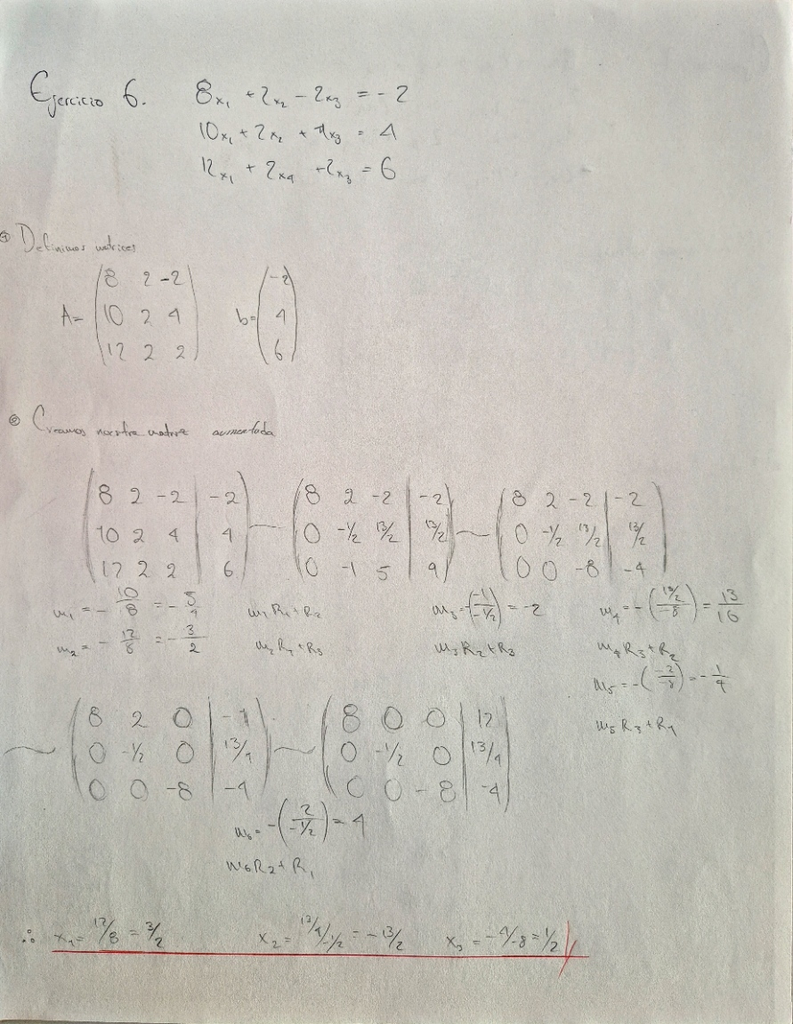

#### Ejercicio 8

##### 1. Definir matriz y vector

```r
A <- matrix(c(
  2, 3, 2, 4,
   4, 10, -4, 0,
   -3, -2, -5, -2,
   -2, 4, 4, -7), nrow = 4, byrow = TRUE)
b <- c(4, -8, -4, -1)
```

##### 2. Crear matriz aumentada

```r
Ab <- cbind(A, b)
print(Ab)
```

```
##                   b
## [1,]  2  3  2  4  4
## [2,]  4 10 -4  0 -8
## [3,] -3 -2 -5 -2 -4
## [4,] -2  4  4 -7 -1
```

##### 3. Paso 1: Eliminar debajo del pivote [1,1]

```r
m1 <- -Ab[2,1]/Ab[1,1]; (m1)
```

```
##
## -2
```

```r
m2 <- -Ab[3,1]/Ab[1,1]; (m2)
```

```
##
## 1.5
```

```r
m3 <- -Ab[4,1]/Ab[1,1]; (m3)
```

```
##
## 1
```

```r
A1 <- Ab[1,]; (A1)
```

```
##         b
## 2 3 2 4 4
```

```r
A2 <- m1*Ab[1,]+Ab[2,]; (A2)
```

```
##                   b
##   0   4  -8  -8 -16
```

```r
A3 <- m2*Ab[1,]+Ab[3,]; (A3)
```

```
##                        b
##  0.0  2.5 -2.0  4.0  2.0
```

```r
A4 <- m3*Ab[1,]+Ab[4,]; (A4)
```

```
##              b
##  0  7  6 -3  3
```

```r
NuevaA <- rbind(A1,A2,A3,A4); (NuevaA)
```

```
##                  b
## A1 2 3.0  2  4   4
## A2 0 4.0 -8 -8 -16
## A3 0 2.5 -2  4   2
## A4 0 7.0  6 -3   3
```

##### 4. Paso 2: Eliminar debajo del pivote [2,2]

```r
Ab <- NuevaA
m4 <- -Ab[3,2]/Ab[2,2]; (m4)
```

```
## [1] -0.625
```

```r
m5 <- -Ab[4,2]/Ab[2,2]; (m5)
```

```
## [1] -1.75
```

```r
A1 <- Ab[1,]
A2 <- Ab[2,]
A3 <- m4*Ab[2,]+Ab[3,]; (A3)
```

```
##              b
##  0  0  3  9 12
```

```r
A4 <- m5*Ab[2,]+Ab[4,]; (A4)
```

```
##              b
##  0  0 20 11 31
```

```r
NuevaA <- rbind(A1,A2,A3,A4); (NuevaA)
```

```
##                b
## A1 2 3  2  4   4
## A2 0 4 -8 -8 -16
## A3 0 0  3  9  12
## A4 0 0 20 11  31
```

##### 5. Paso 3: Eliminar debajo del pivote [3,3]

```r
Ab <- NuevaA
m6 <- -Ab[4,3]/Ab[3,3]; (m6)
```

```
## [1] -6.666667
```

```r
A1 <- Ab[1,]
A2 <- Ab[2,]
A3 <- Ab[3,]
A4 <- m6*Ab[3,]+Ab[4,]; (A4)
```

```
##                   b
##   0   0   0 -49 -49
```

```r
NuevaA <- rbind(A1,A2,A3,A4); (NuevaA)
```

```
##                 b
## A1 2 3  2   4   4
## A2 0 4 -8  -8 -16
## A3 0 0  3   9  12
## A4 0 0  0 -49 -49
```

##### 6. Paso 4: Sustitución hacia atrás

Eliminar arriba del pivote [4,4]

```r
Ab <- NuevaA
m7 <- -Ab[1,4]/Ab[4,4]; (m7)
```

```
## [1] 0.08163265
```

```r
m8 <- -Ab[2,4]/Ab[4,4]; (m8)
```

```
## [1] -0.1632653
```

```r
m9 <- -Ab[3,4]/Ab[4,4]; (m9)
```

```
## [1] 0.1836735
```

```r
A1 <- m7*Ab[4,]+Ab[1,]; (A1)
```

```
##                                                                b
## 2.000000e+00 3.000000e+00 2.000000e+00 4.440892e-16 4.440892e-16
```

```r
A2 <- m8*Ab[4,]+Ab[2,]; (A2)
```

```
##                                                                     b
##  0.000000e+00  4.000000e+00 -8.000000e+00 -8.881784e-16 -8.000000e+00
```

```r
A3 <- m9*Ab[4,]+Ab[3,]; (A3)
```

```
##         b
## 0 0 3 0 3
```

```r
A4 <- Ab[4,]
NuevaA <- rbind(A1,A2,A3,A4); (NuevaA)
```

```
##                                     b
## A1 2 3  2  4.440892e-16  4.440892e-16
## A2 0 4 -8 -8.881784e-16 -8.000000e+00
## A3 0 0  3  0.000000e+00  3.000000e+00
## A4 0 0  0 -4.900000e+01 -4.900000e+01
```

Eliminar arriba del pivote [3,3]

```r
Ab <- NuevaA
m10 <- -Ab[1,3]/Ab[3,3]; (m10)
```

```
## [1] -0.6666667
```

```r
m11 <- -Ab[2,3]/Ab[3,3]; (m11)
```

```
## [1] 2.666667
```

```r
A1 <- m10*Ab[3,]+Ab[1,]; (A1)
```

```
##                                                                     b
##  2.000000e+00  3.000000e+00  0.000000e+00  4.440892e-16 -2.000000e+00
```

```r
A2 <- m11*Ab[3,]+Ab[2,]; (A2)
```

```
##                                                                     b
##  0.000000e+00  4.000000e+00  0.000000e+00 -8.881784e-16  0.000000e+00
```

```r
A3 <- Ab[3,]
A4 <- Ab[4,]
NuevaA <- rbind(A1,A2,A3,A4); (NuevaA)
```

```
##                          b
## A1 2 3 0  4.440892e-16  -2
## A2 0 4 0 -8.881784e-16   0
## A3 0 0 3  0.000000e+00   3
## A4 0 0 0 -4.900000e+01 -49
```

Eliminar arriba del pivote [2,2]

```r
Ab <- NuevaA
m12 <- -Ab[1,2]/Ab[2,2]; (m12)
```

```
## [1] -0.75
```

```r
A1 <- m12*Ab[2,]+Ab[1,]; (A1)
```

```
##                                                                     b
##  2.000000e+00  0.000000e+00  0.000000e+00  1.110223e-15 -2.000000e+00
```

```r
A2 <- Ab[2,]
A3 <- Ab[3,]
A4 <- Ab[4,]
NuevaA <- rbind(A1,A2,A3,A4); (NuevaA)
```

```
##                          b
## A1 2 0 0  1.110223e-15  -2
## A2 0 4 0 -8.881784e-16   0
## A3 0 0 3  0.000000e+00   3
## A4 0 0 0 -4.900000e+01 -49
```

##### 7. Solución del sistema

```r
x1 <- NuevaA[1,5] / NuevaA[1,1]
x2 <- NuevaA[2,5] / NuevaA[2,2]
x3 <- NuevaA[3,5] / NuevaA[3,3]
x4 <- NuevaA[4,5] / NuevaA[4,4]
x1; x2; x3; x4
```

```
## [1] -1
```

```
## [1] 0
```

```
## [1] 1
```

```
## [1] 1
```

##### 8. Verificación

```r
solucion <- c(x1, x2, x3, x4)
resultado <- A %*% solucion
print(resultado)
```

```
##      [,1]
## [1,]    4
## [2,]   -8
## [3,]   -4
## [4,]   -1
```

```r
print(b)
```

```
## [1]  4 -8 -4 -1
```

#### Ejercicio 9

##### 1. Definir matriz y vector

```r
A <- matrix(c(
  1.33, 5.281, -2.454,
   24.14, -1.21, 5.281,
   -10.123, 6.387, -1), nrow = 3, byrow = TRUE)

b <- c(6.414, 113.8, 1)
```

##### 2. Crear matriz aumentada

```r
Ab <- cbind(A, b)
print(Ab)
```

```
##                                  b
## [1,]   1.330  5.281 -2.454   6.414
## [2,]  24.140 -1.210  5.281 113.800
## [3,] -10.123  6.387 -1.000   1.000
```

##### 3. Paso 1: Eliminar debajo del pivote [1,1]

Eliminación Gaussiana Simple - Primera columna

```r
m1 <- -Ab[2,1]/Ab[1,1]; (m1)
```

```
##
## -18.15038
```

```r
m2 <- -Ab[3,1]/Ab[1,1]; (m2)
```

```
##
## 7.611278
```

```r
A1 <- Ab[1,]; (A1)
```

```
##                           b
##  1.330  5.281 -2.454  6.414
```

```r
A2 <- m1*Ab[1,]+Ab[2,]; (A2)
```

```
##                                           b
##   0.000000 -97.062135  49.822023  -2.616511
```

```r
A3 <- m2*Ab[1,]+Ab[3,]; (A3)
```

```
##                                       b
##   0.00000  46.58216 -19.67808  49.81874
```

```r
NuevaA <- rbind(A1,A2,A3); (NuevaA)
```

```
##                                     b
## A1 1.33   5.28100  -2.45400  6.414000
## A2 0.00 -97.06214  49.82202 -2.616511
## A3 0.00  46.58216 -19.67808 49.818738
```

##### 4. Paso 2: Eliminar debajo del pivote [2,2]

Segunda columna

```r
Ab <- NuevaA
m3 <- -Ab[3,2]/Ab[2,2]; (m3)
```

```
## [1] 0.479921
```

```r
A1 <- Ab[1,]
A2 <- Ab[2,]
A3 <- m3*Ab[2,]+Ab[3,]; (A3)
```

```
##                                   b
##  0.00000  0.00000  4.23256 48.56302
```

```r
NuevaA <- rbind(A1,A2,A3); (NuevaA)
```

```
##                                    b
## A1 1.33   5.28100 -2.45400  6.414000
## A2 0.00 -97.06214 49.82202 -2.616511
## A3 0.00   0.00000  4.23256 48.563020
```

##### 5. Paso 3: Sustitución hacia atrás

Eliminar arriba del pivote [3,3]

```r
Ab <- NuevaA
m4 <- -Ab[2,3]/Ab[3,3]; (m4)
```

```
## [1] -11.77113
```

```r
m5 <- -Ab[1,3]/Ab[3,3]; (m5)
```

```
## [1] 0.579791
```

```r
A1 <- m5*Ab[3,]+Ab[1,]; (A1)
```

```
##                               b
##  1.3300  5.2810  0.0000 34.5704
```

```r
A2 <- m4*Ab[3,]+Ab[2,]; (A2)
```

```
##                                           b
##    0.00000  -97.06214    0.00000 -574.25825
```

```r
A3 <- Ab[3,]
NuevaA <- rbind(A1,A2,A3); (NuevaA)
```

```
##                                    b
## A1 1.33   5.28100 0.00000   34.57040
## A2 0.00 -97.06214 0.00000 -574.25825
## A3 0.00   0.00000 4.23256   48.56302
```

Eliminar arriba del pivote [2,2]

```r
Ab <- NuevaA
m6 <- -Ab[1,2]/Ab[2,2]; (m6)
```

```
## [1] 0.05440845
```

```r
A1 <- m6*Ab[2,]+Ab[1,]; (A1)
```

```
##                                   b
## 1.330000 0.000000 0.000000 3.325901
```

```r
A2 <- Ab[2,]
A3 <- Ab[3,]
NuevaA <- rbind(A1,A2,A3); (NuevaA)
```

```
##                                     b
## A1 1.33   0.00000 0.00000    3.325901
## A2 0.00 -97.06214 0.00000 -574.258255
## A3 0.00   0.00000 4.23256   48.563020
```

##### 6. Solución del sistema

```r
x1 <- NuevaA[1,4] / NuevaA[1,1]
x2 <- NuevaA[2,4] / NuevaA[2,2]
x3 <- NuevaA[3,4] / NuevaA[3,3]

x1; x2; x3
```

```
## [1] 2.500678
```

```
## [1] 5.916398
```

```
## [1] 11.47368
```

##### 7. Verificación

```r
solucion <- c(x1, x2, x3)
resultado <- A %*% solucion
print(resultado)
```

```
##         [,1]
## [1,]   6.414
## [2,] 113.800
## [3,]   1.000
```

```r
print(b)
```

```
## [1]   6.414 113.800   1.000
```

#### Ejercicio 10

##### 1. Definir matriz y vector

```r
A <- matrix(c(
  2, 3, 2, 4,
   4, 10, -4, 0,
   -3, -2, -5, -2,
   -2, 4, 4, -7), nrow = 4, byrow = TRUE)
b <- c(9, -15, 6, 2)
```

##### 2. Crear matriz aumentada

```r
Ab <- cbind(A, b)
print(Ab)
```

```
##                    b
## [1,]  2  3  2  4   9
## [2,]  4 10 -4  0 -15
## [3,] -3 -2 -5 -2   6
## [4,] -2  4  4 -7   2
```

##### 3. Paso 1: Eliminar debajo del pivote [1,1]

```r
m1 <- -Ab[2,1]/Ab[1,1]; (m1)
```

```
##
## -2
```

```r
m2 <- -Ab[3,1]/Ab[1,1]; (m2)
```

```
##
## 1.5
```

```r
m3 <- -Ab[4,1]/Ab[1,1]; (m3)
```

```
##
## 1
```

```r
A1 <- Ab[1,]; (A1)
```

```
##         b
## 2 3 2 4 9
```

```r
A2 <- m1*Ab[1,]+Ab[2,]; (A2)
```

```
##                   b
##   0   4  -8  -8 -33
```

```r
A3 <- m2*Ab[1,]+Ab[3,]; (A3)
```

```
##                        b
##  0.0  2.5 -2.0  4.0 19.5
```

```r
A4 <- m3*Ab[1,]+Ab[4,]; (A4)
```

```
##              b
##  0  7  6 -3 11
```

```r
NuevaA <- rbind(A1,A2,A3,A4); (NuevaA)
```

```
##                    b
## A1 2 3.0  2  4   9.0
## A2 0 4.0 -8 -8 -33.0
## A3 0 2.5 -2  4  19.5
## A4 0 7.0  6 -3  11.0
```

##### 4. Paso 2: Eliminar debajo del pivote [2,2]

```r
Ab <- NuevaA
m4 <- -Ab[3,2]/Ab[2,2]; (m4)
```

```
## [1] -0.625
```

```r
m5 <- -Ab[4,2]/Ab[2,2]; (m5)
```

```
## [1] -1.75
```

```r
A1 <- Ab[1,]
A2 <- Ab[2,]
A3 <- m4*Ab[2,]+Ab[3,]; (A3)
```

```
##                                  b
##  0.000  0.000  3.000  9.000 40.125
```

```r
A4 <- m5*Ab[2,]+Ab[4,]; (A4)
```

```
##                             b
##  0.00  0.00 20.00 11.00 68.75
```

```r
NuevaA <- rbind(A1,A2,A3,A4); (NuevaA)
```

```
##                    b
## A1 2 3  2  4   9.000
## A2 0 4 -8 -8 -33.000
## A3 0 0  3  9  40.125
## A4 0 0 20 11  68.750
```

##### 5. Paso 3: Eliminar debajo del pivote [3,3]

```r
Ab <- NuevaA
m6 <- -Ab[4,3]/Ab[3,3]; (m6)
```

```
## [1] -6.666667
```

```r
A1 <- Ab[1,]
A2 <- Ab[2,]
A3 <- Ab[3,]
A4 <- m6*Ab[3,]+Ab[4,]; (A4)
```

```
##                                       b
##    0.00    0.00    0.00  -49.00 -198.75
```

```r
NuevaA <- rbind(A1,A2,A3,A4); (NuevaA)
```

```
##                      b
## A1 2 3  2   4    9.000
## A2 0 4 -8  -8  -33.000
## A3 0 0  3   9   40.125
## A4 0 0  0 -49 -198.750
```

##### 6. Paso 4: Sustitución hacia atrás

Eliminar arriba del pivote [4,4]

```r
Ab <- NuevaA
m7 <- -Ab[1,4]/Ab[4,4]; (m7)
```

```
## [1] 0.08163265
```

```r
m8 <- -Ab[2,4]/Ab[4,4]; (m8)
```

```
## [1] -0.1632653
```

```r
m9 <- -Ab[3,4]/Ab[4,4]; (m9)
```

```
## [1] 0.1836735
```

```r
A1 <- m7*Ab[4,]+Ab[1,]; (A1)
```

```
##                                                                     b
##  2.000000e+00  3.000000e+00  2.000000e+00  4.440892e-16 -7.224490e+00
```

```r
A2 <- m8*Ab[4,]+Ab[2,]; (A2)
```

```
##                                                                     b
##  0.000000e+00  4.000000e+00 -8.000000e+00 -8.881784e-16 -5.510204e-01
```

```r
A3 <- m9*Ab[4,]+Ab[3,]; (A3)
```

```
##                                            b
## 0.000000 0.000000 3.000000 0.000000 3.619898
```

```r
A4 <- Ab[4,]
NuevaA <- rbind(A1,A2,A3,A4); (NuevaA)
```

```
##                                    b
## A1 2 3  2  4.440892e-16   -7.2244898
## A2 0 4 -8 -8.881784e-16   -0.5510204
## A3 0 0  3  0.000000e+00    3.6198980
## A4 0 0  0 -4.900000e+01 -198.7500000
```

Eliminar arriba del pivote [3,3]

```r
Ab <- NuevaA
m10 <- -Ab[1,3]/Ab[3,3]; (m10)
```

```
## [1] -0.6666667
```

```r
m11 <- -Ab[2,3]/Ab[3,3]; (m11)
```

```
## [1] 2.666667
```

```r
A1 <- m10*Ab[3,]+Ab[1,]; (A1)
```

```
##                                                                     b
##  2.000000e+00  3.000000e+00  0.000000e+00  4.440892e-16 -9.637755e+00
```

```r
A2 <- m11*Ab[3,]+Ab[2,]; (A2)
```

```
##                                                                     b
##  0.000000e+00  4.000000e+00  0.000000e+00 -8.881784e-16  9.102041e+00
```

```r
A3 <- Ab[3,]
A4 <- Ab[4,]
NuevaA <- rbind(A1,A2,A3,A4); (NuevaA)
```

```
##                                  b
## A1 2 3 0  4.440892e-16   -9.637755
## A2 0 4 0 -8.881784e-16    9.102041
## A3 0 0 3  0.000000e+00    3.619898
## A4 0 0 0 -4.900000e+01 -198.750000
```

Eliminar arriba del pivote [2,2]

```r
Ab <- NuevaA
m12 <- -Ab[1,2]/Ab[2,2]; (m12)
```

```
## [1] -0.75
```

```r
A1 <- m12*Ab[2,]+Ab[1,]; (A1)
```

```
##                                                                     b
##  2.000000e+00  0.000000e+00  0.000000e+00  1.110223e-15 -1.646429e+01
```

```r
A2 <- Ab[2,]
A3 <- Ab[3,]
A4 <- Ab[4,]
NuevaA <- rbind(A1,A2,A3,A4); (NuevaA)
```

```
##                                  b
## A1 2 0 0  1.110223e-15  -16.464286
## A2 0 4 0 -8.881784e-16    9.102041
## A3 0 0 3  0.000000e+00    3.619898
## A4 0 0 0 -4.900000e+01 -198.750000
```

##### 7. Solución del sistema

```r
x1 <- NuevaA[1,5] / NuevaA[1,1]
x2 <- NuevaA[2,5] / NuevaA[2,2]
x3 <- NuevaA[3,5] / NuevaA[3,3]
x4 <- NuevaA[4,5] / NuevaA[4,4]
x1; x2; x3; x4
```

```
## [1] -8.232143
```

```
## [1] 2.27551
```

```
## [1] 1.206633
```

```
## [1] 4.056122
```

##### 8. Verificación

```r
solucion <- c(x1, x2, x3, x4)
resultado <- A %*% solucion
print(resultado)
```

```
##      [,1]
## [1,]    9
## [2,]  -15
## [3,]    6
## [4,]    2
```

```r
print(b)
```

```
## [1]   9 -15   6   2
```

### Gaussiana con pivoteo parcial

#### Ejercicio 1

##### 1. Definir matriz y vector

```r
A <- matrix(c(
  0.4, -1.5, 0.75,
   -0.5, -15, 10,
   -10, -9, 2.5), nrow = 3, byrow = TRUE)
b <- c(-20, -10, 30)
```

##### 2. Crear matriz aumentada

```r
Ab <- cbind(A, b); (Ab)
```

```
##                          b
## [1,]   0.4  -1.5  0.75 -20
## [2,]  -0.5 -15.0 10.00 -10
## [3,] -10.0  -9.0  2.50  30
```

##### 3. PIVOTEO 1: Buscar el mayor absoluto en columna 1

```r
columna1 <- abs(Ab[,1]); (columna1)
```

```
## [1]  0.4  0.5 10.0
```

```r
fila_max <- which.max(columna1); (fila_max)
```

```
## [1] 3
```

```r
R1 <- Ab[fila_max,]; (R1)
```

```
##                       b
## -10.0  -9.0   2.5  30.0
```

```r
R2 <- Ab[2,]
R3 <- Ab[3,]
if(fila_max != 1) {
  if(fila_max == 2) R2 <- Ab[1,]
  if(fila_max == 3) R3 <- Ab[1,]
}
Ab <- rbind(R1,R2,R3); (Ab)
```

```
##                        b
## R1 -10.0  -9.0  2.50  30
## R2  -0.5 -15.0 10.00 -10
## R3   0.4  -1.5  0.75 -20
```

##### 4. Paso 1: Eliminar debajo del pivote [1,1]

```r
m1 <- -Ab[2,1]/Ab[1,1]; (m1)
```

```
## [1] -0.05
```

```r
m2 <- -Ab[3,1]/Ab[1,1]; (m2)
```

```
## [1] 0.04
```

```r
R1 <- Ab[1,]
R2 <- m1*Ab[1,]+Ab[2,]; (R2)
```

```
##                               b
##   0.000 -14.550   9.875 -11.500
```

```r
R3 <- m2*Ab[1,]+Ab[3,]; (R3)
```

```
##                           b
##   0.00  -1.86   0.85 -18.80
```

```r
NuevaA <- rbind(R1,R2,R3); (NuevaA)
```

```
##                         b
## R1 -10  -9.00 2.500  30.0
## R2   0 -14.55 9.875 -11.5
## R3   0  -1.86 0.850 -18.8
```

##### 5. PIVOTEO 2: Buscar el mayor absoluto en columna 2 (filas 2-3)

```r
Ab <- NuevaA
columna2 <- abs(Ab[2:3,2]); (columna2)
```

```
##    R2    R3
## 14.55  1.86
```

```r
fila_max <- which.max(columna2) + 1; (fila_max)
```

```
## R2
##  2
```

```r
R1 <- Ab[1,]
if(fila_max == 3) {
  R2 <- Ab[3,]; (R2)
  R3 <- Ab[2,]
} else {
  R2 <- Ab[2,]
  R3 <- Ab[3,]
}
Ab <- rbind(R1,R2,R3); (Ab)
```

```
##                         b
## R1 -10  -9.00 2.500  30.0
## R2   0 -14.55 9.875 -11.5
## R3   0  -1.86 0.850 -18.8
```

##### 6. Paso 2: Eliminar debajo del pivote [2,2]

```r
m3 <- -Ab[3,2]/Ab[2,2]; (m3)
```

```
## [1] -0.1278351
```

```r
R1 <- Ab[1,]
R2 <- Ab[2,]
R3 <- m3*Ab[2,]+Ab[3,]; (R3)
```

```
##                                               b
##   0.0000000   0.0000000  -0.4123711 -17.3298969
```

```r
NuevaA <- rbind(R1,R2,R3); (NuevaA)
```

```
##                                 b
## R1 -10  -9.00  2.5000000  30.0000
## R2   0 -14.55  9.8750000 -11.5000
## R3   0   0.00 -0.4123711 -17.3299
```

##### 7. Paso 3: Sustitución hacia atrás

Eliminar arriba del pivote [3,3]

```r
Ab <- NuevaA
m4 <- -Ab[2,3]/Ab[3,3]; (m4)
```

```
## [1] 23.94688
```

```r
m5 <- -Ab[1,3]/Ab[3,3]; (m5)
```

```
## [1] 6.0625
```

```r
R1 <- m5*Ab[3,]+Ab[1,]; (R1)
```

```
##                                   b
## -10.0000  -9.0000   0.0000 -75.0625
```

```r
R2 <- m4*Ab[3,]+Ab[2,]; (R2)
```

```
##                                       b
##    0.0000  -14.5500    0.0000 -426.4969
```

```r
R3 <- Ab[3,]
NuevaA <- rbind(R1,R2,R3); (NuevaA)
```

```
##                                  b
## R1 -10  -9.00  0.0000000  -75.0625
## R2   0 -14.55  0.0000000 -426.4969
## R3   0   0.00 -0.4123711  -17.3299
```

Eliminar arriba del pivote [2,2]

```r
Ab <- NuevaA
m6 <- -Ab[1,2]/Ab[2,2]; (m6)
```

```
## [1] -0.6185567
```

```r
R1 <- m6*Ab[2,]+Ab[1,]; (R1)
```

```
##                           b
## -10.00   0.00   0.00 188.75
```

```r
R2 <- Ab[2,]
R3 <- Ab[3,]
NuevaA <- rbind(R1,R2,R3); (NuevaA)
```

```
##                                  b
## R1 -10   0.00  0.0000000  188.7500
## R2   0 -14.55  0.0000000 -426.4969
## R3   0   0.00 -0.4123711  -17.3299
```

##### 8. Solución del sistema

```r
x1 <- NuevaA[1,4] / NuevaA[1,1]
x2 <- NuevaA[2,4] / NuevaA[2,2]
x3 <- NuevaA[3,4] / NuevaA[3,3]
x1; x2; x3
```

```
## [1] -18.875
```

```
## [1] 29.3125
```

```
## [1] 42.025
```

##### 9. Verificación

```r
solucion <- c(x1, x2, x3)
resultado <- A %*% solucion
print(resultado)
```

```
##      [,1]
## [1,]  -20
## [2,]  -10
## [3,]   30
```

```r
print(b)
```

```
## [1] -20 -10  30
```

#### Ejercicio 3

##### 1. Definir matriz y vector

```r
A <- matrix(c(
  0.003000, 59.14,
   5.291, -6.1301), nrow = 2, byrow = TRUE)
b <- c(59.17, 46.78)
```

##### 2. Crear matriz aumentada

```r
Ab <- cbind(A, b); (Ab)
```

```
##                        b
## [1,] 0.003 59.1400 59.17
## [2,] 5.291 -6.1301 46.78
```

##### 3. PIVOTEO 1: Buscar el mayor absoluto en columna 1

```r
columna1 <- abs(Ab[,1]); (columna1)
```

```
## [1] 0.003 5.291
```

```r
fila_max <- which.max(columna1); (fila_max)
```

```
## [1] 2
```

```r
R1 <- Ab[fila_max,]; (R1)
```

```
##                       b
##  5.2910 -6.1301 46.7800
```

```r
R2 <- Ab[2,]
if(fila_max == 2) {
  R2 <- Ab[1,]
}
Ab <- rbind(R1,R2); (Ab)
```

```
##                      b
## R1 5.291 -6.1301 46.78
## R2 0.003 59.1400 59.17
```

##### 4. Paso 1: Eliminar debajo del pivote [1,1]

```r
m1 <- -Ab[2,1]/Ab[1,1]; (m1)
```

```
## [1] -0.0005670006
```

```r
R1 <- Ab[1,]
R2 <- m1*Ab[1,]+Ab[2,]; (R2)
```

```
##                          b
##  0.00000 59.14348 59.14348
```

```r
NuevaA <- rbind(R1,R2); (NuevaA)
```

```
##                          b
## R1 5.291 -6.13010 46.78000
## R2 0.000 59.14348 59.14348
```

##### 5. Paso 2: Sustitución hacia atrás

Eliminar arriba del pivote [2,2]

```r
Ab <- NuevaA
m2 <- -Ab[1,2]/Ab[2,2]; (m2)
```

```
## [1] 0.1036479
```

```r
R1 <- m2*Ab[2,]+Ab[1,]; (R1)
```

```
##                       b
##  5.2910  0.0000 52.9101
```

```r
R2 <- Ab[2,]
NuevaA <- rbind(R1,R2); (NuevaA)
```

```
##                          b
## R1 5.291  0.00000 52.91010
## R2 0.000 59.14348 59.14348
```

##### 6. Solución del sistema

```r
x1 <- NuevaA[1,3] / NuevaA[1,1]
x2 <- NuevaA[2,3] / NuevaA[2,2]
x1; x2
```

```
## [1] 10.00002
```

```
## [1] 1
```

##### 7. Verificación

```r
solucion <- c(x1, x2)
resultado <- A %*% solucion
print(resultado)
```

```
##       [,1]
## [1,] 59.17
## [2,] 46.78
```

```r
print(b)
```

```
## [1] 59.17 46.78
```

#### Ejercicio 5

##### 1. Definir matriz y vector

```r
A <- matrix(c(
  0.00031000, 1.000000,
   1.00045534, 1.00034333), nrow = 2, byrow = TRUE)
b <- c(3.000000, 7.000)
```

##### 2. Crear matriz aumentada

```r
Ab <- cbind(A, b); (Ab)
```

```
##                        b
## [1,] 0.000310 1.000000 3
## [2,] 1.000455 1.000343 7
```

##### 3. PIVOTEO 1: Buscar el mayor absoluto en columna 1

```r
columna1 <- abs(Ab[,1]); (columna1)
```

```
## [1] 0.000310 1.000455
```

```r
fila_max <- which.max(columna1); (fila_max)
```

```
## [1] 2
```

```r
R1 <- Ab[fila_max,]; (R1)
```

```
##                          b
## 1.000455 1.000343 7.000000
```

```r
R2 <- Ab[2,]
if(fila_max == 2) {
  R2 <- Ab[1,]
}
Ab <- rbind(R1,R2); (Ab)
```

```
##                      b
## R1 1.000455 1.000343 7
## R2 0.000310 1.000000 3
```

##### 4. Paso 1: Eliminar debajo del pivote [1,1]

```r
m1 <- -Ab[2,1]/Ab[1,1]; (m1)
```

```
## [1] -0.0003098589
```

```r
R1 <- Ab[1,]
R2 <- m1*Ab[1,]+Ab[2,]; (R2)
```

```
##                          b
## 0.000000 0.999690 2.997831
```

```r
NuevaA <- rbind(R1,R2); (NuevaA)
```

```
##                             b
## R1 1.000455 1.000343 7.000000
## R2 0.000000 0.999690 2.997831
```

##### 5. Paso 2: Sustitución hacia atrás

Eliminar arriba del pivote [2,2]

```r
Ab <- NuevaA
m2 <- -Ab[1,2]/Ab[2,2]; (m2)
```

```
## [1] -1.000653
```

```r
R1 <- m2*Ab[2,]+Ab[1,]; (R1)
```

```
##                          b
## 1.000455 0.000000 4.000210
```

```r
R2 <- Ab[2,]
NuevaA <- rbind(R1,R2); (NuevaA)
```

```
##                            b
## R1 1.000455 0.00000 4.000210
## R2 0.000000 0.99969 2.997831
```

##### 6. Solución del sistema

```r
x1 <- NuevaA[1,3] / NuevaA[1,1]
x2 <- NuevaA[2,3] / NuevaA[2,2]
x1; x2
```

```
## [1] 3.998389
```

```
## [1] 2.99876
```

##### 7. Verificación

```r
solucion <- c(x1, x2)
resultado <- A %*% solucion
print(resultado)
```

```
##      [,1]
## [1,]    3
## [2,]    7
```

```r
print(b)
```

```
## [1] 3 7
```

#### Ejercicio 6

##### 1. Definir matriz y vector

```r
A <- matrix(c(
  14, 14, -9, 3, -5,
   14, 52, -15, 2, -32,
   -9, -15, 36, -5, 16,
   3, 2, -5, 47, 49,
   -5, 32, 16, 49, 79), nrow = 5, byrow = TRUE)
b <- c(-15, -100, 106, 329, 463)
```

##### 2. Crear matriz aumentada

```r
Ab <- cbind(A, b); (Ab)
```

```
##                           b
## [1,] 14  14  -9  3  -5  -15
## [2,] 14  52 -15  2 -32 -100
## [3,] -9 -15  36 -5  16  106
## [4,]  3   2  -5 47  49  329
## [5,] -5  32  16 49  79  463
```

##### 3. PIVOTEO 1: Buscar el mayor absoluto en columna 1

```r
columna1 <- abs(Ab[,1]); (columna1)
```

```
## [1] 14 14  9  3  5
```

```r
fila_max <- which.max(columna1); (fila_max)
```

```
## [1] 1
```

```r
R1 <- Ab[fila_max,]; (R1)
```

```
##                       b
##  14  14  -9   3  -5 -15
```

```r
R2 <- Ab[2,]
R3 <- Ab[3,]
R4 <- Ab[4,]
R5 <- Ab[5,]
if(fila_max != 1) {
  if(fila_max == 2) R2 <- Ab[1,]
  if(fila_max == 3) R3 <- Ab[1,]
  if(fila_max == 4) R4 <- Ab[1,]
  if(fila_max == 5) R5 <- Ab[1,]
}
Ab <- rbind(R1,R2,R3,R4,R5); (Ab)
```

```
##                         b
## R1 14  14  -9  3  -5  -15
## R2 14  52 -15  2 -32 -100
## R3 -9 -15  36 -5  16  106
## R4  3   2  -5 47  49  329
## R5 -5  32  16 49  79  463
```

##### 4. Paso 1: Eliminar debajo del pivote [1,1]

```r
m1 <- -Ab[2,1]/Ab[1,1]; (m1)
```

```
## [1] -1
```

```r
m2 <- -Ab[3,1]/Ab[1,1]; (m2)
```

```
## [1] 0.6428571
```

```r
m3 <- -Ab[4,1]/Ab[1,1]; (m3)
```

```
## [1] -0.2142857
```

```r
m4 <- -Ab[5,1]/Ab[1,1]; (m4)
```

```
## [1] 0.3571429
```

```r
R1 <- Ab[1,]
R2 <- m1*Ab[1,]+Ab[2,]; (R2)
```

```
##                       b
##   0  38  -6  -1 -27 -85
```

```r
R3 <- m2*Ab[1,]+Ab[3,]; (R3)
```

```
##                                                           b
##  0.000000 -6.000000 30.214286 -3.071429 12.785714 96.357143
```

```r
R4 <- m3*Ab[1,]+Ab[4,]; (R4)
```

```
##                                                                 b
##   0.000000  -1.000000  -3.071429  46.357143  50.071429 332.214286
```

```r
R5 <- m4*Ab[1,]+Ab[5,]; (R5)
```

```
##                                                           b
##   0.00000  37.00000  12.78571  50.07143  77.21429 457.64286
```

```r
NuevaA <- rbind(R1,R2,R3,R4,R5); (NuevaA)
```

```
##                                                b
## R1 14 14 -9.000000  3.000000  -5.00000 -15.00000
## R2  0 38 -6.000000 -1.000000 -27.00000 -85.00000
## R3  0 -6 30.214286 -3.071429  12.78571  96.35714
## R4  0 -1 -3.071429 46.357143  50.07143 332.21429
## R5  0 37 12.785714 50.071429  77.21429 457.64286
```

##### 5. PIVOTEO 2: Buscar el mayor absoluto en columna 2 (filas 2-5)

```r
Ab <- NuevaA
columna2 <- abs(Ab[2:5,2]); (columna2)
```

```
## R2 R3 R4 R5
## 38  6  1 37
```

```r
fila_max <- which.max(columna2) + 1; (fila_max)
```

```
## R2
##  2
```

```r
R1 <- Ab[1,]
R2_temp <- Ab[fila_max,]; (R2_temp)
```

```
##                       b
##   0  38  -6  -1 -27 -85
```

```r
R3_temp <- Ab[3,]
R4_temp <- Ab[4,]
R5_temp <- Ab[5,]
if(fila_max == 3) {
  R3_temp <- Ab[2,]
} else if(fila_max == 4) {
  R4_temp <- Ab[2,]
} else if(fila_max == 5) {
  R5_temp <- Ab[2,]
}
Ab <- rbind(R1, R2_temp, R3_temp, R4_temp, R5_temp); (Ab)
```

```
##                                                     b
## R1      14 14 -9.000000  3.000000  -5.00000 -15.00000
## R2_temp  0 38 -6.000000 -1.000000 -27.00000 -85.00000
## R3_temp  0 -6 30.214286 -3.071429  12.78571  96.35714
## R4_temp  0 -1 -3.071429 46.357143  50.07143 332.21429
## R5_temp  0 37 12.785714 50.071429  77.21429 457.64286
```

##### 6. Paso 2: Eliminar debajo del pivote [2,2]

```r
m5 <- -Ab[3,2]/Ab[2,2]; (m5)
```

```
## [1] 0.1578947
```

```r
m6 <- -Ab[4,2]/Ab[2,2]; (m6)
```

```
## [1] 0.02631579
```

```r
m7 <- -Ab[5,2]/Ab[2,2]; (m7)
```

```
## [1] -0.9736842
```

```r
R1 <- Ab[1,]
R2 <- Ab[2,]
R3 <- m5*Ab[2,]+Ab[3,]; (R3)
```

```
##                                                           b
##  0.000000  0.000000 29.266917 -3.229323  8.522556 82.936090
```

```r
R4 <- m6*Ab[2,]+Ab[4,]; (R4)
```

```
##                                                                 b
##   0.000000   0.000000  -3.229323  46.330827  49.360902 329.977444
```

```r
R5 <- m7*Ab[2,]+Ab[5,]; (R5)
```

```
##                                                           b
##   0.00000   0.00000  18.62782  51.04511 103.50376 540.40602
```

```r
NuevaA <- rbind(R1,R2,R3,R4,R5); (NuevaA)
```

```
##                                                 b
## R1 14 14 -9.000000  3.000000  -5.000000 -15.00000
## R2  0 38 -6.000000 -1.000000 -27.000000 -85.00000
## R3  0  0 29.266917 -3.229323   8.522556  82.93609
## R4  0  0 -3.229323 46.330827  49.360902 329.97744
## R5  0  0 18.627820 51.045113 103.503759 540.40602
```

##### 7. PIVOTEO 3: Buscar el mayor absoluto en columna 3 (filas 3-5)

```r
Ab <- NuevaA
columna3 <- abs(Ab[3:5,3]); (columna3)
```

```
##        R3        R4        R5
## 29.266917  3.229323 18.627820
```

```r
fila_max <- which.max(columna3) + 2; (fila_max)
```

```
## R3
##  3
```

```r
R1 <- Ab[1,]
R2 <- Ab[2,]
R3_temp <- Ab[fila_max,]; (R3_temp)
```

```
##                                                           b
##  0.000000  0.000000 29.266917 -3.229323  8.522556 82.936090
```

```r
R4_temp <- Ab[4,]
R5_temp <- Ab[5,]
if(fila_max == 4) {
  R4_temp <- Ab[3,]
} else if(fila_max == 5) {
  R5_temp <- Ab[3,]
}
Ab <- rbind(R1,R2,R3_temp,R4_temp,R5_temp); (Ab)
```

```
##                                                      b
## R1      14 14 -9.000000  3.000000  -5.000000 -15.00000
## R2       0 38 -6.000000 -1.000000 -27.000000 -85.00000
## R3_temp  0  0 29.266917 -3.229323   8.522556  82.93609
## R4_temp  0  0 -3.229323 46.330827  49.360902 329.97744
## R5_temp  0  0 18.627820 51.045113 103.503759 540.40602
```

##### 8. Paso 3: Eliminar debajo del pivote [3,3]

```r
m8 <- -Ab[4,3]/Ab[3,3]; (m8)
```

```
## [1] 0.1103404
```

```r
m9 <- -Ab[5,3]/Ab[3,3]; (m9)
```

```
## [1] -0.6364804
```

```r
R1 <- Ab[1,]
R2 <- Ab[2,]
R3 <- Ab[3,]
R4 <- m8*Ab[3,]+Ab[4,]; (R4)
```

```
##                                                           b
##   0.00000   0.00000   0.00000  45.97450  50.30128 339.12864
```

```r
R5 <- m9*Ab[3,]+Ab[5,]; (R5)
```

```
##                                                           b
##   0.00000   0.00000   0.00000  53.10051  98.07932 487.61882
```

```r
NuevaA <- rbind(R1,R2,R3,R4,R5); (NuevaA)
```

```
##                                                b
## R1 14 14 -9.00000  3.000000  -5.000000 -15.00000
## R2  0 38 -6.00000 -1.000000 -27.000000 -85.00000
## R3  0  0 29.26692 -3.229323   8.522556  82.93609
## R4  0  0  0.00000 45.974502  50.301285 339.12864
## R5  0  0  0.00000 53.100514  98.079319 487.61882
```

##### 9. PIVOTEO 4: Buscar el mayor absoluto en columna 4 (filas 4-5)

```r
Ab <- NuevaA
columna4 <- abs(Ab[4:5,4]); (columna4)
```

```
##       R4       R5
## 45.97450 53.10051
```

```r
fila_max <- which.max(columna4) + 3; (fila_max)
```

```
## R5
##  5
```

```r
R1 <- Ab[1,]
R2 <- Ab[2,]
R3 <- Ab[3,]
if(fila_max == 5) {
  R4 <- Ab[5,]; (R4)
  R5 <- Ab[4,]
} else {
  R4 <- Ab[4,]
  R5 <- Ab[5,]
}
Ab <- rbind(R1,R2,R3,R4,R5); (Ab)
```

```
##                                                b
## R1 14 14 -9.00000  3.000000  -5.000000 -15.00000
## R2  0 38 -6.00000 -1.000000 -27.000000 -85.00000
## R3  0  0 29.26692 -3.229323   8.522556  82.93609
## R4  0  0  0.00000 53.100514  98.079319 487.61882
## R5  0  0  0.00000 45.974502  50.301285 339.12864
```

##### 10. Paso 4: Eliminar debajo del pivote [4,4]

```r
m10 <- -Ab[5,4]/Ab[4,4]; (m10)
```

```
## [1] -0.8658015
```

```r
R1 <- Ab[1,]
R2 <- Ab[2,]
R3 <- Ab[3,]
R4 <- Ab[4,]
R5 <- m10*Ab[4,]+Ab[5,]; (R5)
```

```
##                                                           b
##   0.00000   0.00000   0.00000   0.00000 -34.61593 -83.05244
```

```r
NuevaA <- rbind(R1,R2,R3,R4,R5); (NuevaA)
```

```
##                                                b
## R1 14 14 -9.00000  3.000000  -5.000000 -15.00000
## R2  0 38 -6.00000 -1.000000 -27.000000 -85.00000
## R3  0  0 29.26692 -3.229323   8.522556  82.93609
## R4  0  0  0.00000 53.100514  98.079319 487.61882
## R5  0  0  0.00000  0.000000 -34.615933 -83.05244
```

##### 11. Paso 5: Sustitución hacia atrás

Eliminar arriba del pivote [5,5]

```r
Ab <- NuevaA
m11 <- -Ab[4,5]/Ab[5,5]; (m11)
```

```
## [1] 2.833358
```

```r
m12 <- -Ab[3,5]/Ab[5,5]; (m12)
```

```
## [1] 0.2462033
```

```r
m13 <- -Ab[2,5]/Ab[5,5]; (m13)
```

```
## [1] -0.7799876
```

```r
m14 <- -Ab[1,5]/Ab[5,5]; (m14)
```

```
## [1] -0.1444422
```

```r
R1 <- m14*Ab[5,]+Ab[1,]; (R1)
```

```
##                                                           b
## 14.000000 14.000000 -9.000000  3.000000  0.000000 -3.003727
```

```r
R2 <- m13*Ab[5,]+Ab[2,]; (R2)
```

```
##                                                           b
##   0.00000  38.00000  -6.00000  -1.00000   0.00000 -20.22012
```

```r
R3 <- m12*Ab[5,]+Ab[3,]; (R3)
```

```
##                                                           b
##  0.000000  0.000000 29.266917 -3.229323  0.000000 62.488307
```

```r
R4 <- m11*Ab[5,]+Ab[4,]; (R4)
```

```
##                                                           b
##   0.00000   0.00000   0.00000  53.10051   0.00000 252.30155
```

```r
R5 <- Ab[5,]
NuevaA <- rbind(R1,R2,R3,R4,R5); (NuevaA)
```

```
##                                                b
## R1 14 14 -9.00000  3.000000   0.00000  -3.003727
## R2  0 38 -6.00000 -1.000000   0.00000 -20.220124
## R3  0  0 29.26692 -3.229323   0.00000  62.488307
## R4  0  0  0.00000 53.100514   0.00000 252.301554
## R5  0  0  0.00000  0.000000 -34.61593 -83.052439
```

Eliminar arriba del pivote [4,4]

```r
Ab <- NuevaA
m15 <- -Ab[3,4]/Ab[4,4]; (m15)
```

```
## [1] 0.06081529
```

```r
m16 <- -Ab[2,4]/Ab[4,4]; (m16)
```

```
## [1] 0.01883221
```

```r
m17 <- -Ab[1,4]/Ab[4,4]; (m17)
```

```
## [1] -0.05649663
```

```r
R1 <- m17*Ab[4,]+Ab[1,]; (R1)
```

```
##                                                           b
##  14.00000  14.00000  -9.00000   0.00000   0.00000 -17.25791
```

```r
R2 <- m16*Ab[4,]+Ab[2,]; (R2)
```

```
##                                                           b
##   0.00000  38.00000  -6.00000   0.00000   0.00000 -15.46873
```

```r
R3 <- m15*Ab[4,]+Ab[3,]; (R3)
```

```
##                                                     b
##  0.00000  0.00000 29.26692  0.00000  0.00000 77.83210
```

```r
R4 <- Ab[4,]
R5 <- Ab[5,]
NuevaA <- rbind(R1,R2,R3,R4,R5); (NuevaA)
```

```
##                                              b
## R1 14 14 -9.00000  0.00000   0.00000 -17.25791
## R2  0 38 -6.00000  0.00000   0.00000 -15.46873
## R3  0  0 29.26692  0.00000   0.00000  77.83210
## R4  0  0  0.00000 53.10051   0.00000 252.30155
## R5  0  0  0.00000  0.00000 -34.61593 -83.05244
```

Eliminar arriba del pivote [3,3]

```r
Ab <- NuevaA
m18 <- -Ab[2,3]/Ab[3,3]; (m18)
```

```
## [1] 0.2050096
```

```r
m19 <- -Ab[1,3]/Ab[3,3]; (m19)
```

```
## [1] 0.3075145
```

```r
R1 <- m19*Ab[3,]+Ab[1,]; (R1)
```

```
##                                                           b
## 14.000000 14.000000  0.000000  0.000000  0.000000  6.676582
```

```r
R2 <- m18*Ab[3,]+Ab[2,]; (R2)
```

```
##                                                           b
##  0.000000 38.000000  0.000000  0.000000  0.000000  0.487602
```

```r
R3 <- Ab[3,]
R4 <- Ab[4,]
R5 <- Ab[5,]
NuevaA <- rbind(R1,R2,R3,R4,R5); (NuevaA)
```

```
##                                               b
## R1 14 14  0.00000  0.00000   0.00000   6.676582
## R2  0 38  0.00000  0.00000   0.00000   0.487602
## R3  0  0 29.26692  0.00000   0.00000  77.832100
## R4  0  0  0.00000 53.10051   0.00000 252.301554
## R5  0  0  0.00000  0.00000 -34.61593 -83.052439
```

Eliminar arriba del pivote [2,2]

```r
Ab <- NuevaA
m20 <- -Ab[1,2]/Ab[2,2]; (m20)
```

```
## [1] -0.3684211
```

```r
R1 <- m20*Ab[2,]+Ab[1,]; (R1)
```

```
##                                                           b
## 14.000000  0.000000  0.000000  0.000000  0.000000  6.496939
```

```r
R2 <- Ab[2,]
R3 <- Ab[3,]
R4 <- Ab[4,]
R5 <- Ab[5,]
NuevaA <- rbind(R1,R2,R3,R4,R5); (NuevaA)
```

```
##                                               b
## R1 14  0  0.00000  0.00000   0.00000   6.496939
## R2  0 38  0.00000  0.00000   0.00000   0.487602
## R3  0  0 29.26692  0.00000   0.00000  77.832100
## R4  0  0  0.00000 53.10051   0.00000 252.301554
## R5  0  0  0.00000  0.00000 -34.61593 -83.052439
```

##### 12. Solución del sistema

```r
x1 <- NuevaA[1,6] / NuevaA[1,1]
x2 <- NuevaA[2,6] / NuevaA[2,2]
x3 <- NuevaA[3,6] / NuevaA[3,3]
x4 <- NuevaA[4,6] / NuevaA[4,4]
x5 <- NuevaA[5,6] / NuevaA[5,5]
x1; x2; x3; x4; x5
```

```
## [1] 0.4640671
```

```
## [1] 0.01283163
```

```
## [1] 2.659388
```

```
## [1] 4.751396
```

```
## [1] 2.399255
```

##### 13. Verificación

```r
solucion <- c(x1, x2, x3, x4, x5)
resultado <- A %*% solucion
print(resultado)
```

```
##      [,1]
## [1,]  -15
## [2,] -100
## [3,]  106
## [4,]  329
## [5,]  463
```

```r
print(b)
```

```
## [1]  -15 -100  106  329  463
```

#### Ejercicio 7

##### 1. Definir matriz y vector

```r
A <- matrix(c(
  1/4, 1/5, 1/6,
   1/3, 1/4, 1/5,
   1/2, 1, 2), nrow = 3, byrow = TRUE)
b <- c(9, 8, 8)
```

##### 2. Crear matriz aumentada

```r
Ab <- cbind(A, b); (Ab)
```

```
##                               b
## [1,] 0.2500000 0.20 0.1666667 9
## [2,] 0.3333333 0.25 0.2000000 8
## [3,] 0.5000000 1.00 2.0000000 8
```

##### 3. PIVOTEO 1: Buscar el mayor absoluto en columna 1

```r
columna1 <- abs(Ab[,1]); (columna1)
```

```
## [1] 0.2500000 0.3333333 0.5000000
```

```r
fila_max <- which.max(columna1); (fila_max)
```

```
## [1] 3
```

```r
R1 <- Ab[fila_max,]; (R1)
```

```
##               b
## 0.5 1.0 2.0 8.0
```

```r
R2 <- Ab[2,]
R3 <- Ab[3,]
if(fila_max != 1) {
  if(fila_max == 2) R2 <- Ab[1,]
  if(fila_max == 3) R3 <- Ab[1,]
}
Ab <- rbind(R1,R2,R3); (Ab)
```

```
##                             b
## R1 0.5000000 1.00 2.0000000 8
## R2 0.3333333 0.25 0.2000000 8
## R3 0.2500000 0.20 0.1666667 9
```

##### 4. Paso 1: Eliminar debajo del pivote [1,1]

```r
m1 <- -Ab[2,1]/Ab[1,1]; (m1)
```

```
## [1] -0.6666667
```

```r
m2 <- -Ab[3,1]/Ab[1,1]; (m2)
```

```
## [1] -0.5
```

```r
R1 <- Ab[1,]
R2 <- m1*Ab[1,]+Ab[2,]; (R2)
```

```
##                                           b
##  0.0000000 -0.4166667 -1.1333333  2.6666667
```

```r
R3 <- m2*Ab[1,]+Ab[3,]; (R3)
```

```
##                                           b
##  0.0000000 -0.3000000 -0.8333333  5.0000000
```

```r
NuevaA <- rbind(R1,R2,R3); (NuevaA)
```

```
##                                     b
## R1 0.5  1.0000000  2.0000000 8.000000
## R2 0.0 -0.4166667 -1.1333333 2.666667
## R3 0.0 -0.3000000 -0.8333333 5.000000
```

##### 5. PIVOTEO 2: Buscar el mayor absoluto en columna 2 (filas 2-3)

```r
Ab <- NuevaA
columna2 <- abs(Ab[2:3,2]); (columna2)
```

```
##        R2        R3
## 0.4166667 0.3000000
```

```r
fila_max <- which.max(columna2) + 1; (fila_max)
```

```
## R2
##  2
```

```r
R1 <- Ab[1,]
if(fila_max == 3) {
  R2 <- Ab[3,]; (R2)
  R3 <- Ab[2,]
} else {
  R2 <- Ab[2,]
  R3 <- Ab[3,]
}
Ab <- rbind(R1,R2,R3); (Ab)
```

```
##                                     b
## R1 0.5  1.0000000  2.0000000 8.000000
## R2 0.0 -0.4166667 -1.1333333 2.666667
## R3 0.0 -0.3000000 -0.8333333 5.000000
```

##### 6. Paso 2: Eliminar debajo del pivote [2,2]

```r
m3 <- -Ab[3,2]/Ab[2,2]; (m3)
```

```
## [1] -0.72
```

```r
R1 <- Ab[1,]
R2 <- Ab[2,]
R3 <- m3*Ab[2,]+Ab[3,]; (R3)
```

```
##                                               b
##  0.00000000  0.00000000 -0.01733333  3.08000000
```

```r
NuevaA <- rbind(R1,R2,R3); (NuevaA)
```

```
##                                      b
## R1 0.5  1.0000000  2.00000000 8.000000
## R2 0.0 -0.4166667 -1.13333333 2.666667
## R3 0.0  0.0000000 -0.01733333 3.080000
```

##### 7. Paso 3: Sustitución hacia atrás

Eliminar arriba del pivote [3,3]

```r
Ab <- NuevaA
m4 <- -Ab[2,3]/Ab[3,3]; (m4)
```

```
## [1] -65.38462
```

```r
m5 <- -Ab[1,3]/Ab[3,3]; (m5)
```

```
## [1] 115.3846
```

```r
R1 <- m5*Ab[3,]+Ab[1,]; (R1)
```

```
##                                   b
##   0.5000   1.0000   0.0000 363.3846
```

```r
R2 <- m4*Ab[3,]+Ab[2,]; (R2)
```

```
##                                                       b
##  0.000000e+00 -4.166667e-01 -2.220446e-16 -1.987179e+02
```

```r
R3 <- Ab[3,]
NuevaA <- rbind(R1,R2,R3); (NuevaA)
```

```
##                                         b
## R1 0.5  1.0000000  0.000000e+00  363.3846
## R2 0.0 -0.4166667 -2.220446e-16 -198.7179
## R3 0.0  0.0000000 -1.733333e-02    3.0800
```

Eliminar arriba del pivote [2,2]

```r
Ab <- NuevaA
m6 <- -Ab[1,2]/Ab[2,2]; (m6)
```

```
## [1] 2.4
```

```r
R1 <- m6*Ab[2,]+Ab[1,]; (R1)
```

```
##                                                       b
##  5.000000e-01  0.000000e+00 -5.329071e-16 -1.135385e+02
```

```r
R2 <- Ab[2,]
R3 <- Ab[3,]
NuevaA <- rbind(R1,R2,R3); (NuevaA)
```

```
##                                         b
## R1 0.5  0.0000000 -5.329071e-16 -113.5385
## R2 0.0 -0.4166667 -2.220446e-16 -198.7179
## R3 0.0  0.0000000 -1.733333e-02    3.0800
```

##### 8. Solución del sistema

```r
x1 <- NuevaA[1,4] / NuevaA[1,1]
x2 <- NuevaA[2,4] / NuevaA[2,2]
x3 <- NuevaA[3,4] / NuevaA[3,3]
x1; x2; x3
```

```
## [1] -227.0769
```

```
## [1] 476.9231
```

```
## [1] -177.6923
```

##### 9. Verificación

```r
solucion <- c(x1, x2, x3)
resultado <- A %*% solucion
print(resultado)
```

```
##      [,1]
## [1,]    9
## [2,]    8
## [3,]    8
```

```r
print(b)
```

```
## [1] 9 8 8
```

#### Ejercicio 8

##### 1. Definir matriz y vector

```r
A <- matrix(c(
  1, 1/2, 1/3, 1/4,
   1/2, 1/3, 1/4, 1/5,
   1/3, 1/4, 1/5, 1/6,
   1/4, 1/5, 1/6, 1/7), nrow = 4, byrow = TRUE)
b <- c(1/6, 1/7, 1/8, 1/9)
```

##### 2. Crear matriz aumentada

```r
Ab <- cbind(A, b); (Ab)
```

```
##                                                      b
## [1,] 1.0000000 0.5000000 0.3333333 0.2500000 0.1666667
## [2,] 0.5000000 0.3333333 0.2500000 0.2000000 0.1428571
## [3,] 0.3333333 0.2500000 0.2000000 0.1666667 0.1250000
## [4,] 0.2500000 0.2000000 0.1666667 0.1428571 0.1111111
```

##### 3. PIVOTEO 1: Buscar el mayor absoluto en columna 1

```r
columna1 <- abs(Ab[,1]); (columna1)
```

```
## [1] 1.0000000 0.5000000 0.3333333 0.2500000
```

```r
fila_max <- which.max(columna1); (fila_max)
```

```
## [1] 1
```

```r
R1 <- Ab[fila_max,]; (R1)
```

```
##                                                 b
## 1.0000000 0.5000000 0.3333333 0.2500000 0.1666667
```

```r
R2 <- Ab[2,]
R3 <- Ab[3,]
R4 <- Ab[4,]
if(fila_max != 1) {
  if(fila_max == 2) R2 <- Ab[1,]
  if(fila_max == 3) R3 <- Ab[1,]
  if(fila_max == 4) R4 <- Ab[1,]
}
Ab <- rbind(R1,R2,R3,R4); (Ab)
```

```
##                                                    b
## R1 1.0000000 0.5000000 0.3333333 0.2500000 0.1666667
## R2 0.5000000 0.3333333 0.2500000 0.2000000 0.1428571
## R3 0.3333333 0.2500000 0.2000000 0.1666667 0.1250000
## R4 0.2500000 0.2000000 0.1666667 0.1428571 0.1111111
```

##### 4. Paso 1: Eliminar debajo del pivote [1,1]

```r
m1 <- -Ab[2,1]/Ab[1,1]; (m1)
```

```
## [1] -0.5
```

```r
m2 <- -Ab[3,1]/Ab[1,1]; (m2)
```

```
## [1] -0.3333333
```

```r
m3 <- -Ab[4,1]/Ab[1,1]; (m3)
```

```
## [1] -0.25
```

```r
R1 <- Ab[1,]
R2 <- m1*Ab[1,]+Ab[2,]; (R2)
```

```
##                                                      b
## 0.00000000 0.08333333 0.08333333 0.07500000 0.05952381
```

```r
R3 <- m2*Ab[1,]+Ab[3,]; (R3)
```

```
##                                                      b
## 0.00000000 0.08333333 0.08888889 0.08333333 0.06944444
```

```r
R4 <- m3*Ab[1,]+Ab[4,]; (R4)
```

```
##                                                      b
## 0.00000000 0.07500000 0.08333333 0.08035714 0.06944444
```

```r
NuevaA <- rbind(R1,R2,R3,R4); (NuevaA)
```

```
##                                                b
## R1 1 0.50000000 0.33333333 0.25000000 0.16666667
## R2 0 0.08333333 0.08333333 0.07500000 0.05952381
## R3 0 0.08333333 0.08888889 0.08333333 0.06944444
## R4 0 0.07500000 0.08333333 0.08035714 0.06944444
```

##### 5. PIVOTEO 2: Buscar el mayor absoluto en columna 2 (filas 2-4)

```r
Ab <- NuevaA
columna2 <- abs(Ab[2:4,2]); (columna2)
```

```
##         R2         R3         R4
## 0.08333333 0.08333333 0.07500000
```

```r
fila_max <- which.max(columna2) + 1; (fila_max)
```

```
## R3
##  3
```

```r
R1 <- Ab[1,]
R2_temp <- Ab[fila_max,]; (R2_temp)
```

```
##                                                      b
## 0.00000000 0.08333333 0.08888889 0.08333333 0.06944444
```

```r
R3_temp <- Ab[3,]
R4_temp <- Ab[4,]
if(fila_max == 3) {
  R3_temp <- Ab[2,]
} else if(fila_max == 4) {
  R4_temp <- Ab[2,]
}
Ab <- rbind(R1, R2_temp, R3_temp, R4_temp); (Ab)
```

```
##                                                     b
## R1      1 0.50000000 0.33333333 0.25000000 0.16666667
## R2_temp 0 0.08333333 0.08888889 0.08333333 0.06944444
## R3_temp 0 0.08333333 0.08333333 0.07500000 0.05952381
## R4_temp 0 0.07500000 0.08333333 0.08035714 0.06944444
```

##### 6. Paso 2: Eliminar debajo del pivote [2,2]

```r
m4 <- -Ab[3,2]/Ab[2,2]; (m4)
```

```
## [1] -1
```

```r
m5 <- -Ab[4,2]/Ab[2,2]; (m5)
```

```
## [1] -0.9
```

```r
R1 <- Ab[1,]
R2 <- Ab[2,]
R3 <- m4*Ab[2,]+Ab[3,]; (R3)
```

```
##                                                                b
##  0.000000000  0.000000000 -0.005555556 -0.008333333 -0.009920635
```

```r
R4 <- m5*Ab[2,]+Ab[4,]; (R4)
```

```
##                                                           b
## 0.000000000 0.000000000 0.003333333 0.005357143 0.006944444
```

```r
NuevaA <- rbind(R1,R2,R3,R4); (NuevaA)
```

```
##                                                      b
## R1 1 0.50000000  0.333333333  0.250000000  0.166666667
## R2 0 0.08333333  0.088888889  0.083333333  0.069444444
## R3 0 0.00000000 -0.005555556 -0.008333333 -0.009920635
## R4 0 0.00000000  0.003333333  0.005357143  0.006944444
```

##### 7. PIVOTEO 3: Buscar el mayor absoluto en columna 3 (filas 3-4)

```r
Ab <- NuevaA
columna3 <- abs(Ab[3:4,3]); (columna3)
```

```
##          R3          R4
## 0.005555556 0.003333333
```

```r
fila_max <- which.max(columna3) + 2; (fila_max)
```

```
## R3
##  3
```

```r
R1 <- Ab[1,]
R2 <- Ab[2,]
if(fila_max == 4) {
  R3 <- Ab[4,]; (R3)
  R4 <- Ab[3,]
} else {
  R3 <- Ab[3,]
  R4 <- Ab[4,]
}
Ab <- rbind(R1,R2,R3,R4); (Ab)
```

```
##                                                      b
## R1 1 0.50000000  0.333333333  0.250000000  0.166666667
## R2 0 0.08333333  0.088888889  0.083333333  0.069444444
## R3 0 0.00000000 -0.005555556 -0.008333333 -0.009920635
## R4 0 0.00000000  0.003333333  0.005357143  0.006944444
```

##### 8. Paso 3: Eliminar debajo del pivote [3,3]

```r
m6 <- -Ab[4,3]/Ab[3,3]; (m6)
```

```
## [1] 0.6
```

```r
R1 <- Ab[1,]
R2 <- Ab[2,]
R3 <- Ab[3,]
R4 <- m6*Ab[3,]+Ab[4,]; (R4)
```

```
##                                                                b
## 0.0000000000 0.0000000000 0.0000000000 0.0003571429 0.0009920635
```

```r
NuevaA <- rbind(R1,R2,R3,R4); (NuevaA)
```

```
##                                                        b
## R1 1 0.50000000  0.333333333  0.2500000000  0.1666666667
## R2 0 0.08333333  0.088888889  0.0833333333  0.0694444444
## R3 0 0.00000000 -0.005555556 -0.0083333333 -0.0099206349
## R4 0 0.00000000  0.000000000  0.0003571429  0.0009920635
```

##### 9. Paso 4: Sustitución hacia atrás

Eliminar arriba del pivote [4,4]

```r
Ab <- NuevaA
m7 <- -Ab[3,4]/Ab[4,4]; (m7)
```

```
## [1] 23.33333
```

```r
m8 <- -Ab[2,4]/Ab[4,4]; (m8)
```

```
## [1] -233.3333
```

```r
m9 <- -Ab[1,4]/Ab[4,4]; (m9)
```

```
## [1] -700
```

```r
R1 <- m9*Ab[4,]+Ab[1,]; (R1)
```

```
##                                                      b
##  1.0000000  0.5000000  0.3333333  0.0000000 -0.5277778
```

```r
R2 <- m8*Ab[4,]+Ab[2,]; (R2)
```

```
##                                                           b
##  0.00000000  0.08333333  0.08888889  0.00000000 -0.16203704
```

```r
R3 <- m7*Ab[4,]+Ab[3,]; (R3)
```

```
##                                                                b
##  0.000000000  0.000000000 -0.005555556  0.000000000  0.013227513
```

```r
R4 <- Ab[4,]
NuevaA <- rbind(R1,R2,R3,R4); (NuevaA)
```

```
##                                                       b
## R1 1 0.50000000  0.333333333 0.0000000000 -0.5277777778
## R2 0 0.08333333  0.088888889 0.0000000000 -0.1620370370
## R3 0 0.00000000 -0.005555556 0.0000000000  0.0132275132
## R4 0 0.00000000  0.000000000 0.0003571429  0.0009920635
```

Eliminar arriba del pivote [3,3]

```r
Ab <- NuevaA
m10 <- -Ab[2,3]/Ab[3,3]; (m10)
```

```
## [1] 16
```

```r
m11 <- -Ab[1,3]/Ab[3,3]; (m11)
```

```
## [1] 60
```

```r
R1 <- m11*Ab[3,]+Ab[1,]; (R1)
```

```
##                                            b
## 1.000000 0.500000 0.000000 0.000000 0.265873
```

```r
R2 <- m10*Ab[3,]+Ab[2,]; (R2)
```

```
##                                                      b
## 0.00000000 0.08333333 0.00000000 0.00000000 0.04960317
```

```r
R3 <- Ab[3,]
R4 <- Ab[4,]
NuevaA <- rbind(R1,R2,R3,R4); (NuevaA)
```

```
##                                                      b
## R1 1 0.50000000  0.000000000 0.0000000000 0.2658730159
## R2 0 0.08333333  0.000000000 0.0000000000 0.0496031746
## R3 0 0.00000000 -0.005555556 0.0000000000 0.0132275132
## R4 0 0.00000000  0.000000000 0.0003571429 0.0009920635
```

Eliminar arriba del pivote [2,2]

```r
Ab <- NuevaA
m12 <- -Ab[1,2]/Ab[2,2]; (m12)
```

```
## [1] -6
```

```r
R1 <- m12*Ab[2,]+Ab[1,]; (R1)
```

```
##                                                           b
##  1.00000000  0.00000000  0.00000000  0.00000000 -0.03174603
```

```r
R2 <- Ab[2,]
R3 <- Ab[3,]
R4 <- Ab[4,]
NuevaA <- rbind(R1,R2,R3,R4); (NuevaA)
```

```
##                                                       b
## R1 1 0.00000000  0.000000000 0.0000000000 -0.0317460317
## R2 0 0.08333333  0.000000000 0.0000000000  0.0496031746
## R3 0 0.00000000 -0.005555556 0.0000000000  0.0132275132
## R4 0 0.00000000  0.000000000 0.0003571429  0.0009920635
```

##### 10. Solución del sistema

```r
x1 <- NuevaA[1,5] / NuevaA[1,1]
x2 <- NuevaA[2,5] / NuevaA[2,2]
x3 <- NuevaA[3,5] / NuevaA[3,3]
x4 <- NuevaA[4,5] / NuevaA[4,4]
x1; x2; x3; x4
```

```
## [1] -0.03174603
```

```
## [1] 0.5952381
```

```
## [1] -2.380952
```

```
## [1] 2.777778
```

##### 11. Verificación

```r
solucion <- c(x1, x2, x3, x4)
resultado <- A %*% solucion
print(resultado)
```

```
##           [,1]
## [1,] 0.1666667
## [2,] 0.1428571
## [3,] 0.1250000
## [4,] 0.1111111
```

```r
print(b)
```

```
## [1] 0.1666667 0.1428571 0.1250000 0.1111111
```

#### Ejercicio 9

##### 1. Definir matriz y vector

```r
A <- matrix(c(
  2, 1, -1, 1, -3,
   1, 0, 2, -1, 1,
   0, -2, -1, 1, -1,
   3, 1, -4, 0, 5,
   1, -1, -1, -1, 1), nrow = 5, byrow = TRUE)
b <- c(7, 2, -5, 6, 3)
```

##### 2. Crear matriz aumentada

```r
Ab <- cbind(A, b); (Ab)
```

```
##                     b
## [1,] 2  1 -1  1 -3  7
## [2,] 1  0  2 -1  1  2
## [3,] 0 -2 -1  1 -1 -5
## [4,] 3  1 -4  0  5  6
## [5,] 1 -1 -1 -1  1  3
```

##### 3. PIVOTEO 1: Buscar el mayor absoluto en columna 1

```r
columna1 <- abs(Ab[,1]); (columna1)
```

```
## [1] 2 1 0 3 1
```

```r
fila_max <- which.max(columna1); (fila_max)
```

```
## [1] 4
```

```r
R1 <- Ab[fila_max,]; (R1)
```

```
##                 b
##  3  1 -4  0  5  6
```

```r
R2 <- Ab[2,]
R3 <- Ab[3,]
R4 <- Ab[4,]
R5 <- Ab[5,]
if(fila_max != 1) {
  if(fila_max == 2) R2 <- Ab[1,]
  if(fila_max == 3) R3 <- Ab[1,]
  if(fila_max == 4) R4 <- Ab[1,]
  if(fila_max == 5) R5 <- Ab[1,]
}
Ab <- rbind(R1,R2,R3,R4,R5); (Ab)
```

```
##                   b
## R1 3  1 -4  0  5  6
## R2 1  0  2 -1  1  2
## R3 0 -2 -1  1 -1 -5
## R4 2  1 -1  1 -3  7
## R5 1 -1 -1 -1  1  3
```

##### 4. Paso 1: Eliminar debajo del pivote [1,1]

```r
m1 <- -Ab[2,1]/Ab[1,1]; (m1)
```

```
## [1] -0.3333333
```

```r
m2 <- -Ab[3,1]/Ab[1,1]; (m2)
```

```
## [1] 0
```

```r
m3 <- -Ab[4,1]/Ab[1,1]; (m3)
```

```
## [1] -0.6666667
```

```r
m4 <- -Ab[5,1]/Ab[1,1]; (m4)
```

```
## [1] -0.3333333
```

```r
R1 <- Ab[1,]
R2 <- m1*Ab[1,]+Ab[2,]; (R2)
```

```
##                                                                 b
##  0.0000000 -0.3333333  3.3333333 -1.0000000 -0.6666667  0.0000000
```

```r
R3 <- m2*Ab[1,]+Ab[3,]; (R3)
```

```
##                 b
##  0 -2 -1  1 -1 -5
```

```r
R4 <- m3*Ab[1,]+Ab[4,]; (R4)
```

```
##                                                                 b
##  0.0000000  0.3333333  1.6666667  1.0000000 -6.3333333  3.0000000
```

```r
R5 <- m4*Ab[1,]+Ab[5,]; (R5)
```

```
##                                                                 b
##  0.0000000 -1.3333333  0.3333333 -1.0000000 -0.6666667  1.0000000
```

```r
NuevaA <- rbind(R1,R2,R3,R4,R5); (NuevaA)
```

```
##                                           b
## R1 3  1.0000000 -4.0000000  0  5.0000000  6
## R2 0 -0.3333333  3.3333333 -1 -0.6666667  0
## R3 0 -2.0000000 -1.0000000  1 -1.0000000 -5
## R4 0  0.3333333  1.6666667  1 -6.3333333  3
## R5 0 -1.3333333  0.3333333 -1 -0.6666667  1
```

##### 5. PIVOTEO 2: Buscar el mayor absoluto en columna 2 (filas 2-5)

```r
Ab <- NuevaA
columna2 <- abs(Ab[2:5,2]); (columna2)
```

```
##        R2        R3        R4        R5
## 0.3333333 2.0000000 0.3333333 1.3333333
```

```r
fila_max <- which.max(columna2) + 1; (fila_max)
```

```
## R3
##  3
```

```r
R1 <- Ab[1,]
R2_temp <- Ab[fila_max,]; (R2_temp)
```

```
##                 b
##  0 -2 -1  1 -1 -5
```

```r
R3_temp <- Ab[3,]
R4_temp <- Ab[4,]
R5_temp <- Ab[5,]
if(fila_max == 3) {
  R3_temp <- Ab[2,]
} else if(fila_max == 4) {
  R4_temp <- Ab[2,]
} else if(fila_max == 5) {
  R5_temp <- Ab[2,]
}
Ab <- rbind(R1, R2_temp, R3_temp, R4_temp, R5_temp); (Ab)
```

```
##                                                b
## R1      3  1.0000000 -4.0000000  0  5.0000000  6
## R2_temp 0 -2.0000000 -1.0000000  1 -1.0000000 -5
## R3_temp 0 -0.3333333  3.3333333 -1 -0.6666667  0
## R4_temp 0  0.3333333  1.6666667  1 -6.3333333  3
## R5_temp 0 -1.3333333  0.3333333 -1 -0.6666667  1
```

##### 6. Paso 2: Eliminar debajo del pivote [2,2]

```r
m5 <- -Ab[3,2]/Ab[2,2]; (m5)
```

```
## [1] -0.1666667
```

```r
m6 <- -Ab[4,2]/Ab[2,2]; (m6)
```

```
## [1] 0.1666667
```

```r
m7 <- -Ab[5,2]/Ab[2,2]; (m7)
```

```
## [1] -0.6666667
```

```r
R1 <- Ab[1,]
R2 <- Ab[2,]
R3 <- m5*Ab[2,]+Ab[3,]; (R3)
```

```
##                                                                 b
##  0.0000000  0.0000000  3.5000000 -1.1666667 -0.5000000  0.8333333
```

```r
R4 <- m6*Ab[2,]+Ab[4,]; (R4)
```

```
##                                                           b
##  0.000000  0.000000  1.500000  1.166667 -6.500000  2.166667
```

```r
R5 <- m7*Ab[2,]+Ab[5,]; (R5)
```

```
##
##  0.000000e+00  0.000000e+00  1.000000e+00 -1.666667e+00  1.110223e-16
##             b
##  4.333333e+00
```

```r
NuevaA <- rbind(R1,R2,R3,R4,R5); (NuevaA)
```

```
##                                               b
## R1 3  1 -4.0  0.000000  5.000000e+00  6.0000000
## R2 0 -2 -1.0  1.000000 -1.000000e+00 -5.0000000
## R3 0  0  3.5 -1.166667 -5.000000e-01  0.8333333
## R4 0  0  1.5  1.166667 -6.500000e+00  2.1666667
## R5 0  0  1.0 -1.666667  1.110223e-16  4.3333333
```

##### 7. PIVOTEO 3: Buscar el mayor absoluto en columna 3 (filas 3-5)

```r
Ab <- NuevaA
columna3 <- abs(Ab[3:5,3]); (columna3)
```

```
##  R3  R4  R5
## 3.5 1.5 1.0
```

```r
fila_max <- which.max(columna3) + 2; (fila_max)
```

```
## R3
##  3
```

```r
R1 <- Ab[1,]
R2 <- Ab[2,]
R3_temp <- Ab[fila_max,]; (R3_temp)
```

```
##                                                                 b
##  0.0000000  0.0000000  3.5000000 -1.1666667 -0.5000000  0.8333333
```

```r
R4_temp <- Ab[4,]
R5_temp <- Ab[5,]
if(fila_max == 4) {
  R4_temp <- Ab[3,]
} else if(fila_max == 5) {
  R5_temp <- Ab[3,]
}
Ab <- rbind(R1,R2,R3_temp,R4_temp,R5_temp); (Ab)
```

```
##                                                    b
## R1      3  1 -4.0  0.000000  5.000000e+00  6.0000000
## R2      0 -2 -1.0  1.000000 -1.000000e+00 -5.0000000
## R3_temp 0  0  3.5 -1.166667 -5.000000e-01  0.8333333
## R4_temp 0  0  1.5  1.166667 -6.500000e+00  2.1666667
## R5_temp 0  0  1.0 -1.666667  1.110223e-16  4.3333333
```

##### 8. Paso 3: Eliminar debajo del pivote [3,3]

```r
m8 <- -Ab[4,3]/Ab[3,3]; (m8)
```

```
## [1] -0.4285714
```

```r
m9 <- -Ab[5,3]/Ab[3,3]; (m9)
```

```
## [1] -0.2857143
```

```r
R1 <- Ab[1,]
R2 <- Ab[2,]
R3 <- Ab[3,]
R4 <- m8*Ab[3,]+Ab[4,]; (R4)
```

```
##                                                           b
##  0.000000  0.000000  0.000000  1.666667 -6.285714  1.809524
```

```r
R5 <- m9*Ab[3,]+Ab[5,]; (R5)
```

```
##
##  0.000000e+00  0.000000e+00  1.110223e-16 -1.333333e+00  1.428571e-01
##             b
##  4.095238e+00
```

```r
NuevaA <- rbind(R1,R2,R3,R4,R5); (NuevaA)
```

```
##                                                     b
## R1 3  1 -4.000000e+00  0.000000  5.0000000  6.0000000
## R2 0 -2 -1.000000e+00  1.000000 -1.0000000 -5.0000000
## R3 0  0  3.500000e+00 -1.166667 -0.5000000  0.8333333
## R4 0  0  0.000000e+00  1.666667 -6.2857143  1.8095238
## R5 0  0  1.110223e-16 -1.333333  0.1428571  4.0952381
```

##### 9. PIVOTEO 4: Buscar el mayor absoluto en columna 4 (filas 4-5)

```r
Ab <- NuevaA
columna4 <- abs(Ab[4:5,4]); (columna4)
```

```
##       R4       R5
## 1.666667 1.333333
```

```r
fila_max <- which.max(columna4) + 3; (fila_max)
```

```
## R4
##  4
```

```r
R1 <- Ab[1,]
R2 <- Ab[2,]
R3 <- Ab[3,]
if(fila_max == 5) {
  R4 <- Ab[5,]; (R4)
  R5 <- Ab[4,]
} else {
  R4 <- Ab[4,]
  R5 <- Ab[5,]
}
Ab <- rbind(R1,R2,R3,R4,R5); (Ab)
```

```
##                                                     b
## R1 3  1 -4.000000e+00  0.000000  5.0000000  6.0000000
## R2 0 -2 -1.000000e+00  1.000000 -1.0000000 -5.0000000
## R3 0  0  3.500000e+00 -1.166667 -0.5000000  0.8333333
## R4 0  0  0.000000e+00  1.666667 -6.2857143  1.8095238
## R5 0  0  1.110223e-16 -1.333333  0.1428571  4.0952381
```

##### 10. Paso 4: Eliminar debajo del pivote [4,4]

```r
m10 <- -Ab[5,4]/Ab[4,4]; (m10)
```

```
## [1] 0.8
```

```r
R1 <- Ab[1,]
R2 <- Ab[2,]
R3 <- Ab[3,]
R4 <- Ab[4,]
R5 <- m10*Ab[4,]+Ab[5,]; (R5)
```

```
##
##  0.000000e+00  0.000000e+00  1.110223e-16  0.000000e+00 -4.885714e+00
##             b
##  5.542857e+00
```

```r
NuevaA <- rbind(R1,R2,R3,R4,R5); (NuevaA)
```

```
##                                                    b
## R1 3  1 -4.000000e+00  0.000000  5.000000  6.0000000
## R2 0 -2 -1.000000e+00  1.000000 -1.000000 -5.0000000
## R3 0  0  3.500000e+00 -1.166667 -0.500000  0.8333333
## R4 0  0  0.000000e+00  1.666667 -6.285714  1.8095238
## R5 0  0  1.110223e-16  0.000000 -4.885714  5.5428571
```

##### 11. Paso 5: Sustitución hacia atrás

Eliminar arriba del pivote [5,5]

```r
Ab <- NuevaA
m11 <- -Ab[4,5]/Ab[5,5]; (m11)
```

```
## [1] -1.28655
```

```r
m12 <- -Ab[3,5]/Ab[5,5]; (m12)
```

```
## [1] -0.1023392
```

```r
m13 <- -Ab[2,5]/Ab[5,5]; (m13)
```

```
## [1] -0.2046784
```

```r
m14 <- -Ab[1,5]/Ab[5,5]; (m14)
```

```
## [1] 1.023392
```

```r
R1 <- m14*Ab[5,]+Ab[1,]; (R1)
```

```
##
##  3.000000e+00  1.000000e+00 -4.000000e+00  0.000000e+00  8.881784e-16
##             b
##  1.167251e+01
```

```r
R2 <- m13*Ab[5,]+Ab[2,]; (R2)
```

```
##                                                           b
##  0.000000 -2.000000 -1.000000  1.000000  0.000000 -6.134503
```

```r
R3 <- m12*Ab[5,]+Ab[3,]; (R3)
```

```
##
##  0.000000e+00  0.000000e+00  3.500000e+00 -1.166667e+00 -5.551115e-17
##             b
##  2.660819e-01
```

```r
R4 <- m11*Ab[5,]+Ab[4,]; (R4)
```

```
##
##  0.000000e+00  0.000000e+00 -1.428357e-16  1.666667e+00  0.000000e+00
##             b
## -5.321637e+00
```

```r
R5 <- Ab[5,]
NuevaA <- rbind(R1,R2,R3,R4,R5); (NuevaA)
```

```
##                                                        b
## R1 3  1 -4.000000e+00  0.000000  8.881784e-16 11.6725146
## R2 0 -2 -1.000000e+00  1.000000  0.000000e+00 -6.1345029
## R3 0  0  3.500000e+00 -1.166667 -5.551115e-17  0.2660819
## R4 0  0 -1.428357e-16  1.666667  0.000000e+00 -5.3216374
## R5 0  0  1.110223e-16  0.000000 -4.885714e+00  5.5428571
```

Eliminar arriba del pivote [4,4]

```r
Ab <- NuevaA
m15 <- -Ab[3,4]/Ab[4,4]; (m15)
```

```
## [1] 0.7
```

```r
m16 <- -Ab[2,4]/Ab[4,4]; (m16)
```

```
## [1] -0.6
```

```r
m17 <- -Ab[1,4]/Ab[4,4]; (m17)
```

```
## [1] 0
```

```r
R1 <- m17*Ab[4,]+Ab[1,]; (R1)
```

```
##
##  3.000000e+00  1.000000e+00 -4.000000e+00  0.000000e+00  8.881784e-16
##             b
##  1.167251e+01
```

```r
R2 <- m16*Ab[4,]+Ab[2,]; (R2)
```

```
##                                                     b
##  0.00000 -2.00000 -1.00000  0.00000  0.00000 -2.94152
```

```r
R3 <- m15*Ab[4,]+Ab[3,]; (R3)
```

```
##
##  0.000000e+00  0.000000e+00  3.500000e+00  0.000000e+00 -5.551115e-17
##             b
## -3.459064e+00
```

```r
R4 <- Ab[4,]
R5 <- Ab[5,]
NuevaA <- rbind(R1,R2,R3,R4,R5); (NuevaA)
```

```
##                                                      b
## R1 3  1 -4.000000e+00 0.000000  8.881784e-16 11.672515
## R2 0 -2 -1.000000e+00 0.000000  0.000000e+00 -2.941520
## R3 0  0  3.500000e+00 0.000000 -5.551115e-17 -3.459064
## R4 0  0 -1.428357e-16 1.666667  0.000000e+00 -5.321637
## R5 0  0  1.110223e-16 0.000000 -4.885714e+00  5.542857
```

Eliminar arriba del pivote [3,3]

```r
Ab <- NuevaA
m18 <- -Ab[2,3]/Ab[3,3]; (m18)
```

```
## [1] 0.2857143
```

```r
m19 <- -Ab[1,3]/Ab[3,3]; (m19)
```

```
## [1] 1.142857
```

```r
R1 <- m19*Ab[3,]+Ab[1,]; (R1)
```

```
##                                                                             b
## 3.000000e+00 1.000000e+00 0.000000e+00 0.000000e+00 8.247371e-16 7.719298e+00
```

```r
R2 <- m18*Ab[3,]+Ab[2,]; (R2)
```

```
##
##  0.000000e+00 -2.000000e+00 -1.110223e-16  0.000000e+00 -1.586033e-17
##             b
## -3.929825e+00
```

```r
R3 <- Ab[3,]
R4 <- Ab[4,]
R5 <- Ab[5,]
NuevaA <- rbind(R1,R2,R3,R4,R5); (NuevaA)
```

```
##                                                      b
## R1 3  1  0.000000e+00 0.000000  8.247371e-16  7.719298
## R2 0 -2 -1.110223e-16 0.000000 -1.586033e-17 -3.929825
## R3 0  0  3.500000e+00 0.000000 -5.551115e-17 -3.459064
## R4 0  0 -1.428357e-16 1.666667  0.000000e+00 -5.321637
## R5 0  0  1.110223e-16 0.000000 -4.885714e+00  5.542857
```

Eliminar arriba del pivote [2,2]

```r
Ab <- NuevaA
m20 <- -Ab[1,2]/Ab[2,2]; (m20)
```

```
## [1] 0.5
```

```r
R1 <- m20*Ab[2,]+Ab[1,]; (R1)
```

```
##
##  3.000000e+00  0.000000e+00 -5.551115e-17  0.000000e+00  8.168069e-16
##             b
##  5.754386e+00
```

```r
R2 <- Ab[2,]
R3 <- Ab[3,]
R4 <- Ab[4,]
R5 <- Ab[5,]
NuevaA <- rbind(R1,R2,R3,R4,R5); (NuevaA)
```

```
##                                                      b
## R1 3  0 -5.551115e-17 0.000000  8.168069e-16  5.754386
## R2 0 -2 -1.110223e-16 0.000000 -1.586033e-17 -3.929825
## R3 0  0  3.500000e+00 0.000000 -5.551115e-17 -3.459064
## R4 0  0 -1.428357e-16 1.666667  0.000000e+00 -5.321637
## R5 0  0  1.110223e-16 0.000000 -4.885714e+00  5.542857
```

##### 12. Solución del sistema

```r
x1 <- NuevaA[1,6] / NuevaA[1,1]
x2 <- NuevaA[2,6] / NuevaA[2,2]
x3 <- NuevaA[3,6] / NuevaA[3,3]
x4 <- NuevaA[4,6] / NuevaA[4,4]
x5 <- NuevaA[5,6] / NuevaA[5,5]
x1; x2; x3; x4; x5
```

```
## [1] 1.918129
```

```
## [1] 1.964912
```

```
## [1] -0.9883041
```

```
## [1] -3.192982
```

```
## [1] -1.134503
```

##### 13. Verificación

```r
solucion <- c(x1, x2, x3, x4, x5)
resultado <- A %*% solucion
print(resultado)
```

```
##      [,1]
## [1,]    7
## [2,]    2
## [3,]   -5
## [4,]    6
## [5,]    3
```

```r
print(b)
```

```
## [1]  7  2 -5  6  3
```

#### Ejercicio 10

##### 1. Definir matriz y vector

```r
A <- matrix(c(
  3.333, 15920, -10.333,
   2.222, 16.71, 9.612,
   1.5611, 5.1791, 1.6852), nrow = 3, byrow = TRUE)
b <- c(15913, 28.544, 8.4254)
```

##### 2. Crear matriz aumentada

```r
Ab <- cbind(A, b); (Ab)
```

```
##                                          b
## [1,] 3.3330 15920.0000 -10.3330 15913.0000
## [2,] 2.2220    16.7100   9.6120    28.5440
## [3,] 1.5611     5.1791   1.6852     8.4254
```

##### 3. PIVOTEO 1: Buscar el mayor absoluto en columna 1

```r
columna1 <- abs(Ab[,1]); (columna1)
```

```
## [1] 3.3330 2.2220 1.5611
```

```r
fila_max <- which.max(columna1); (fila_max)
```

```
## [1] 1
```

```r
R1 <- Ab[fila_max,]; (R1)
```

```
##                                       b
##     3.333 15920.000   -10.333 15913.000
```

```r
R2 <- Ab[2,]
R3 <- Ab[3,]
if(fila_max != 1) {
  if(fila_max == 2) R2 <- Ab[1,]
  if(fila_max == 3) R3 <- Ab[1,]
}
Ab <- rbind(R1,R2,R3); (Ab)
```

```
##                                        b
## R1 3.3330 15920.0000 -10.3330 15913.0000
## R2 2.2220    16.7100   9.6120    28.5440
## R3 1.5611     5.1791   1.6852     8.4254
```

##### 4. Paso 1: Eliminar debajo del pivote [1,1]

```r
m1 <- -Ab[2,1]/Ab[1,1]; (m1)
```

```
## [1] -0.6666667
```

```r
m2 <- -Ab[3,1]/Ab[1,1]; (m2)
```

```
## [1] -0.4683768
```

```r
R1 <- Ab[1,]
R2 <- m1*Ab[1,]+Ab[2,]; (R2)
```

```
##                                                   b
##      0.00000 -10596.62333     16.50067 -10580.12267
```

```r
R3 <- m2*Ab[1,]+Ab[3,]; (R3)
```

```
##                                                   b
##     0.000000 -7451.380156     6.524938 -7444.855218
```

```r
NuevaA <- rbind(R1,R2,R3); (NuevaA)
```

```
##                                        b
## R1 3.333  15920.00 -10.333000  15913.000
## R2 0.000 -10596.62  16.500667 -10580.123
## R3 0.000  -7451.38   6.524938  -7444.855
```

##### 5. PIVOTEO 2: Buscar el mayor absoluto en columna 2 (filas 2-3)

```r
Ab <- NuevaA
columna2 <- abs(Ab[2:3,2]); (columna2)
```

```
##       R2       R3
## 10596.62  7451.38
```

```r
fila_max <- which.max(columna2) + 1; (fila_max)
```

```
## R2
##  2
```

```r
R1 <- Ab[1,]
if(fila_max == 3) {
  R2 <- Ab[3,]; (R2)
  R3 <- Ab[2,]
} else {
  R2 <- Ab[2,]
  R3 <- Ab[3,]
}
Ab <- rbind(R1,R2,R3); (Ab)
```

```
##                                        b
## R1 3.333  15920.00 -10.333000  15913.000
## R2 0.000 -10596.62  16.500667 -10580.123
## R3 0.000  -7451.38   6.524938  -7444.855
```

##### 6. Paso 2: Eliminar debajo del pivote [2,2]

```r
m3 <- -Ab[3,2]/Ab[2,2]; (m3)
```

```
## [1] -0.7031844
```

```r
R1 <- Ab[1,]
R2 <- Ab[2,]
R3 <- m3*Ab[2,]+Ab[3,]; (R3)
```

```
##                                       b
##  0.000000  0.000000 -5.078073 -5.078073
```

```r
NuevaA <- rbind(R1,R2,R3); (NuevaA)
```

```
##                                           b
## R1 3.333  15920.00 -10.333000  15913.000000
## R2 0.000 -10596.62  16.500667 -10580.122667
## R3 0.000      0.00  -5.078073     -5.078073
```

##### 7. Paso 3: Sustitución hacia atrás

Eliminar arriba del pivote [3,3]

```r
Ab <- NuevaA
m4 <- -Ab[2,3]/Ab[3,3]; (m4)
```

```
## [1] 3.249395
```

```r
m5 <- -Ab[1,3]/Ab[3,3]; (m5)
```

```
## [1] -2.034827
```

```r
R1 <- m5*Ab[3,]+Ab[1,]; (R1)
```

```
##                                       b
##     3.333 15920.000     0.000 15923.333
```

```r
R2 <- m4*Ab[3,]+Ab[2,]; (R2)
```

```
##                                       b
##      0.00 -10596.62      0.00 -10596.62
```

```r
R3 <- Ab[3,]
NuevaA <- rbind(R1,R2,R3); (NuevaA)
```

```
##                                          b
## R1 3.333  15920.00  0.000000  15923.333000
## R2 0.000 -10596.62  0.000000 -10596.623333
## R3 0.000      0.00 -5.078073     -5.078073
```

Eliminar arriba del pivote [2,2]

```r
Ab <- NuevaA
m6 <- -Ab[1,2]/Ab[2,2]; (m6)
```

```
## [1] 1.502365
```

```r
R1 <- m6*Ab[2,]+Ab[1,]; (R1)
```

```
##                       b
## 3.333 0.000 0.000 3.333
```

```r
R2 <- Ab[2,]
R3 <- Ab[3,]
NuevaA <- rbind(R1,R2,R3); (NuevaA)
```

```
##                                          b
## R1 3.333      0.00  0.000000      3.333000
## R2 0.000 -10596.62  0.000000 -10596.623333
## R3 0.000      0.00 -5.078073     -5.078073
```

##### 8. Solución del sistema

```r
x1 <- NuevaA[1,4] / NuevaA[1,1]
x2 <- NuevaA[2,4] / NuevaA[2,2]
x3 <- NuevaA[3,4] / NuevaA[3,3]
x1; x2; x3
```

```
## [1] 1
```

```
## [1] 1
```

```
## [1] 1
```

##### 9. Verificación

```r
solucion <- c(x1, x2, x3)
resultado <- A %*% solucion
print(resultado)
```

```
##            [,1]
## [1,] 15913.0000
## [2,]    28.5440
## [3,]     8.4254
```

```r
print(b)
```

```
## [1] 15913.0000    28.5440     8.4254
```

### Gauss Jordan

#### Ejercicio 1

##### 1. Definir matriz A

```r
A <- matrix(c(
  1, 2, 3,
 -0.4, 2, -1,
 0.5, -3, 1), nrow = 3, byrow = TRUE)
```

##### 2. Definir vector b

```r
b <- matrix(c(1, 10, 15), nrow = 3)
```

##### 3. Crear matriz identidad

```r
B = diag(3)
```

##### 4. Crear matriz aumentada [A|I]

```r
AB <- cbind(A, B)
(AB)
```

```
##      [,1] [,2] [,3] [,4] [,5] [,6]
## [1,]  1.0    2    3    1    0    0
## [2,] -0.4    2   -1    0    1    0
## [3,]  0.5   -3    1    0    0    1
```

##### 5. PIVOTEO 1: Buscar el mayor absoluto en columna 1

```r
columna1 <- abs(AB[,1]); (columna1)
```

```
## [1] 1.0 0.4 0.5
```

```r
fila_max <- which.max(columna1); (fila_max)
```

```
## [1] 1
```

```r
R1 <- AB[fila_max,]; (R1)
```

```
## [1] 1 2 3 1 0 0
```

```r
R2 <- AB[2,]
R3 <- AB[3,]
if(fila_max != 1) {
  if(fila_max == 2) R2 <- AB[1,]
  if(fila_max == 3) R3 <- AB[1,]
}
AB <- rbind(R1,R2,R3); (AB)
```

```
##    [,1] [,2] [,3] [,4] [,5] [,6]
## R1  1.0    2    3    1    0    0
## R2 -0.4    2   -1    0    1    0
## R3  0.5   -3    1    0    0    1
```

##### 6. Convertir pivote [1,1] a 1

```r
m1 <- 1/AB[1,1]; (m1)
```

```
## R1
##  1
```

```r
R1 <- m1*AB[1,]; (R1)
```

```
## [1] 1 2 3 1 0 0
```

```r
NuevaA <- rbind(R1,R2,R3); (NuevaA)
```

```
##    [,1] [,2] [,3] [,4] [,5] [,6]
## R1  1.0    2    3    1    0    0
## R2 -0.4    2   -1    0    1    0
## R3  0.5   -3    1    0    0    1
```

##### 7. Eliminar debajo del pivote [1,1]

```r
AB <- NuevaA
m2 <- -AB[2,1]/AB[1,1]; (m2)
```

```
##  R2
## 0.4
```

```r
m3 <- -AB[3,1]/AB[1,1]; (m3)
```

```
##   R3
## -0.5
```

```r
R2 <- m2*AB[1,]+AB[2,]; (R2)
```

```
## [1] 0.0 2.8 0.2 0.4 1.0 0.0
```

```r
R3 <- m3*AB[1,]+AB[3,]; (R3)
```

```
## [1]  0.0 -4.0 -0.5 -0.5  0.0  1.0
```

```r
NuevaA <- rbind(R1,R2,R3); (NuevaA)
```

```
##    [,1] [,2] [,3] [,4] [,5] [,6]
## R1    1  2.0  3.0  1.0    0    0
## R2    0  2.8  0.2  0.4    1    0
## R3    0 -4.0 -0.5 -0.5    0    1
```

##### 8. PIVOTEO 2: Buscar el mayor absoluto en columna 2 (filas 2-3)

```r
AB <- NuevaA
columna2 <- abs(AB[2:3,2]); (columna2)
```

```
##  R2  R3
## 2.8 4.0
```

```r
fila_max <- which.max(columna2) + 1; (fila_max)
```

```
## R3
##  3
```

```r
R1 <- AB[1,]
if(fila_max == 3) {
  R2 <- AB[3,]; (R2)
  R3 <- AB[2,]
} else {
  R2 <- AB[2,]
  R3 <- AB[3,]
}
AB <- rbind(R1,R2,R3); (AB)
```

```
##    [,1] [,2] [,3] [,4] [,5] [,6]
## R1    1  2.0  3.0  1.0    0    0
## R2    0 -4.0 -0.5 -0.5    0    1
## R3    0  2.8  0.2  0.4    1    0
```

##### 9. Convertir pivote [2,2] a 1

```r
m4 <- 1/AB[2,2]; (m4)
```

```
##    R2
## -0.25
```

```r
R2 <- m4*AB[2,]; (R2)
```

```
## [1]  0.000  1.000  0.125  0.125  0.000 -0.250
```

```r
NuevaA <- rbind(R1,R2,R3); (NuevaA)
```

```
##    [,1] [,2]  [,3]  [,4] [,5]  [,6]
## R1    1  2.0 3.000 1.000    0  0.00
## R2    0  1.0 0.125 0.125    0 -0.25
## R3    0  2.8 0.200 0.400    1  0.00
```

##### 10. Eliminar debajo del pivote [2,2]

```r
AB <- NuevaA
m5 <- -AB[3,2]/AB[2,2]; (m5)
```

```
##   R3
## -2.8
```

```r
R3 <- m5*AB[2,]+AB[3,]; (R3)
```

```
## [1]  0.00  0.00 -0.15  0.05  1.00  0.70
```

```r
NuevaA <- rbind(R1,R2,R3); (NuevaA)
```

```
##    [,1] [,2]   [,3]  [,4] [,5]  [,6]
## R1    1    2  3.000 1.000    0  0.00
## R2    0    1  0.125 0.125    0 -0.25
## R3    0    0 -0.150 0.050    1  0.70
```

##### 11. Convertir pivote [3,3] a 1

```r
AB <- NuevaA
m6 <- 1/AB[3,3]; (m6)
```

```
##        R3
## -6.666667
```

```r
R3 <- m6*AB[3,]; (R3)
```

```
## [1]  0.0000000  0.0000000  1.0000000 -0.3333333 -6.6666667 -4.6666667
```

```r
NuevaA <- rbind(R1,R2,R3); (NuevaA)
```

```
##    [,1] [,2]  [,3]       [,4]      [,5]      [,6]
## R1    1    2 3.000  1.0000000  0.000000  0.000000
## R2    0    1 0.125  0.1250000  0.000000 -0.250000
## R3    0    0 1.000 -0.3333333 -6.666667 -4.666667
```

##### 12. Eliminar arriba del pivote [3,3]

```r
AB <- NuevaA
m7 <- -AB[2,3]/AB[3,3]; (m7)
```

```
##     R2
## -0.125
```

```r
m8 <- -AB[1,3]/AB[3,3]; (m8)
```

```
## R1
## -3
```

```r
R1 <- m8*AB[3,]+AB[1,]; (R1)
```

```
## [1]  1  2  0  2 20 14
```

```r
R2 <- m7*AB[3,]+AB[2,]; (R2)
```

```
## [1] 0.0000000 1.0000000 0.0000000 0.1666667 0.8333333 0.3333333
```

```r
NuevaA <- rbind(R1,R2,R3); (NuevaA)
```

```
##    [,1] [,2] [,3]       [,4]       [,5]       [,6]
## R1    1    2    0  2.0000000 20.0000000 14.0000000
## R2    0    1    0  0.1666667  0.8333333  0.3333333
## R3    0    0    1 -0.3333333 -6.6666667 -4.6666667
```

##### 13. Eliminar arriba del pivote [2,2]

```r
AB <- NuevaA
m9 <- -AB[1,2]/AB[2,2]; (m9)
```

```
## R1
## -2
```

```r
R1 <- m9*AB[2,]+AB[1,]; (R1)
```

```
## [1]  1.000000  0.000000  0.000000  1.666667 18.333333 13.333333
```

```r
NuevaA <- rbind(R1,R2,R3); (NuevaA)
```

```
##    [,1] [,2] [,3]       [,4]       [,5]       [,6]
## R1    1    0    0  1.6666667 18.3333333 13.3333333
## R2    0    1    0  0.1666667  0.8333333  0.3333333
## R3    0    0    1 -0.3333333 -6.6666667 -4.6666667
```

##### 14. Extraer matriz inversa A^-1

```r
AB <- NuevaA; (AB)
```

```
##    [,1] [,2] [,3]       [,4]       [,5]       [,6]
## R1    1    0    0  1.6666667 18.3333333 13.3333333
## R2    0    1    0  0.1666667  0.8333333  0.3333333
## R3    0    0    1 -0.3333333 -6.6666667 -4.6666667
```

```r
inversa_A <- AB[, 4:6]; (inversa_A)
```

```
##          [,1]       [,2]       [,3]
## R1  1.6666667 18.3333333 13.3333333
## R2  0.1666667  0.8333333  0.3333333
## R3 -0.3333333 -6.6666667 -4.6666667
```

##### 15. Calcular solución: A^-1 * b

```r
solucion <- inversa_A %*% b; (solucion)
```

```
##      [,1]
## R1  385.0
## R2   13.5
## R3 -137.0
```

##### 16. Verificación: A * solución = b

```r
verificacion <- A %*% solucion
print(verificacion)
```

```
##      [,1]
## [1,]    1
## [2,]   10
## [3,]   15
```

```r
print(b)
```

```
##      [,1]
## [1,]    1
## [2,]   10
## [3,]   15
```

#### Ejercicio 2

##### 1. Definir matriz A

```r
A <- matrix(c(
  2, -0.9, 3,
 -0.5, 0.1, -1,
 1, -6.35, -0.45), nrow = 3, byrow = TRUE)
```

##### 2. Definir vector b

```r
b <- matrix(c(-3.61, 2.035, 15.401), nrow = 3)
```

##### 3. Crear matriz identidad

```r
B = diag(3)
```

##### 4. Crear matriz aumentada [A|I]

```r
AB <- cbind(A, B)
(AB)
```

```
##      [,1]  [,2]  [,3] [,4] [,5] [,6]
## [1,]  2.0 -0.90  3.00    1    0    0
## [2,] -0.5  0.10 -1.00    0    1    0
## [3,]  1.0 -6.35 -0.45    0    0    1
```

##### 5. PIVOTEO 1: Buscar el mayor absoluto en columna 1

```r
columna1 <- abs(AB[,1]); (columna1)
```

```
## [1] 2.0 0.5 1.0
```

```r
fila_max <- which.max(columna1); (fila_max)
```

```
## [1] 1
```

```r
R1 <- AB[fila_max,]; (R1)
```

```
## [1]  2.0 -0.9  3.0  1.0  0.0  0.0
```

```r
R2 <- AB[2,]
R3 <- AB[3,]
if(fila_max != 1) {
  if(fila_max == 2) R2 <- AB[1,]
  if(fila_max == 3) R3 <- AB[1,]
}
AB <- rbind(R1,R2,R3); (AB)
```

```
##    [,1]  [,2]  [,3] [,4] [,5] [,6]
## R1  2.0 -0.90  3.00    1    0    0
## R2 -0.5  0.10 -1.00    0    1    0
## R3  1.0 -6.35 -0.45    0    0    1
```

##### 6. Convertir pivote [1,1] a 1

```r
m1 <- 1/AB[1,1]; (m1)
```

```
##  R1
## 0.5
```

```r
R1 <- m1*AB[1,]; (R1)
```

```
## [1]  1.00 -0.45  1.50  0.50  0.00  0.00
```

```r
NuevaA <- rbind(R1,R2,R3); (NuevaA)
```

```
##    [,1]  [,2]  [,3] [,4] [,5] [,6]
## R1  1.0 -0.45  1.50  0.5    0    0
## R2 -0.5  0.10 -1.00  0.0    1    0
## R3  1.0 -6.35 -0.45  0.0    0    1
```

##### 7. Eliminar debajo del pivote [1,1]

```r
AB <- NuevaA
m2 <- -AB[2,1]/AB[1,1]; (m2)
```

```
##  R2
## 0.5
```

```r
m3 <- -AB[3,1]/AB[1,1]; (m3)
```

```
## R3
## -1
```

```r
R2 <- m2*AB[1,]+AB[2,]; (R2)
```

```
## [1]  0.000 -0.125 -0.250  0.250  1.000  0.000
```

```r
R3 <- m3*AB[1,]+AB[3,]; (R3)
```

```
## [1]  0.00 -5.90 -1.95 -0.50  0.00  1.00
```

```r
NuevaA <- rbind(R1,R2,R3); (NuevaA)
```

```
##    [,1]   [,2]  [,3]  [,4] [,5] [,6]
## R1    1 -0.450  1.50  0.50    0    0
## R2    0 -0.125 -0.25  0.25    1    0
## R3    0 -5.900 -1.95 -0.50    0    1
```

##### 8. PIVOTEO 2: Buscar el mayor absoluto en columna 2 (filas 2-3)

```r
AB <- NuevaA
columna2 <- abs(AB[2:3,2]); (columna2)
```

```
##    R2    R3
## 0.125 5.900
```

```r
fila_max <- which.max(columna2) + 1; (fila_max)
```

```
## R3
##  3
```

```r
R1 <- AB[1,]
if(fila_max == 3) {
  R2 <- AB[3,]; (R2)
  R3 <- AB[2,]
} else {
  R2 <- AB[2,]
  R3 <- AB[3,]
}
AB <- rbind(R1,R2,R3); (AB)
```

```
##    [,1]   [,2]  [,3]  [,4] [,5] [,6]
## R1    1 -0.450  1.50  0.50    0    0
## R2    0 -5.900 -1.95 -0.50    0    1
## R3    0 -0.125 -0.25  0.25    1    0
```

##### 9. Convertir pivote [2,2] a 1

```r
m4 <- 1/AB[2,2]; (m4)
```

```
##         R2
## -0.1694915
```

```r
R2 <- m4*AB[2,]; (R2)
```

```
## [1]  0.00000000  1.00000000  0.33050847  0.08474576  0.00000000 -0.16949153
```

```r
NuevaA <- rbind(R1,R2,R3); (NuevaA)
```

```
##    [,1]   [,2]       [,3]       [,4] [,5]       [,6]
## R1    1 -0.450  1.5000000 0.50000000    0  0.0000000
## R2    0  1.000  0.3305085 0.08474576    0 -0.1694915
## R3    0 -0.125 -0.2500000 0.25000000    1  0.0000000
```

##### 10. Eliminar debajo del pivote [2,2]

```r
AB <- NuevaA
m5 <- -AB[3,2]/AB[2,2]; (m5)
```

```
##    R3
## 0.125
```

```r
R3 <- m5*AB[2,]+AB[3,]; (R3)
```

```
## [1]  0.00000000  0.00000000 -0.20868644  0.26059322  1.00000000 -0.02118644
```

```r
NuevaA <- rbind(R1,R2,R3); (NuevaA)
```

```
##    [,1]  [,2]       [,3]       [,4] [,5]        [,6]
## R1    1 -0.45  1.5000000 0.50000000    0  0.00000000
## R2    0  1.00  0.3305085 0.08474576    0 -0.16949153
## R3    0  0.00 -0.2086864 0.26059322    1 -0.02118644
```

##### 11. Convertir pivote [3,3] a 1

```r
AB <- NuevaA
m6 <- 1/AB[3,3]; (m6)
```

```
##        R3
## -4.791878
```

```r
R3 <- m6*AB[3,]; (R3)
```

```
## [1]  0.0000000  0.0000000  1.0000000 -1.2487310 -4.7918782  0.1015228
```

```r
NuevaA <- rbind(R1,R2,R3); (NuevaA)
```

```
##    [,1]  [,2]      [,3]        [,4]      [,5]       [,6]
## R1    1 -0.45 1.5000000  0.50000000  0.000000  0.0000000
## R2    0  1.00 0.3305085  0.08474576  0.000000 -0.1694915
## R3    0  0.00 1.0000000 -1.24873096 -4.791878  0.1015228
```

##### 12. Eliminar arriba del pivote [3,3]

```r
AB <- NuevaA
m7 <- -AB[2,3]/AB[3,3]; (m7)
```

```
##         R2
## -0.3305085
```

```r
m8 <- -AB[1,3]/AB[3,3]; (m8)
```

```
##   R1
## -1.5
```

```r
R1 <- m8*AB[3,]+AB[1,]; (R1)
```

```
## [1]  1.0000000 -0.4500000  0.0000000  2.3730964  7.1878173 -0.1522843
```

```r
R2 <- m7*AB[3,]+AB[2,]; (R2)
```

```
## [1]  0.0000000  1.0000000  0.0000000  0.4974619  1.5837563 -0.2030457
```

```r
NuevaA <- rbind(R1,R2,R3); (NuevaA)
```

```
##    [,1]  [,2] [,3]       [,4]      [,5]       [,6]
## R1    1 -0.45    0  2.3730964  7.187817 -0.1522843
## R2    0  1.00    0  0.4974619  1.583756 -0.2030457
## R3    0  0.00    1 -1.2487310 -4.791878  0.1015228
```

##### 13. Eliminar arriba del pivote [2,2]

```r
AB <- NuevaA
m9 <- -AB[1,2]/AB[2,2]; (m9)
```

```
##   R1
## 0.45
```

```r
R1 <- m9*AB[2,]+AB[1,]; (R1)
```

```
## [1]  1.0000000  0.0000000  0.0000000  2.5969543  7.9005076 -0.2436548
```

```r
NuevaA <- rbind(R1,R2,R3); (NuevaA)
```

```
##    [,1] [,2] [,3]       [,4]      [,5]       [,6]
## R1    1    0    0  2.5969543  7.900508 -0.2436548
## R2    0    1    0  0.4974619  1.583756 -0.2030457
## R3    0    0    1 -1.2487310 -4.791878  0.1015228
```

##### 14. Extraer matriz inversa A^-1

```r
AB <- NuevaA; (AB)
```

```
##    [,1] [,2] [,3]       [,4]      [,5]       [,6]
## R1    1    0    0  2.5969543  7.900508 -0.2436548
## R2    0    1    0  0.4974619  1.583756 -0.2030457
## R3    0    0    1 -1.2487310 -4.791878  0.1015228
```

```r
inversa_A <- AB[, 4:6]; (inversa_A)
```

```
##          [,1]      [,2]       [,3]
## R1  2.5969543  7.900508 -0.2436548
## R2  0.4974619  1.583756 -0.2030457
## R3 -1.2487310 -4.791878  0.1015228
```

##### 15. Calcular solución: A^-1 * b

```r
solucion <- inversa_A %*% b; (solucion)
```

```
##     [,1]
## R1  2.95
## R2 -1.70
## R3 -3.68
```

##### 16. Verificación: A * solución = b

```r
verificacion <- A %*% solucion
print(verificacion)
```

```
##        [,1]
## [1,] -3.610
## [2,]  2.035
## [3,] 15.401
```

```r
print(b)
```

```
##        [,1]
## [1,] -3.610
## [2,]  2.035
## [3,] 15.401
```

#### Ejercicio 3

##### 1. Definir matriz A

```r
A <- matrix(c(
  0.7, 2.7, -6, 0.7,
 2, -0.8, 3, -1,
 -1, -1.5, 1.4, 3,
 0, 7, -1.56, 1), nrow = 4, byrow = TRUE)
```

##### 2. Definir vector b

```r
b <- matrix(c(1.6487, -2.342, -4.189, 15.792), nrow = 4)
```

##### 3. Crear matriz identidad

```r
B = diag(4)
```

##### 4. Crear matriz aumentada [A|I]

```r
AB <- cbind(A, B)
(AB)
```

```
##      [,1] [,2]  [,3] [,4] [,5] [,6] [,7] [,8]
## [1,]  0.7  2.7 -6.00  0.7    1    0    0    0
## [2,]  2.0 -0.8  3.00 -1.0    0    1    0    0
## [3,] -1.0 -1.5  1.40  3.0    0    0    1    0
## [4,]  0.0  7.0 -1.56  1.0    0    0    0    1
```

##### 5. PIVOTEO 1: Buscar el mayor absoluto en columna 1

```r
columna1 <- abs(AB[,1]); (columna1)
```

```
## [1] 0.7 2.0 1.0 0.0
```

```r
fila_max <- which.max(columna1); (fila_max)
```

```
## [1] 2
```

```r
R1 <- AB[fila_max,]; (R1)
```

```
## [1]  2.0 -0.8  3.0 -1.0  0.0  1.0  0.0  0.0
```

```r
R2 <- AB[2,]
R3 <- AB[3,]
R4 <- AB[4,]
if(fila_max != 1) {
  if(fila_max == 2) R2 <- AB[1,]
  if(fila_max == 3) R3 <- AB[1,]
  if(fila_max == 4) R4 <- AB[1,]
}
AB <- rbind(R1,R2,R3,R4); (AB)
```

```
##    [,1] [,2]  [,3] [,4] [,5] [,6] [,7] [,8]
## R1  2.0 -0.8  3.00 -1.0    0    1    0    0
## R2  0.7  2.7 -6.00  0.7    1    0    0    0
## R3 -1.0 -1.5  1.40  3.0    0    0    1    0
## R4  0.0  7.0 -1.56  1.0    0    0    0    1
```

##### 6. Convertir pivote [1,1] a 1

```r
m1 <- 1/AB[1,1]; (m1)
```

```
##  R1
## 0.5
```

```r
R1 <- m1*AB[1,]; (R1)
```

```
## [1]  1.0 -0.4  1.5 -0.5  0.0  0.5  0.0  0.0
```

```r
NuevaA <- rbind(R1,R2,R3,R4); (NuevaA)
```

```
##    [,1] [,2]  [,3] [,4] [,5] [,6] [,7] [,8]
## R1  1.0 -0.4  1.50 -0.5    0  0.5    0    0
## R2  0.7  2.7 -6.00  0.7    1  0.0    0    0
## R3 -1.0 -1.5  1.40  3.0    0  0.0    1    0
## R4  0.0  7.0 -1.56  1.0    0  0.0    0    1
```

##### 7. Eliminar debajo del pivote [1,1]

```r
AB <- NuevaA
m2 <- -AB[2,1]/AB[1,1]; (m2)
```

```
##   R2
## -0.7
```

```r
m3 <- -AB[3,1]/AB[1,1]; (m3)
```

```
## R3
##  1
```

```r
m4 <- -AB[4,1]/AB[1,1]; (m4)
```

```
## R4
##  0
```

```r
R2 <- m2*AB[1,]+AB[2,]; (R2)
```

```
## [1]  0.00  2.98 -7.05  1.05  1.00 -0.35  0.00  0.00
```

```r
R3 <- m3*AB[1,]+AB[3,]; (R3)
```

```
## [1]  0.0 -1.9  2.9  2.5  0.0  0.5  1.0  0.0
```

```r
R4 <- m4*AB[1,]+AB[4,]; (R4)
```

```
## [1]  0.00  7.00 -1.56  1.00  0.00  0.00  0.00  1.00
```

```r
NuevaA <- rbind(R1,R2,R3,R4); (NuevaA)
```

```
##    [,1]  [,2]  [,3]  [,4] [,5]  [,6] [,7] [,8]
## R1    1 -0.40  1.50 -0.50    0  0.50    0    0
## R2    0  2.98 -7.05  1.05    1 -0.35    0    0
## R3    0 -1.90  2.90  2.50    0  0.50    1    0
## R4    0  7.00 -1.56  1.00    0  0.00    0    1
```

##### 8. PIVOTEO 2: Buscar el mayor absoluto en columna 2 (filas 2-4)

```r
AB <- NuevaA
columna2 <- abs(AB[2:4,2]); (columna2)
```

```
##   R2   R3   R4
## 2.98 1.90 7.00
```

```r
fila_max <- which.max(columna2) + 1; (fila_max)
```

```
## R4
##  4
```

```r
R1 <- AB[1,]
R2_temp <- AB[fila_max,]; (R2_temp)
```

```
## [1]  0.00  7.00 -1.56  1.00  0.00  0.00  0.00  1.00
```

```r
R3_temp <- AB[3,]
R4_temp <- AB[4,]
if(fila_max == 3) {
  R3_temp <- AB[2,]
} else if(fila_max == 4) {
  R4_temp <- AB[2,]
}
AB <- rbind(R1, R2_temp, R3_temp, R4_temp); (AB)
```

```
##         [,1]  [,2]  [,3]  [,4] [,5]  [,6] [,7] [,8]
## R1         1 -0.40  1.50 -0.50    0  0.50    0    0
## R2_temp    0  7.00 -1.56  1.00    0  0.00    0    1
## R3_temp    0 -1.90  2.90  2.50    0  0.50    1    0
## R4_temp    0  2.98 -7.05  1.05    1 -0.35    0    0
```

##### 9. Convertir pivote [2,2] a 1

```r
m5 <- 1/AB[2,2]; (m5)
```

```
##   R2_temp
## 0.1428571
```

```r
R2 <- m5*AB[2,]; (R2)
```

```
## [1]  0.0000000  1.0000000 -0.2228571  0.1428571  0.0000000  0.0000000  0.0000000
## [8]  0.1428571
```

```r
NuevaA <- rbind(R1,R2,R3_temp,R4_temp); (NuevaA)
```

```
##         [,1]  [,2]       [,3]       [,4] [,5]  [,6] [,7]      [,8]
## R1         1 -0.40  1.5000000 -0.5000000    0  0.50    0 0.0000000
## R2         0  1.00 -0.2228571  0.1428571    0  0.00    0 0.1428571
## R3_temp    0 -1.90  2.9000000  2.5000000    0  0.50    1 0.0000000
## R4_temp    0  2.98 -7.0500000  1.0500000    1 -0.35    0 0.0000000
```

##### 10. Eliminar debajo del pivote [2,2]

```r
AB <- NuevaA
m6 <- -AB[3,2]/AB[2,2]; (m6)
```

```
## R3_temp
##     1.9
```

```r
m7 <- -AB[4,2]/AB[2,2]; (m7)
```

```
## R4_temp
##   -2.98
```

```r
R3 <- m6*AB[2,]+AB[3,]; (R3)
```

```
## [1] 0.0000000 0.0000000 2.4765714 2.7714286 0.0000000 0.5000000 1.0000000
## [8] 0.2714286
```

```r
R4 <- m7*AB[2,]+AB[4,]; (R4)
```

```
## [1]  0.0000000  0.0000000 -6.3858857  0.6242857  1.0000000 -0.3500000  0.0000000
## [8] -0.4257143
```

```r
NuevaA <- rbind(R1,R2,R3,R4); (NuevaA)
```

```
##    [,1] [,2]       [,3]       [,4] [,5]  [,6] [,7]       [,8]
## R1    1 -0.4  1.5000000 -0.5000000    0  0.50    0  0.0000000
## R2    0  1.0 -0.2228571  0.1428571    0  0.00    0  0.1428571
## R3    0  0.0  2.4765714  2.7714286    0  0.50    1  0.2714286
## R4    0  0.0 -6.3858857  0.6242857    1 -0.35    0 -0.4257143
```

##### 11. PIVOTEO 3: Buscar el mayor absoluto en columna 3 (filas 3-4)

```r
AB <- NuevaA
columna3 <- abs(AB[3:4,3]); (columna3)
```

```
##       R3       R4
## 2.476571 6.385886
```

```r
fila_max <- which.max(columna3) + 2; (fila_max)
```

```
## R4
##  4
```

```r
R1 <- AB[1,]
R2 <- AB[2,]
R3_temp <- AB[fila_max,]; (R3_temp)
```

```
## [1]  0.0000000  0.0000000 -6.3858857  0.6242857  1.0000000 -0.3500000  0.0000000
## [8] -0.4257143
```

```r
R4_temp <- AB[4,]
if(fila_max == 4) {
  R4_temp <- AB[3,]
}
AB <- rbind(R1,R2,R3_temp,R4_temp); (AB)
```

```
##         [,1] [,2]       [,3]       [,4] [,5]  [,6] [,7]       [,8]
## R1         1 -0.4  1.5000000 -0.5000000    0  0.50    0  0.0000000
## R2         0  1.0 -0.2228571  0.1428571    0  0.00    0  0.1428571
## R3_temp    0  0.0 -6.3858857  0.6242857    1 -0.35    0 -0.4257143
## R4_temp    0  0.0  2.4765714  2.7714286    0  0.50    1  0.2714286
```

##### 12. Convertir pivote [3,3] a 1

```r
m8 <- 1/AB[3,3]; (m8)
```

```
##    R3_temp
## -0.1565953
```

```r
R3 <- m8*AB[3,]; (R3)
```

```
## [1]  0.00000000  0.00000000  1.00000000 -0.09776024 -0.15659535  0.05480837
## [7]  0.00000000  0.06666488
```

```r
NuevaA <- rbind(R1,R2,R3,R4_temp); (NuevaA)
```

```
##         [,1] [,2]       [,3]        [,4]       [,5]       [,6] [,7]       [,8]
## R1         1 -0.4  1.5000000 -0.50000000  0.0000000 0.50000000    0 0.00000000
## R2         0  1.0 -0.2228571  0.14285714  0.0000000 0.00000000    0 0.14285714
## R3         0  0.0  1.0000000 -0.09776024 -0.1565953 0.05480837    0 0.06666488
## R4_temp    0  0.0  2.4765714  2.77142857  0.0000000 0.50000000    1 0.27142857
```

##### 13. Eliminar debajo del pivote [3,3]

```r
AB <- NuevaA
m9 <- -AB[4,3]/AB[3,3]; (m9)
```

```
##   R4_temp
## -2.476571
```

```r
R4 <- m9*AB[3,]+AB[4,]; (R4)
```

```
## [1] 0.0000000 0.0000000 0.0000000 3.0135388 0.3878196 0.3642632 1.0000000
## [8] 0.1063282
```

```r
NuevaA <- rbind(R1,R2,R3,R4); (NuevaA)
```

```
##    [,1] [,2]       [,3]        [,4]       [,5]       [,6] [,7]       [,8]
## R1    1 -0.4  1.5000000 -0.50000000  0.0000000 0.50000000    0 0.00000000
## R2    0  1.0 -0.2228571  0.14285714  0.0000000 0.00000000    0 0.14285714
## R3    0  0.0  1.0000000 -0.09776024 -0.1565953 0.05480837    0 0.06666488
## R4    0  0.0  0.0000000  3.01353879  0.3878196 0.36426315    1 0.10632824
```

##### 14. Convertir pivote [4,4] a 1

```r
AB <- NuevaA
m10 <- 1/AB[4,4]; (m10)
```

```
##        R4
## 0.3318358
```

```r
R4 <- m10*AB[4,]; (R4)
```

```
## [1] 0.00000000 0.00000000 0.00000000 1.00000000 0.12869241 0.12087555 0.33183578
## [8] 0.03528352
```

```r
NuevaA <- rbind(R1,R2,R3,R4); (NuevaA)
```

```
##    [,1] [,2]       [,3]        [,4]       [,5]       [,6]      [,7]       [,8]
## R1    1 -0.4  1.5000000 -0.50000000  0.0000000 0.50000000 0.0000000 0.00000000
## R2    0  1.0 -0.2228571  0.14285714  0.0000000 0.00000000 0.0000000 0.14285714
## R3    0  0.0  1.0000000 -0.09776024 -0.1565953 0.05480837 0.0000000 0.06666488
## R4    0  0.0  0.0000000  1.00000000  0.1286924 0.12087555 0.3318358 0.03528352
```

##### 15. Eliminar arriba del pivote [4,4]

```r
AB <- NuevaA
m11 <- -AB[3,4]/AB[4,4]; (m11)
```

```
##         R3
## 0.09776024
```

```r
m12 <- -AB[2,4]/AB[4,4]; (m12)
```

```
##         R2
## -0.1428571
```

```r
m13 <- -AB[1,4]/AB[4,4]; (m13)
```

```
##  R1
## 0.5
```

```r
R1 <- m13*AB[4,]+AB[1,]; (R1)
```

```
## [1]  1.00000000 -0.40000000  1.50000000  0.00000000  0.06434620  0.56043777
## [7]  0.16591789  0.01764176
```

```r
R2 <- m12*AB[4,]+AB[2,]; (R2)
```

```
## [1]  0.00000000  1.00000000 -0.22285714  0.00000000 -0.01838463 -0.01726794
## [7] -0.04740511  0.13781664
```

```r
R3 <- m11*AB[4,]+AB[3,]; (R3)
```

```
## [1]  0.00000000  0.00000000  1.00000000  0.00000000 -0.14401435  0.06662519
## [7]  0.03244035  0.07011420
```

```r
NuevaA <- rbind(R1,R2,R3,R4); (NuevaA)
```

```
##    [,1] [,2]       [,3] [,4]        [,5]        [,6]        [,7]       [,8]
## R1    1 -0.4  1.5000000    0  0.06434620  0.56043777  0.16591789 0.01764176
## R2    0  1.0 -0.2228571    0 -0.01838463 -0.01726794 -0.04740511 0.13781664
## R3    0  0.0  1.0000000    0 -0.14401435  0.06662519  0.03244035 0.07011420
## R4    0  0.0  0.0000000    1  0.12869241  0.12087555  0.33183578 0.03528352
```

##### 16. Eliminar arriba del pivote [3,3]

```r
AB <- NuevaA
m14 <- -AB[2,3]/AB[3,3]; (m14)
```

```
##        R2
## 0.2228571
```

```r
m15 <- -AB[1,3]/AB[3,3]; (m15)
```

```
##   R1
## -1.5
```

```r
R1 <- m15*AB[3,]+AB[1,]; (R1)
```

```
## [1]  1.00000000 -0.40000000  0.00000000  0.00000000  0.28036773  0.46049998
## [7]  0.11725737 -0.08752955
```

```r
R2 <- m14*AB[3,]+AB[2,]; (R2)
```

```
## [1]  0.000000000  1.000000000  0.000000000  0.000000000 -0.050479256
## [6] -0.002420035 -0.040175549  0.153442091
```

```r
NuevaA <- rbind(R1,R2,R3,R4); (NuevaA)
```

```
##    [,1] [,2] [,3] [,4]        [,5]         [,6]        [,7]        [,8]
## R1    1 -0.4    0    0  0.28036773  0.460499982  0.11725737 -0.08752955
## R2    0  1.0    0    0 -0.05047926 -0.002420035 -0.04017555  0.15344209
## R3    0  0.0    1    0 -0.14401435  0.066625194  0.03244035  0.07011420
## R4    0  0.0    0    1  0.12869241  0.120875548  0.33183578  0.03528352
```

##### 17. Eliminar arriba del pivote [2,2]

```r
AB <- NuevaA
m16 <- -AB[1,2]/AB[2,2]; (m16)
```

```
##  R1
## 0.4
```

```r
R1 <- m16*AB[2,]+AB[1,]; (R1)
```

```
## [1]  1.00000000  0.00000000  0.00000000  0.00000000  0.26017602  0.45953197
## [7]  0.10118715 -0.02615271
```

```r
NuevaA <- rbind(R1,R2,R3,R4); (NuevaA)
```

```
##    [,1] [,2] [,3] [,4]        [,5]         [,6]        [,7]        [,8]
## R1    1    0    0    0  0.26017602  0.459531968  0.10118715 -0.02615271
## R2    0    1    0    0 -0.05047926 -0.002420035 -0.04017555  0.15344209
## R3    0    0    1    0 -0.14401435  0.066625194  0.03244035  0.07011420
## R4    0    0    0    1  0.12869241  0.120875548  0.33183578  0.03528352
```

##### 18. Extraer matriz inversa A^-1

```r
AB <- NuevaA; (AB)
```

```
##    [,1] [,2] [,3] [,4]        [,5]         [,6]        [,7]        [,8]
## R1    1    0    0    0  0.26017602  0.459531968  0.10118715 -0.02615271
## R2    0    1    0    0 -0.05047926 -0.002420035 -0.04017555  0.15344209
## R3    0    0    1    0 -0.14401435  0.066625194  0.03244035  0.07011420
## R4    0    0    0    1  0.12869241  0.120875548  0.33183578  0.03528352
```

```r
inversa_A <- AB[, 5:8]; (inversa_A)
```

```
##           [,1]         [,2]        [,3]        [,4]
## R1  0.26017602  0.459531968  0.10118715 -0.02615271
## R2 -0.05047926 -0.002420035 -0.04017555  0.15344209
## R3 -0.14401435  0.066625194  0.03244035  0.07011420
## R4  0.12869241  0.120875548  0.33183578  0.03528352
```

##### 19. Calcular solución: A^-1 * b

```r
solucion <- inversa_A %*% b; (solucion)
```

```
##          [,1]
## R1 -1.4841482
## R2  2.5138955
## R3  0.5778782
## R4 -0.9037782
```

##### 20. Verificación: A * solución = b

```r
verificacion <- A %*% solucion
print(verificacion)
```

```
##         [,1]
## [1,]  1.6487
## [2,] -2.3420
## [3,] -4.1890
## [4,] 15.7920
```

```r
print(b)
```

```
##         [,1]
## [1,]  1.6487
## [2,] -2.3420
## [3,] -4.1890
## [4,] 15.7920
```

#### Ejercicio 4

##### 1. Definir matriz A

```r
A <- matrix(c(
  3, -0.1, -0.2,
 0.1, 7, -0.3,
 0.3, -0.2, 10), nrow = 3, byrow = TRUE)
```

##### 2. Definir vector b

```r
b <- matrix(c(7.85, -19.3, 71.4), nrow = 3)
```

##### 3. Crear matriz identidad

```r
B = diag(3)
```

##### 4. Crear matriz aumentada [A|I]

```r
AB <- cbind(A, B)
(AB)
```

```
##      [,1] [,2] [,3] [,4] [,5] [,6]
## [1,]  3.0 -0.1 -0.2    1    0    0
## [2,]  0.1  7.0 -0.3    0    1    0
## [3,]  0.3 -0.2 10.0    0    0    1
```

##### 5. PIVOTEO 1: Buscar el mayor absoluto en columna 1

```r
columna1 <- abs(AB[,1]); (columna1)
```

```
## [1] 3.0 0.1 0.3
```

```r
fila_max <- which.max(columna1); (fila_max)
```

```
## [1] 1
```

```r
R1 <- AB[fila_max,]; (R1)
```

```
## [1]  3.0 -0.1 -0.2  1.0  0.0  0.0
```

```r
R2 <- AB[2,]
R3 <- AB[3,]
if(fila_max != 1) {
  if(fila_max == 2) R2 <- AB[1,]
  if(fila_max == 3) R3 <- AB[1,]
}
AB <- rbind(R1,R2,R3); (AB)
```

```
##    [,1] [,2] [,3] [,4] [,5] [,6]
## R1  3.0 -0.1 -0.2    1    0    0
## R2  0.1  7.0 -0.3    0    1    0
## R3  0.3 -0.2 10.0    0    0    1
```

##### 6. Convertir pivote [1,1] a 1

```r
m1 <- 1/AB[1,1]; (m1)
```

```
##        R1
## 0.3333333
```

```r
R1 <- m1*AB[1,]; (R1)
```

```
## [1]  1.00000000 -0.03333333 -0.06666667  0.33333333  0.00000000  0.00000000
```

```r
NuevaA <- rbind(R1,R2,R3); (NuevaA)
```

```
##    [,1]        [,2]        [,3]      [,4] [,5] [,6]
## R1  1.0 -0.03333333 -0.06666667 0.3333333    0    0
## R2  0.1  7.00000000 -0.30000000 0.0000000    1    0
## R3  0.3 -0.20000000 10.00000000 0.0000000    0    1
```

##### 7. Eliminar debajo del pivote [1,1]

```r
AB <- NuevaA
m2 <- -AB[2,1]/AB[1,1]; (m2)
```

```
##   R2
## -0.1
```

```r
m3 <- -AB[3,1]/AB[1,1]; (m3)
```

```
##   R3
## -0.3
```

```r
R2 <- m2*AB[1,]+AB[2,]; (R2)
```

```
## [1]  0.00000000  7.00333333 -0.29333333 -0.03333333  1.00000000  0.00000000
```

```r
R3 <- m3*AB[1,]+AB[3,]; (R3)
```

```
## [1]  0.00 -0.19 10.02 -0.10  0.00  1.00
```

```r
NuevaA <- rbind(R1,R2,R3); (NuevaA)
```

```
##    [,1]        [,2]        [,3]        [,4] [,5] [,6]
## R1    1 -0.03333333 -0.06666667  0.33333333    0    0
## R2    0  7.00333333 -0.29333333 -0.03333333    1    0
## R3    0 -0.19000000 10.02000000 -0.10000000    0    1
```

##### 8. PIVOTEO 2: Buscar el mayor absoluto en columna 2 (filas 2-3)

```r
AB <- NuevaA
columna2 <- abs(AB[2:3,2]); (columna2)
```

```
##       R2       R3
## 7.003333 0.190000
```

```r
fila_max <- which.max(columna2) + 1; (fila_max)
```

```
## R2
##  2
```

```r
R1 <- AB[1,]
if(fila_max == 3) {
  R2 <- AB[3,]; (R2)
  R3 <- AB[2,]
} else {
  R2 <- AB[2,]
  R3 <- AB[3,]
}
AB <- rbind(R1,R2,R3); (AB)
```

```
##    [,1]        [,2]        [,3]        [,4] [,5] [,6]
## R1    1 -0.03333333 -0.06666667  0.33333333    0    0
## R2    0  7.00333333 -0.29333333 -0.03333333    1    0
## R3    0 -0.19000000 10.02000000 -0.10000000    0    1
```

##### 9. Convertir pivote [2,2] a 1

```r
m4 <- 1/AB[2,2]; (m4)
```

```
##        R2
## 0.1427891
```

```r
R2 <- m4*AB[2,]; (R2)
```

```
## [1]  0.000000000  1.000000000 -0.041884817 -0.004759638  0.142789148
## [6]  0.000000000
```

```r
NuevaA <- rbind(R1,R2,R3); (NuevaA)
```

```
##    [,1]        [,2]        [,3]         [,4]      [,5] [,6]
## R1    1 -0.03333333 -0.06666667  0.333333333 0.0000000    0
## R2    0  1.00000000 -0.04188482 -0.004759638 0.1427891    0
## R3    0 -0.19000000 10.02000000 -0.100000000 0.0000000    1
```

##### 10. Eliminar debajo del pivote [2,2]

```r
AB <- NuevaA
m5 <- -AB[3,2]/AB[2,2]; (m5)
```

```
##   R3
## 0.19
```

```r
R3 <- m5*AB[2,]+AB[3,]; (R3)
```

```
## [1]  0.00000000  0.00000000 10.01204188 -0.10090433  0.02712994  1.00000000
```

```r
NuevaA <- rbind(R1,R2,R3); (NuevaA)
```

```
##    [,1]        [,2]        [,3]         [,4]       [,5] [,6]
## R1    1 -0.03333333 -0.06666667  0.333333333 0.00000000    0
## R2    0  1.00000000 -0.04188482 -0.004759638 0.14278915    0
## R3    0  0.00000000 10.01204188 -0.100904331 0.02712994    1
```

##### 11. Convertir pivote [3,3] a 1

```r
AB <- NuevaA
m6 <- 1/AB[3,3]; (m6)
```

```
##         R3
## 0.09987973
```

```r
R3 <- m6*AB[3,]; (R3)
```

```
## [1]  0.000000000  0.000000000  1.000000000 -0.010078297  0.002709731
## [6]  0.099879726
```

```r
NuevaA <- rbind(R1,R2,R3); (NuevaA)
```

```
##    [,1]        [,2]        [,3]         [,4]        [,5]       [,6]
## R1    1 -0.03333333 -0.06666667  0.333333333 0.000000000 0.00000000
## R2    0  1.00000000 -0.04188482 -0.004759638 0.142789148 0.00000000
## R3    0  0.00000000  1.00000000 -0.010078297 0.002709731 0.09987973
```

##### 12. Eliminar arriba del pivote [3,3]

```r
AB <- NuevaA
m7 <- -AB[2,3]/AB[3,3]; (m7)
```

```
##         R2
## 0.04188482
```

```r
m8 <- -AB[1,3]/AB[3,3]; (m8)
```

```
##         R1
## 0.06666667
```

```r
R1 <- m8*AB[3,]+AB[1,]; (R1)
```

```
## [1]  1.0000000000 -0.0333333333  0.0000000000  0.3326614469  0.0001806487
## [6]  0.0066586484
```

```r
R2 <- m7*AB[3,]+AB[2,]; (R2)
```

```
## [1]  0.000000000  1.000000000  0.000000000 -0.005181766  0.142902645
## [6]  0.004183444
```

```r
NuevaA <- rbind(R1,R2,R3); (NuevaA)
```

```
##    [,1]        [,2] [,3]         [,4]         [,5]        [,6]
## R1    1 -0.03333333    0  0.332661447 0.0001806487 0.006658648
## R2    0  1.00000000    0 -0.005181766 0.1429026446 0.004183444
## R3    0  0.00000000    1 -0.010078297 0.0027097308 0.099879726
```

##### 13. Eliminar arriba del pivote [2,2]

```r
AB <- NuevaA
m9 <- -AB[1,2]/AB[2,2]; (m9)
```

```
##         R1
## 0.03333333
```

```r
R1 <- m9*AB[2,]+AB[1,]; (R1)
```

```
## [1] 1.000000000 0.000000000 0.000000000 0.332488721 0.004944070 0.006798097
```

```r
NuevaA <- rbind(R1,R2,R3); (NuevaA)
```

```
##    [,1] [,2] [,3]         [,4]        [,5]        [,6]
## R1    1    0    0  0.332488721 0.004944070 0.006798097
## R2    0    1    0 -0.005181766 0.142902645 0.004183444
## R3    0    0    1 -0.010078297 0.002709731 0.099879726
```

##### 14. Extraer matriz inversa A^-1

```r
AB <- NuevaA; (AB)
```

```
##    [,1] [,2] [,3]         [,4]        [,5]        [,6]
## R1    1    0    0  0.332488721 0.004944070 0.006798097
## R2    0    1    0 -0.005181766 0.142902645 0.004183444
## R3    0    0    1 -0.010078297 0.002709731 0.099879726
```

```r
inversa_A <- AB[, 4:6]; (inversa_A)
```

```
##            [,1]        [,2]        [,3]
## R1  0.332488721 0.004944070 0.006798097
## R2 -0.005181766 0.142902645 0.004183444
## R3 -0.010078297 0.002709731 0.099879726
```

##### 15. Calcular solución: A^-1 * b

```r
solucion <- inversa_A %*% b; (solucion)
```

```
##    [,1]
## R1  3.0
## R2 -2.5
## R3  7.0
```

##### 16. Verificación: A * solución = b

```r
verificacion <- A %*% solucion
print(verificacion)
```

```
##        [,1]
## [1,]   7.85
## [2,] -19.30
## [3,]  71.40
```

```r
print(b)
```

```
##        [,1]
## [1,]   7.85
## [2,] -19.30
## [3,]  71.40
```

#### Ejercicio 6

##### 1. Definir matriz A

```r
A <- matrix(c(
  1, 3, -2, 1,
 1, 3, -1, 2,
 0, 1, -1, 4,
 2, 6, 1, 2), nrow = 4, byrow = TRUE)
```

##### 2. Definir vector b

```r
b <- matrix(c(4, 1, 5, 2), nrow = 4)
```

##### 3. Crear matriz identidad

```r
B = diag(4)
```

##### 4. Crear matriz aumentada [A|I]

```r
AB <- cbind(A, B)
(AB)
```

```
##      [,1] [,2] [,3] [,4] [,5] [,6] [,7] [,8]
## [1,]    1    3   -2    1    1    0    0    0
## [2,]    1    3   -1    2    0    1    0    0
## [3,]    0    1   -1    4    0    0    1    0
## [4,]    2    6    1    2    0    0    0    1
```

##### 5. PIVOTEO 1: Buscar el mayor absoluto en columna 1

```r
columna1 <- abs(AB[,1]); (columna1)
```

```
## [1] 1 1 0 2
```

```r
fila_max <- which.max(columna1); (fila_max)
```

```
## [1] 4
```

```r
R1 <- AB[fila_max,]; (R1)
```

```
## [1] 2 6 1 2 0 0 0 1
```

```r
R2 <- AB[2,]
R3 <- AB[3,]
R4 <- AB[4,]
if(fila_max != 1) {
  if(fila_max == 2) R2 <- AB[1,]
  if(fila_max == 3) R3 <- AB[1,]
  if(fila_max == 4) R4 <- AB[1,]
}
AB <- rbind(R1,R2,R3,R4); (AB)
```

```
##    [,1] [,2] [,3] [,4] [,5] [,6] [,7] [,8]
## R1    2    6    1    2    0    0    0    1
## R2    1    3   -1    2    0    1    0    0
## R3    0    1   -1    4    0    0    1    0
## R4    1    3   -2    1    1    0    0    0
```

##### 6. Convertir pivote [1,1] a 1

```r
m1 <- 1/AB[1,1]; (m1)
```

```
##  R1
## 0.5
```

```r
R1 <- m1*AB[1,]; (R1)
```

```
## [1] 1.0 3.0 0.5 1.0 0.0 0.0 0.0 0.5
```

```r
NuevaA <- rbind(R1,R2,R3,R4); (NuevaA)
```

```
##    [,1] [,2] [,3] [,4] [,5] [,6] [,7] [,8]
## R1    1    3  0.5    1    0    0    0  0.5
## R2    1    3 -1.0    2    0    1    0  0.0
## R3    0    1 -1.0    4    0    0    1  0.0
## R4    1    3 -2.0    1    1    0    0  0.0
```

##### 7. Eliminar debajo del pivote [1,1]

```r
AB <- NuevaA
m2 <- -AB[2,1]/AB[1,1]; (m2)
```

```
## R2
## -1
```

```r
m3 <- -AB[3,1]/AB[1,1]; (m3)
```

```
## R3
##  0
```

```r
m4 <- -AB[4,1]/AB[1,1]; (m4)
```

```
## R4
## -1
```

```r
R2 <- m2*AB[1,]+AB[2,]; (R2)
```

```
## [1]  0.0  0.0 -1.5  1.0  0.0  1.0  0.0 -0.5
```

```r
R3 <- m3*AB[1,]+AB[3,]; (R3)
```

```
## [1]  0  1 -1  4  0  0  1  0
```

```r
R4 <- m4*AB[1,]+AB[4,]; (R4)
```

```
## [1]  0.0  0.0 -2.5  0.0  1.0  0.0  0.0 -0.5
```

```r
NuevaA <- rbind(R1,R2,R3,R4); (NuevaA)
```

```
##    [,1] [,2] [,3] [,4] [,5] [,6] [,7] [,8]
## R1    1    3  0.5    1    0    0    0  0.5
## R2    0    0 -1.5    1    0    1    0 -0.5
## R3    0    1 -1.0    4    0    0    1  0.0
## R4    0    0 -2.5    0    1    0    0 -0.5
```

##### 8. PIVOTEO 2: Buscar el mayor absoluto en columna 2 (filas 2-4)

```r
AB <- NuevaA
columna2 <- abs(AB[2:4,2]); (columna2)
```

```
## R2 R3 R4
##  0  1  0
```

```r
fila_max <- which.max(columna2) + 1; (fila_max)
```

```
## R3
##  3
```

```r
R1 <- AB[1,]
R2_temp <- AB[fila_max,]; (R2_temp)
```

```
## [1]  0  1 -1  4  0  0  1  0
```

```r
R3_temp <- AB[3,]
R4_temp <- AB[4,]
if(fila_max == 3) {
  R3_temp <- AB[2,]
} else if(fila_max == 4) {
  R4_temp <- AB[2,]
}
AB <- rbind(R1, R2_temp, R3_temp, R4_temp); (AB)
```

```
##         [,1] [,2] [,3] [,4] [,5] [,6] [,7] [,8]
## R1         1    3  0.5    1    0    0    0  0.5
## R2_temp    0    1 -1.0    4    0    0    1  0.0
## R3_temp    0    0 -1.5    1    0    1    0 -0.5
## R4_temp    0    0 -2.5    0    1    0    0 -0.5
```

##### 9. Convertir pivote [2,2] a 1

```r
m5 <- 1/AB[2,2]; (m5)
```

```
## R2_temp
##       1
```

```r
R2 <- m5*AB[2,]; (R2)
```

```
## [1]  0  1 -1  4  0  0  1  0
```

```r
NuevaA <- rbind(R1,R2,R3_temp,R4_temp); (NuevaA)
```

```
##         [,1] [,2] [,3] [,4] [,5] [,6] [,7] [,8]
## R1         1    3  0.5    1    0    0    0  0.5
## R2         0    1 -1.0    4    0    0    1  0.0
## R3_temp    0    0 -1.5    1    0    1    0 -0.5
## R4_temp    0    0 -2.5    0    1    0    0 -0.5
```

##### 10. Eliminar debajo del pivote [2,2]

```r
AB <- NuevaA
m6 <- -AB[3,2]/AB[2,2]; (m6)
```

```
## R3_temp
##       0
```

```r
m7 <- -AB[4,2]/AB[2,2]; (m7)
```

```
## R4_temp
##       0
```

```r
R3 <- m6*AB[2,]+AB[3,]; (R3)
```

```
## [1]  0.0  0.0 -1.5  1.0  0.0  1.0  0.0 -0.5
```

```r
R4 <- m7*AB[2,]+AB[4,]; (R4)
```

```
## [1]  0.0  0.0 -2.5  0.0  1.0  0.0  0.0 -0.5
```

```r
NuevaA <- rbind(R1,R2,R3,R4); (NuevaA)
```

```
##    [,1] [,2] [,3] [,4] [,5] [,6] [,7] [,8]
## R1    1    3  0.5    1    0    0    0  0.5
## R2    0    1 -1.0    4    0    0    1  0.0
## R3    0    0 -1.5    1    0    1    0 -0.5
## R4    0    0 -2.5    0    1    0    0 -0.5
```

##### 11. PIVOTEO 3: Buscar el mayor absoluto en columna 3 (filas 3-4)

```r
AB <- NuevaA
columna3 <- abs(AB[3:4,3]); (columna3)
```

```
##  R3  R4
## 1.5 2.5
```

```r
fila_max <- which.max(columna3) + 2; (fila_max)
```

```
## R4
##  4
```

```r
R1 <- AB[1,]
R2 <- AB[2,]
R3_temp <- AB[fila_max,]; (R3_temp)
```

```
## [1]  0.0  0.0 -2.5  0.0  1.0  0.0  0.0 -0.5
```

```r
R4_temp <- AB[4,]
if(fila_max == 4) {
  R4_temp <- AB[3,]
}
AB <- rbind(R1,R2,R3_temp,R4_temp); (AB)
```

```
##         [,1] [,2] [,3] [,4] [,5] [,6] [,7] [,8]
## R1         1    3  0.5    1    0    0    0  0.5
## R2         0    1 -1.0    4    0    0    1  0.0
## R3_temp    0    0 -2.5    0    1    0    0 -0.5
## R4_temp    0    0 -1.5    1    0    1    0 -0.5
```

##### 12. Convertir pivote [3,3] a 1

```r
m8 <- 1/AB[3,3]; (m8)
```

```
## R3_temp
##    -0.4
```

```r
R3 <- m8*AB[3,]; (R3)
```

```
## [1]  0.0  0.0  1.0  0.0 -0.4  0.0  0.0  0.2
```

```r
NuevaA <- rbind(R1,R2,R3,R4_temp); (NuevaA)
```

```
##         [,1] [,2] [,3] [,4] [,5] [,6] [,7] [,8]
## R1         1    3  0.5    1  0.0    0    0  0.5
## R2         0    1 -1.0    4  0.0    0    1  0.0
## R3         0    0  1.0    0 -0.4    0    0  0.2
## R4_temp    0    0 -1.5    1  0.0    1    0 -0.5
```

##### 13. Eliminar debajo del pivote [3,3]

```r
AB <- NuevaA
m9 <- -AB[4,3]/AB[3,3]; (m9)
```

```
## R4_temp
##     1.5
```

```r
R4 <- m9*AB[3,]+AB[4,]; (R4)
```

```
## [1]  0.0  0.0  0.0  1.0 -0.6  1.0  0.0 -0.2
```

```r
NuevaA <- rbind(R1,R2,R3,R4); (NuevaA)
```

```
##    [,1] [,2] [,3] [,4] [,5] [,6] [,7] [,8]
## R1    1    3  0.5    1  0.0    0    0  0.5
## R2    0    1 -1.0    4  0.0    0    1  0.0
## R3    0    0  1.0    0 -0.4    0    0  0.2
## R4    0    0  0.0    1 -0.6    1    0 -0.2
```

##### 14. Convertir pivote [4,4] a 1

```r
AB <- NuevaA
m10 <- 1/AB[4,4]; (m10)
```

```
## R4
##  1
```

```r
R4 <- m10*AB[4,]; (R4)
```

```
## [1]  0.0  0.0  0.0  1.0 -0.6  1.0  0.0 -0.2
```

```r
NuevaA <- rbind(R1,R2,R3,R4); (NuevaA)
```

```
##    [,1] [,2] [,3] [,4] [,5] [,6] [,7] [,8]
## R1    1    3  0.5    1  0.0    0    0  0.5
## R2    0    1 -1.0    4  0.0    0    1  0.0
## R3    0    0  1.0    0 -0.4    0    0  0.2
## R4    0    0  0.0    1 -0.6    1    0 -0.2
```

##### 15. Eliminar arriba del pivote [4,4]

```r
AB <- NuevaA
m11 <- -AB[3,4]/AB[4,4]; (m11)
```

```
## R3
##  0
```

```r
m12 <- -AB[2,4]/AB[4,4]; (m12)
```

```
## R2
## -4
```

```r
m13 <- -AB[1,4]/AB[4,4]; (m13)
```

```
## R1
## -1
```

```r
R1 <- m13*AB[4,]+AB[1,]; (R1)
```

```
## [1]  1.0  3.0  0.5  0.0  0.6 -1.0  0.0  0.7
```

```r
R2 <- m12*AB[4,]+AB[2,]; (R2)
```

```
## [1]  0.0  1.0 -1.0  0.0  2.4 -4.0  1.0  0.8
```

```r
R3 <- m11*AB[4,]+AB[3,]; (R3)
```

```
## [1]  0.0  0.0  1.0  0.0 -0.4  0.0  0.0  0.2
```

```r
NuevaA <- rbind(R1,R2,R3,R4); (NuevaA)
```

```
##    [,1] [,2] [,3] [,4] [,5] [,6] [,7] [,8]
## R1    1    3  0.5    0  0.6   -1    0  0.7
## R2    0    1 -1.0    0  2.4   -4    1  0.8
## R3    0    0  1.0    0 -0.4    0    0  0.2
## R4    0    0  0.0    1 -0.6    1    0 -0.2
```

##### 16. Eliminar arriba del pivote [3,3]

```r
AB <- NuevaA
m14 <- -AB[2,3]/AB[3,3]; (m14)
```

```
## R2
##  1
```

```r
m15 <- -AB[1,3]/AB[3,3]; (m15)
```

```
##   R1
## -0.5
```

```r
R1 <- m15*AB[3,]+AB[1,]; (R1)
```

```
## [1]  1.0  3.0  0.0  0.0  0.8 -1.0  0.0  0.6
```

```r
R2 <- m14*AB[3,]+AB[2,]; (R2)
```

```
## [1]  0  1  0  0  2 -4  1  1
```

```r
NuevaA <- rbind(R1,R2,R3,R4); (NuevaA)
```

```
##    [,1] [,2] [,3] [,4] [,5] [,6] [,7] [,8]
## R1    1    3    0    0  0.8   -1    0  0.6
## R2    0    1    0    0  2.0   -4    1  1.0
## R3    0    0    1    0 -0.4    0    0  0.2
## R4    0    0    0    1 -0.6    1    0 -0.2
```

##### 17. Eliminar arriba del pivote [2,2]

```r
AB <- NuevaA
m16 <- -AB[1,2]/AB[2,2]; (m16)
```

```
## R1
## -3
```

```r
R1 <- m16*AB[2,]+AB[1,]; (R1)
```

```
## [1]  1.0  0.0  0.0  0.0 -5.2 11.0 -3.0 -2.4
```

```r
NuevaA <- rbind(R1,R2,R3,R4); (NuevaA)
```

```
##    [,1] [,2] [,3] [,4] [,5] [,6] [,7] [,8]
## R1    1    0    0    0 -5.2   11   -3 -2.4
## R2    0    1    0    0  2.0   -4    1  1.0
## R3    0    0    1    0 -0.4    0    0  0.2
## R4    0    0    0    1 -0.6    1    0 -0.2
```

##### 18. Extraer matriz inversa A^-1

```r
AB <- NuevaA; (AB)
```

```
##    [,1] [,2] [,3] [,4] [,5] [,6] [,7] [,8]
## R1    1    0    0    0 -5.2   11   -3 -2.4
## R2    0    1    0    0  2.0   -4    1  1.0
## R3    0    0    1    0 -0.4    0    0  0.2
## R4    0    0    0    1 -0.6    1    0 -0.2
```

```r
inversa_A <- AB[, 5:8]; (inversa_A)
```

```
##    [,1] [,2] [,3] [,4]
## R1 -5.2   11   -3 -2.4
## R2  2.0   -4    1  1.0
## R3 -0.4    0    0  0.2
## R4 -0.6    1    0 -0.2
```

##### 19. Calcular solución: A^-1 * b

```r
solucion <- inversa_A %*% b; (solucion)
```

```
##     [,1]
## R1 -29.6
## R2  11.0
## R3  -1.2
## R4  -1.8
```

##### 20. Verificación: A * solución = b

```r
verificacion <- A %*% solucion
print(verificacion)
```

```
##      [,1]
## [1,]    4
## [2,]    1
## [3,]    5
## [4,]    2
```

```r
print(b)
```

```
##      [,1]
## [1,]    4
## [2,]    1
## [3,]    5
## [4,]    2
```

#### Ejercicio 7

##### 1. Definir matriz A

```r
A <- matrix(c(
  6, -1, -1, 4,
 1, -10, 2, -1,
 3, -2, 8, -1,
 1, 1, 1, -5), nrow = 4, byrow = TRUE)
```

##### 2. Definir vector b

```r
b <- matrix(c(17, -17, 19, -14), nrow = 4)
```

##### 3. Crear matriz identidad

```r
B = diag(4)
```

##### 4. Crear matriz aumentada [A|I]

```r
AB <- cbind(A, B)
(AB)
```

```
##      [,1] [,2] [,3] [,4] [,5] [,6] [,7] [,8]
## [1,]    6   -1   -1    4    1    0    0    0
## [2,]    1  -10    2   -1    0    1    0    0
## [3,]    3   -2    8   -1    0    0    1    0
## [4,]    1    1    1   -5    0    0    0    1
```

##### 5. PIVOTEO 1: Buscar el mayor absoluto en columna 1

```r
columna1 <- abs(AB[,1]); (columna1)
```

```
## [1] 6 1 3 1
```

```r
fila_max <- which.max(columna1); (fila_max)
```

```
## [1] 1
```

```r
R1 <- AB[fila_max,]; (R1)
```

```
## [1]  6 -1 -1  4  1  0  0  0
```

```r
R2 <- AB[2,]
R3 <- AB[3,]
R4 <- AB[4,]
if(fila_max != 1) {
  if(fila_max == 2) R2 <- AB[1,]
  if(fila_max == 3) R3 <- AB[1,]
  if(fila_max == 4) R4 <- AB[1,]
}
AB <- rbind(R1,R2,R3,R4); (AB)
```

```
##    [,1] [,2] [,3] [,4] [,5] [,6] [,7] [,8]
## R1    6   -1   -1    4    1    0    0    0
## R2    1  -10    2   -1    0    1    0    0
## R3    3   -2    8   -1    0    0    1    0
## R4    1    1    1   -5    0    0    0    1
```

##### 6. Convertir pivote [1,1] a 1

```r
m1 <- 1/AB[1,1]; (m1)
```

```
##        R1
## 0.1666667
```

```r
R1 <- m1*AB[1,]; (R1)
```

```
## [1]  1.0000000 -0.1666667 -0.1666667  0.6666667  0.1666667  0.0000000  0.0000000
## [8]  0.0000000
```

```r
NuevaA <- rbind(R1,R2,R3,R4); (NuevaA)
```

```
##    [,1]        [,2]       [,3]       [,4]      [,5] [,6] [,7] [,8]
## R1    1  -0.1666667 -0.1666667  0.6666667 0.1666667    0    0    0
## R2    1 -10.0000000  2.0000000 -1.0000000 0.0000000    1    0    0
## R3    3  -2.0000000  8.0000000 -1.0000000 0.0000000    0    1    0
## R4    1   1.0000000  1.0000000 -5.0000000 0.0000000    0    0    1
```

##### 7. Eliminar debajo del pivote [1,1]

```r
AB <- NuevaA
m2 <- -AB[2,1]/AB[1,1]; (m2)
```

```
## R2
## -1
```

```r
m3 <- -AB[3,1]/AB[1,1]; (m3)
```

```
## R3
## -3
```

```r
m4 <- -AB[4,1]/AB[1,1]; (m4)
```

```
## R4
## -1
```

```r
R2 <- m2*AB[1,]+AB[2,]; (R2)
```

```
## [1]  0.0000000 -9.8333333  2.1666667 -1.6666667 -0.1666667  1.0000000  0.0000000
## [8]  0.0000000
```

```r
R3 <- m3*AB[1,]+AB[3,]; (R3)
```

```
## [1]  0.0 -1.5  8.5 -3.0 -0.5  0.0  1.0  0.0
```

```r
R4 <- m4*AB[1,]+AB[4,]; (R4)
```

```
## [1]  0.0000000  1.1666667  1.1666667 -5.6666667 -0.1666667  0.0000000  0.0000000
## [8]  1.0000000
```

```r
NuevaA <- rbind(R1,R2,R3,R4); (NuevaA)
```

```
##    [,1]       [,2]       [,3]       [,4]       [,5] [,6] [,7] [,8]
## R1    1 -0.1666667 -0.1666667  0.6666667  0.1666667    0    0    0
## R2    0 -9.8333333  2.1666667 -1.6666667 -0.1666667    1    0    0
## R3    0 -1.5000000  8.5000000 -3.0000000 -0.5000000    0    1    0
## R4    0  1.1666667  1.1666667 -5.6666667 -0.1666667    0    0    1
```

##### 8. PIVOTEO 2: Buscar el mayor absoluto en columna 2 (filas 2-4)

```r
AB <- NuevaA
columna2 <- abs(AB[2:4,2]); (columna2)
```

```
##       R2       R3       R4
## 9.833333 1.500000 1.166667
```

```r
fila_max <- which.max(columna2) + 1; (fila_max)
```

```
## R2
##  2
```

```r
R1 <- AB[1,]
R2_temp <- AB[fila_max,]; (R2_temp)
```

```
## [1]  0.0000000 -9.8333333  2.1666667 -1.6666667 -0.1666667  1.0000000  0.0000000
## [8]  0.0000000
```

```r
R3_temp <- AB[3,]
R4_temp <- AB[4,]
if(fila_max == 3) {
  R3_temp <- AB[2,]
} else if(fila_max == 4) {
  R4_temp <- AB[2,]
}
AB <- rbind(R1, R2_temp, R3_temp, R4_temp); (AB)
```

```
##         [,1]       [,2]       [,3]       [,4]       [,5] [,6] [,7] [,8]
## R1         1 -0.1666667 -0.1666667  0.6666667  0.1666667    0    0    0
## R2_temp    0 -9.8333333  2.1666667 -1.6666667 -0.1666667    1    0    0
## R3_temp    0 -1.5000000  8.5000000 -3.0000000 -0.5000000    0    1    0
## R4_temp    0  1.1666667  1.1666667 -5.6666667 -0.1666667    0    0    1
```

##### 9. Convertir pivote [2,2] a 1

```r
m5 <- 1/AB[2,2]; (m5)
```

```
##    R2_temp
## -0.1016949
```

```r
R2 <- m5*AB[2,]; (R2)
```

```
## [1]  0.00000000  1.00000000 -0.22033898  0.16949153  0.01694915 -0.10169492
## [7]  0.00000000  0.00000000
```

```r
NuevaA <- rbind(R1,R2,R3_temp,R4_temp); (NuevaA)
```

```
##         [,1]       [,2]       [,3]       [,4]        [,5]       [,6] [,7] [,8]
## R1         1 -0.1666667 -0.1666667  0.6666667  0.16666667  0.0000000    0    0
## R2         0  1.0000000 -0.2203390  0.1694915  0.01694915 -0.1016949    0    0
## R3_temp    0 -1.5000000  8.5000000 -3.0000000 -0.50000000  0.0000000    1    0
## R4_temp    0  1.1666667  1.1666667 -5.6666667 -0.16666667  0.0000000    0    1
```

##### 10. Eliminar debajo del pivote [2,2]

```r
AB <- NuevaA
m6 <- -AB[3,2]/AB[2,2]; (m6)
```

```
## R3_temp
##     1.5
```

```r
m7 <- -AB[4,2]/AB[2,2]; (m7)
```

```
##   R4_temp
## -1.166667
```

```r
R3 <- m6*AB[2,]+AB[3,]; (R3)
```

```
## [1]  0.0000000  0.0000000  8.1694915 -2.7457627 -0.4745763 -0.1525424  1.0000000
## [8]  0.0000000
```

```r
R4 <- m7*AB[2,]+AB[4,]; (R4)
```

```
## [1]  0.0000000  0.0000000  1.4237288 -5.8644068 -0.1864407  0.1186441  0.0000000
## [8]  1.0000000
```

```r
NuevaA <- rbind(R1,R2,R3,R4); (NuevaA)
```

```
##    [,1]       [,2]       [,3]       [,4]        [,5]       [,6] [,7] [,8]
## R1    1 -0.1666667 -0.1666667  0.6666667  0.16666667  0.0000000    0    0
## R2    0  1.0000000 -0.2203390  0.1694915  0.01694915 -0.1016949    0    0
## R3    0  0.0000000  8.1694915 -2.7457627 -0.47457627 -0.1525424    1    0
## R4    0  0.0000000  1.4237288 -5.8644068 -0.18644068  0.1186441    0    1
```

##### 11. PIVOTEO 3: Buscar el mayor absoluto en columna 3 (filas 3-4)

```r
AB <- NuevaA
columna3 <- abs(AB[3:4,3]); (columna3)
```

```
##       R3       R4
## 8.169492 1.423729
```

```r
fila_max <- which.max(columna3) + 2; (fila_max)
```

```
## R3
##  3
```

```r
R1 <- AB[1,]
R2 <- AB[2,]
R3_temp <- AB[fila_max,]; (R3_temp)
```

```
## [1]  0.0000000  0.0000000  8.1694915 -2.7457627 -0.4745763 -0.1525424  1.0000000
## [8]  0.0000000
```

```r
R4_temp <- AB[4,]
if(fila_max == 4) {
  R4_temp <- AB[3,]
}
AB <- rbind(R1,R2,R3_temp,R4_temp); (AB)
```

```
##         [,1]       [,2]       [,3]       [,4]        [,5]       [,6] [,7] [,8]
## R1         1 -0.1666667 -0.1666667  0.6666667  0.16666667  0.0000000    0    0
## R2         0  1.0000000 -0.2203390  0.1694915  0.01694915 -0.1016949    0    0
## R3_temp    0  0.0000000  8.1694915 -2.7457627 -0.47457627 -0.1525424    1    0
## R4_temp    0  0.0000000  1.4237288 -5.8644068 -0.18644068  0.1186441    0    1
```

##### 12. Convertir pivote [3,3] a 1

```r
m8 <- 1/AB[3,3]; (m8)
```

```
##   R3_temp
## 0.1224066
```

```r
R3 <- m8*AB[3,]; (R3)
```

```
## [1]  0.00000000  0.00000000  1.00000000 -0.33609959 -0.05809129 -0.01867220
## [7]  0.12240664  0.00000000
```

```r
NuevaA <- rbind(R1,R2,R3,R4_temp); (NuevaA)
```

```
##         [,1]       [,2]       [,3]       [,4]        [,5]       [,6]      [,7]
## R1         1 -0.1666667 -0.1666667  0.6666667  0.16666667  0.0000000 0.0000000
## R2         0  1.0000000 -0.2203390  0.1694915  0.01694915 -0.1016949 0.0000000
## R3         0  0.0000000  1.0000000 -0.3360996 -0.05809129 -0.0186722 0.1224066
## R4_temp    0  0.0000000  1.4237288 -5.8644068 -0.18644068  0.1186441 0.0000000
##         [,8]
## R1         0
## R2         0
## R3         0
## R4_temp    1
```

##### 13. Eliminar debajo del pivote [3,3]

```r
AB <- NuevaA
m9 <- -AB[4,3]/AB[3,3]; (m9)
```

```
##   R4_temp
## -1.423729
```

```r
R4 <- m9*AB[3,]+AB[4,]; (R4)
```

```
## [1]  0.0000000  0.0000000  0.0000000 -5.3858921 -0.1037344  0.1452282 -0.1742739
## [8]  1.0000000
```

```r
NuevaA <- rbind(R1,R2,R3,R4); (NuevaA)
```

```
##    [,1]       [,2]       [,3]       [,4]        [,5]       [,6]       [,7] [,8]
## R1    1 -0.1666667 -0.1666667  0.6666667  0.16666667  0.0000000  0.0000000    0
## R2    0  1.0000000 -0.2203390  0.1694915  0.01694915 -0.1016949  0.0000000    0
## R3    0  0.0000000  1.0000000 -0.3360996 -0.05809129 -0.0186722  0.1224066    0
## R4    0  0.0000000  0.0000000 -5.3858921 -0.10373444  0.1452282 -0.1742739    1
```

##### 14. Convertir pivote [4,4] a 1

```r
AB <- NuevaA
m10 <- 1/AB[4,4]; (m10)
```

```
##         R4
## -0.1856703
```

```r
R4 <- m10*AB[4,]; (R4)
```

```
## [1]  0.00000000  0.00000000  0.00000000  1.00000000  0.01926040 -0.02696456
## [7]  0.03235747 -0.18567026
```

```r
NuevaA <- rbind(R1,R2,R3,R4); (NuevaA)
```

```
##    [,1]       [,2]       [,3]       [,4]        [,5]        [,6]       [,7]
## R1    1 -0.1666667 -0.1666667  0.6666667  0.16666667  0.00000000 0.00000000
## R2    0  1.0000000 -0.2203390  0.1694915  0.01694915 -0.10169492 0.00000000
## R3    0  0.0000000  1.0000000 -0.3360996 -0.05809129 -0.01867220 0.12240664
## R4    0  0.0000000  0.0000000  1.0000000  0.01926040 -0.02696456 0.03235747
##          [,8]
## R1  0.0000000
## R2  0.0000000
## R3  0.0000000
## R4 -0.1856703
```

##### 15. Eliminar arriba del pivote [4,4]

```r
AB <- NuevaA
m11 <- -AB[3,4]/AB[4,4]; (m11)
```

```
##        R3
## 0.3360996
```

```r
m12 <- -AB[2,4]/AB[4,4]; (m12)
```

```
##         R2
## -0.1694915
```

```r
m13 <- -AB[1,4]/AB[4,4]; (m13)
```

```
##         R1
## -0.6666667
```

```r
R1 <- m13*AB[4,]+AB[1,]; (R1)
```

```
## [1]  1.00000000 -0.16666667 -0.16666667  0.00000000  0.15382640  0.01797637
## [7] -0.02157165  0.12378017
```

```r
R2 <- m12*AB[4,]+AB[2,]; (R2)
```

```
## [1]  0.000000000  1.000000000 -0.220338983  0.000000000  0.013684678
## [6] -0.097124651 -0.005484317  0.031469536
```

```r
R3 <- m11*AB[4,]+AB[3,]; (R3)
```

```
## [1]  0.00000000  0.00000000  1.00000000  0.00000000 -0.05161787 -0.02773498
## [7]  0.13328197 -0.06240370
```

```r
NuevaA <- rbind(R1,R2,R3,R4); (NuevaA)
```

```
##    [,1]       [,2]       [,3] [,4]        [,5]        [,6]         [,7]
## R1    1 -0.1666667 -0.1666667    0  0.15382640  0.01797637 -0.021571649
## R2    0  1.0000000 -0.2203390    0  0.01368468 -0.09712465 -0.005484317
## R3    0  0.0000000  1.0000000    0 -0.05161787 -0.02773498  0.133281972
## R4    0  0.0000000  0.0000000    1  0.01926040 -0.02696456  0.032357473
##           [,8]
## R1  0.12378017
## R2  0.03146954
## R3 -0.06240370
## R4 -0.18567026
```

##### 16. Eliminar arriba del pivote [3,3]

```r
AB <- NuevaA
m14 <- -AB[2,3]/AB[3,3]; (m14)
```

```
##       R2
## 0.220339
```

```r
m15 <- -AB[1,3]/AB[3,3]; (m15)
```

```
##        R1
## 0.1666667
```

```r
R1 <- m15*AB[3,]+AB[1,]; (R1)
```

```
## [1]  1.0000000000 -0.1666666667  0.0000000000  0.0000000000  0.1452234206
## [6]  0.0133538778  0.0006420134  0.1133795583
```

```r
R2 <- m14*AB[3,]+AB[2,]; (R2)
```

```
## [1]  0.000000000  1.000000000  0.000000000  0.000000000  0.002311248
## [6] -0.103235747  0.023882897  0.017719569
```

```r
NuevaA <- rbind(R1,R2,R3,R4); (NuevaA)
```

```
##    [,1]       [,2] [,3] [,4]         [,5]        [,6]         [,7]        [,8]
## R1    1 -0.1666667    0    0  0.145223421  0.01335388 0.0006420134  0.11337956
## R2    0  1.0000000    0    0  0.002311248 -0.10323575 0.0238828968  0.01771957
## R3    0  0.0000000    1    0 -0.051617874 -0.02773498 0.1332819723 -0.06240370
## R4    0  0.0000000    0    1  0.019260401 -0.02696456 0.0323574730 -0.18567026
```

##### 17. Eliminar arriba del pivote [2,2]

```r
AB <- NuevaA
m16 <- -AB[1,2]/AB[2,2]; (m16)
```

```
##        R1
## 0.1666667
```

```r
R1 <- m16*AB[2,]+AB[1,]; (R1)
```

```
## [1]  1.000000000  0.000000000  0.000000000  0.000000000  0.145608629
## [6] -0.003852080  0.004622496  0.116332820
```

```r
NuevaA <- rbind(R1,R2,R3,R4); (NuevaA)
```

```
##    [,1] [,2] [,3] [,4]         [,5]        [,6]        [,7]        [,8]
## R1    1    0    0    0  0.145608629 -0.00385208 0.004622496  0.11633282
## R2    0    1    0    0  0.002311248 -0.10323575 0.023882897  0.01771957
## R3    0    0    1    0 -0.051617874 -0.02773498 0.133281972 -0.06240370
## R4    0    0    0    1  0.019260401 -0.02696456 0.032357473 -0.18567026
```

##### 18. Extraer matriz inversa A^-1

```r
AB <- NuevaA; (AB)
```

```
##    [,1] [,2] [,3] [,4]         [,5]        [,6]        [,7]        [,8]
## R1    1    0    0    0  0.145608629 -0.00385208 0.004622496  0.11633282
## R2    0    1    0    0  0.002311248 -0.10323575 0.023882897  0.01771957
## R3    0    0    1    0 -0.051617874 -0.02773498 0.133281972 -0.06240370
## R4    0    0    0    1  0.019260401 -0.02696456 0.032357473 -0.18567026
```

```r
inversa_A <- AB[, 5:8]; (inversa_A)
```

```
##            [,1]        [,2]        [,3]        [,4]
## R1  0.145608629 -0.00385208 0.004622496  0.11633282
## R2  0.002311248 -0.10323575 0.023882897  0.01771957
## R3 -0.051617874 -0.02773498 0.133281972 -0.06240370
## R4  0.019260401 -0.02696456 0.032357473 -0.18567026
```

##### 19. Calcular solución: A^-1 * b

```r
solucion <- inversa_A %*% b; (solucion)
```

```
##    [,1]
## R1    1
## R2    2
## R3    3
## R4    4
```

##### 20. Verificación: A * solución = b

```r
verificacion <- A %*% solucion
print(verificacion)
```

```
##      [,1]
## [1,]   17
## [2,]  -17
## [3,]   19
## [4,]  -14
```

```r
print(b)
```

```
##      [,1]
## [1,]   17
## [2,]  -17
## [3,]   19
## [4,]  -14
```

#### Ejercicio 9

##### 1. Definir matriz A

```r
A <- matrix(c(
  1, 1, 0, 0, 0,
 1, 2, 1, 0, 0,
0, 1, 3, 1, 0,
0, 0, 1, 4, 1,
0, 0, 0, 1, 5), nrow = 5, byrow = TRUE)
```

##### 2. Definir vector b

```r
b <- matrix(c(3, -1, 2, 1, 3), nrow = 5)
```

##### 3. Crear matriz identidad

```r
B = diag(5)
```

##### 4. Crear matriz aumentada [A|I]

```r
AB <- cbind(A, B)
(AB)
```

```
##      [,1] [,2] [,3] [,4] [,5] [,6] [,7] [,8] [,9] [,10]
## [1,]    1    1    0    0    0    1    0    0    0     0
## [2,]    1    2    1    0    0    0    1    0    0     0
## [3,]    0    1    3    1    0    0    0    1    0     0
## [4,]    0    0    1    4    1    0    0    0    1     0
## [5,]    0    0    0    1    5    0    0    0    0     1
```

##### 5. PIVOTEO 1: Buscar el mayor absoluto en columna 1

```r
columna1 <- abs(AB[,1]); (columna1)
```

```
## [1] 1 1 0 0 0
```

```r
fila_max <- which.max(columna1); (fila_max)
```

```
## [1] 1
```

```r
R1 <- AB[fila_max,]; (R1)
```

```
##  [1] 1 1 0 0 0 1 0 0 0 0
```

```r
R2 <- AB[2,]
R3 <- AB[3,]
R4 <- AB[4,]
R5 <- AB[5,]
if(fila_max != 1) {
  if(fila_max == 2) R2 <- AB[1,]
  if(fila_max == 3) R3 <- AB[1,]
  if(fila_max == 4) R4 <- AB[1,]
  if(fila_max == 5) R5 <- AB[1,]
}
AB <- rbind(R1,R2,R3,R4,R5); (AB)
```

```
##    [,1] [,2] [,3] [,4] [,5] [,6] [,7] [,8] [,9] [,10]
## R1    1    1    0    0    0    1    0    0    0     0
## R2    1    2    1    0    0    0    1    0    0     0
## R3    0    1    3    1    0    0    0    1    0     0
## R4    0    0    1    4    1    0    0    0    1     0
## R5    0    0    0    1    5    0    0    0    0     1
```

##### 6. Convertir pivote [1,1] a 1

```r
m1 <- 1/AB[1,1]; (m1)
```

```
## R1
##  1
```

```r
R1 <- m1*AB[1,]; (R1)
```

```
##  [1] 1 1 0 0 0 1 0 0 0 0
```

```r
NuevaA <- rbind(R1,R2,R3,R4,R5); (NuevaA)
```

```
##    [,1] [,2] [,3] [,4] [,5] [,6] [,7] [,8] [,9] [,10]
## R1    1    1    0    0    0    1    0    0    0     0
## R2    1    2    1    0    0    0    1    0    0     0
## R3    0    1    3    1    0    0    0    1    0     0
## R4    0    0    1    4    1    0    0    0    1     0
## R5    0    0    0    1    5    0    0    0    0     1
```

##### 7. Eliminar debajo del pivote [1,1]

```r
AB <- NuevaA
m2 <- -AB[2,1]/AB[1,1]; (m2)
```

```
## R2
## -1
```

```r
m3 <- -AB[3,1]/AB[1,1]; (m3)
```

```
## R3
##  0
```

```r
m4 <- -AB[4,1]/AB[1,1]; (m4)
```

```
## R4
##  0
```

```r
m5 <- -AB[5,1]/AB[1,1]; (m5)
```

```
## R5
##  0
```

```r
R2 <- m2*AB[1,]+AB[2,]; (R2)
```

```
##  [1]  0  1  1  0  0 -1  1  0  0  0
```

```r
R3 <- m3*AB[1,]+AB[3,]; (R3)
```

```
##  [1] 0 1 3 1 0 0 0 1 0 0
```

```r
R4 <- m4*AB[1,]+AB[4,]; (R4)
```

```
##  [1] 0 0 1 4 1 0 0 0 1 0
```

```r
R5 <- m5*AB[1,]+AB[5,]; (R5)
```

```
##  [1] 0 0 0 1 5 0 0 0 0 1
```

```r
NuevaA <- rbind(R1,R2,R3,R4,R5); (NuevaA)
```

```
##    [,1] [,2] [,3] [,4] [,5] [,6] [,7] [,8] [,9] [,10]
## R1    1    1    0    0    0    1    0    0    0     0
## R2    0    1    1    0    0   -1    1    0    0     0
## R3    0    1    3    1    0    0    0    1    0     0
## R4    0    0    1    4    1    0    0    0    1     0
## R5    0    0    0    1    5    0    0    0    0     1
```

##### 8. PIVOTEO 2: Buscar el mayor absoluto en columna 2 (filas 2-5)

```r
AB <- NuevaA
columna2 <- abs(AB[2:5,2]); (columna2)
```

```
## R2 R3 R4 R5
##  1  1  0  0
```

```r
fila_max <- which.max(columna2) + 1; (fila_max)
```

```
## R2
##  2
```

```r
R1 <- AB[1,]
R2_temp <- AB[fila_max,]; (R2_temp)
```

```
##  [1]  0  1  1  0  0 -1  1  0  0  0
```

```r
R3_temp <- AB[3,]
R4_temp <- AB[4,]
R5_temp <- AB[5,]
if(fila_max == 3) {
  R3_temp <- AB[2,]
} else if(fila_max == 4) {
  R4_temp <- AB[2,]
} else if(fila_max == 5) {
  R5_temp <- AB[2,]
}
AB <- rbind(R1, R2_temp, R3_temp, R4_temp, R5_temp); (AB)
```

```
##         [,1] [,2] [,3] [,4] [,5] [,6] [,7] [,8] [,9] [,10]
## R1         1    1    0    0    0    1    0    0    0     0
## R2_temp    0    1    1    0    0   -1    1    0    0     0
## R3_temp    0    1    3    1    0    0    0    1    0     0
## R4_temp    0    0    1    4    1    0    0    0    1     0
## R5_temp    0    0    0    1    5    0    0    0    0     1
```

##### 9. Convertir pivote [2,2] a 1

```r
m6 <- 1/AB[2,2]; (m6)
```

```
## R2_temp
##       1
```

```r
R2 <- m6*AB[2,]; (R2)
```

```
##  [1]  0  1  1  0  0 -1  1  0  0  0
```

```r
NuevaA <- rbind(R1,R2,R3_temp,R4_temp,R5_temp); (NuevaA)
```

```
##         [,1] [,2] [,3] [,4] [,5] [,6] [,7] [,8] [,9] [,10]
## R1         1    1    0    0    0    1    0    0    0     0
## R2         0    1    1    0    0   -1    1    0    0     0
## R3_temp    0    1    3    1    0    0    0    1    0     0
## R4_temp    0    0    1    4    1    0    0    0    1     0
## R5_temp    0    0    0    1    5    0    0    0    0     1
```

##### 10. Eliminar debajo del pivote [2,2]

```r
AB <- NuevaA
m7 <- -AB[3,2]/AB[2,2]; (m7)
```

```
## R3_temp
##      -1
```

```r
m8 <- -AB[4,2]/AB[2,2]; (m8)
```

```
## R4_temp
##       0
```

```r
m9 <- -AB[5,2]/AB[2,2]; (m9)
```

```
## R5_temp
##       0
```

```r
R3 <- m7*AB[2,]+AB[3,]; (R3)
```

```
##  [1]  0  0  2  1  0  1 -1  1  0  0
```

```r
R4 <- m8*AB[2,]+AB[4,]; (R4)
```

```
##  [1] 0 0 1 4 1 0 0 0 1 0
```

```r
R5 <- m9*AB[2,]+AB[5,]; (R5)
```

```
##  [1] 0 0 0 1 5 0 0 0 0 1
```

```r
NuevaA <- rbind(R1,R2,R3,R4,R5); (NuevaA)
```

```
##    [,1] [,2] [,3] [,4] [,5] [,6] [,7] [,8] [,9] [,10]
## R1    1    1    0    0    0    1    0    0    0     0
## R2    0    1    1    0    0   -1    1    0    0     0
## R3    0    0    2    1    0    1   -1    1    0     0
## R4    0    0    1    4    1    0    0    0    1     0
## R5    0    0    0    1    5    0    0    0    0     1
```

##### 11. PIVOTEO 3: Buscar el mayor absoluto en columna 3 (filas 3-5)

```r
AB <- NuevaA
columna3 <- abs(AB[3:5,3]); (columna3)
```

```
## R3 R4 R5
##  2  1  0
```

```r
fila_max <- which.max(columna3) + 2; (fila_max)
```

```
## R3
##  3
```

```r
R1 <- AB[1,]
R2 <- AB[2,]
R3_temp <- AB[fila_max,]; (R3_temp)
```

```
##  [1]  0  0  2  1  0  1 -1  1  0  0
```

```r
R4_temp <- AB[4,]
R5_temp <- AB[5,]
if(fila_max == 4) {
  R4_temp <- AB[3,]
} else if(fila_max == 5) {
  R5_temp <- AB[3,]
}
AB <- rbind(R1,R2,R3_temp,R4_temp,R5_temp); (AB)
```

```
##         [,1] [,2] [,3] [,4] [,5] [,6] [,7] [,8] [,9] [,10]
## R1         1    1    0    0    0    1    0    0    0     0
## R2         0    1    1    0    0   -1    1    0    0     0
## R3_temp    0    0    2    1    0    1   -1    1    0     0
## R4_temp    0    0    1    4    1    0    0    0    1     0
## R5_temp    0    0    0    1    5    0    0    0    0     1
```

##### 12. Convertir pivote [3,3] a 1

```r
m10 <- 1/AB[3,3]; (m10)
```

```
## R3_temp
##     0.5
```

```r
R3 <- m10*AB[3,]; (R3)
```

```
##  [1]  0.0  0.0  1.0  0.5  0.0  0.5 -0.5  0.5  0.0  0.0
```

```r
NuevaA <- rbind(R1,R2,R3,R4_temp,R5_temp); (NuevaA)
```

```
##         [,1] [,2] [,3] [,4] [,5] [,6] [,7] [,8] [,9] [,10]
## R1         1    1    0  0.0    0  1.0  0.0  0.0    0     0
## R2         0    1    1  0.0    0 -1.0  1.0  0.0    0     0
## R3         0    0    1  0.5    0  0.5 -0.5  0.5    0     0
## R4_temp    0    0    1  4.0    1  0.0  0.0  0.0    1     0
## R5_temp    0    0    0  1.0    5  0.0  0.0  0.0    0     1
```

##### 13. Eliminar debajo del pivote [3,3]

```r
AB <- NuevaA
m11 <- -AB[4,3]/AB[3,3]; (m11)
```

```
## R4_temp
##      -1
```

```r
m12 <- -AB[5,3]/AB[3,3]; (m12)
```

```
## R5_temp
##       0
```

```r
R4 <- m11*AB[3,]+AB[4,]; (R4)
```

```
##  [1]  0.0  0.0  0.0  3.5  1.0 -0.5  0.5 -0.5  1.0  0.0
```

```r
R5 <- m12*AB[3,]+AB[5,]; (R5)
```

```
##  [1] 0 0 0 1 5 0 0 0 0 1
```

```r
NuevaA <- rbind(R1,R2,R3,R4,R5); (NuevaA)
```

```
##    [,1] [,2] [,3] [,4] [,5] [,6] [,7] [,8] [,9] [,10]
## R1    1    1    0  0.0    0  1.0  0.0  0.0    0     0
## R2    0    1    1  0.0    0 -1.0  1.0  0.0    0     0
## R3    0    0    1  0.5    0  0.5 -0.5  0.5    0     0
## R4    0    0    0  3.5    1 -0.5  0.5 -0.5    1     0
## R5    0    0    0  1.0    5  0.0  0.0  0.0    0     1
```

##### 14. PIVOTEO 4: Buscar el mayor absoluto en columna 4 (filas 4-5)

```r
AB <- NuevaA
columna4 <- abs(AB[4:5,4]); (columna4)
```

```
##  R4  R5
## 3.5 1.0
```

```r
fila_max <- which.max(columna4) + 3; (fila_max)
```

```
## R4
##  4
```

```r
R1 <- AB[1,]
R2 <- AB[2,]
R3 <- AB[3,]
if(fila_max == 5) {
  R4 <- AB[5,]; (R4)
  R5 <- AB[4,]
} else {
  R4 <- AB[4,]
  R5 <- AB[5,]
}
AB <- rbind(R1,R2,R3,R4,R5); (AB)
```

```
##    [,1] [,2] [,3] [,4] [,5] [,6] [,7] [,8] [,9] [,10]
## R1    1    1    0  0.0    0  1.0  0.0  0.0    0     0
## R2    0    1    1  0.0    0 -1.0  1.0  0.0    0     0
## R3    0    0    1  0.5    0  0.5 -0.5  0.5    0     0
## R4    0    0    0  3.5    1 -0.5  0.5 -0.5    1     0
## R5    0    0    0  1.0    5  0.0  0.0  0.0    0     1
```

##### 15. Convertir pivote [4,4] a 1

```r
m13 <- 1/AB[4,4]; (m13)
```

```
##        R4
## 0.2857143
```

```r
R4 <- m13*AB[4,]; (R4)
```

```
##  [1]  0.0000000  0.0000000  0.0000000  1.0000000  0.2857143 -0.1428571
##  [7]  0.1428571 -0.1428571  0.2857143  0.0000000
```

```r
NuevaA <- rbind(R1,R2,R3,R4,R5); (NuevaA)
```

```
##    [,1] [,2] [,3] [,4]      [,5]       [,6]       [,7]       [,8]      [,9]
## R1    1    1    0  0.0 0.0000000  1.0000000  0.0000000  0.0000000 0.0000000
## R2    0    1    1  0.0 0.0000000 -1.0000000  1.0000000  0.0000000 0.0000000
## R3    0    0    1  0.5 0.0000000  0.5000000 -0.5000000  0.5000000 0.0000000
## R4    0    0    0  1.0 0.2857143 -0.1428571  0.1428571 -0.1428571 0.2857143
## R5    0    0    0  1.0 5.0000000  0.0000000  0.0000000  0.0000000 0.0000000
##    [,10]
## R1     0
## R2     0
## R3     0
## R4     0
## R5     1
```

##### 16. Eliminar debajo del pivote [4,4]

```r
AB <- NuevaA
m14 <- -AB[5,4]/AB[4,4]; (m14)
```

```
## R5
## -1
```

```r
R5 <- m14*AB[4,]+AB[5,]; (R5)
```

```
##  [1]  0.0000000  0.0000000  0.0000000  0.0000000  4.7142857  0.1428571
##  [7] -0.1428571  0.1428571 -0.2857143  1.0000000
```

```r
NuevaA <- rbind(R1,R2,R3,R4,R5); (NuevaA)
```

```
##    [,1] [,2] [,3] [,4]      [,5]       [,6]       [,7]       [,8]       [,9]
## R1    1    1    0  0.0 0.0000000  1.0000000  0.0000000  0.0000000  0.0000000
## R2    0    1    1  0.0 0.0000000 -1.0000000  1.0000000  0.0000000  0.0000000
## R3    0    0    1  0.5 0.0000000  0.5000000 -0.5000000  0.5000000  0.0000000
## R4    0    0    0  1.0 0.2857143 -0.1428571  0.1428571 -0.1428571  0.2857143
## R5    0    0    0  0.0 4.7142857  0.1428571 -0.1428571  0.1428571 -0.2857143
##    [,10]
## R1     0
## R2     0
## R3     0
## R4     0
## R5     1
```

##### 17. Convertir pivote [5,5] a 1

```r
AB <- NuevaA
m15 <- 1/AB[5,5]; (m15)
```

```
##        R5
## 0.2121212
```

```r
R5 <- m15*AB[5,]; (R5)
```

```
##  [1]  0.00000000  0.00000000  0.00000000  0.00000000  1.00000000  0.03030303
##  [7] -0.03030303  0.03030303 -0.06060606  0.21212121
```

```r
NuevaA <- rbind(R1,R2,R3,R4,R5); (NuevaA)
```

```
##    [,1] [,2] [,3] [,4]      [,5]        [,6]        [,7]        [,8]
## R1    1    1    0  0.0 0.0000000  1.00000000  0.00000000  0.00000000
## R2    0    1    1  0.0 0.0000000 -1.00000000  1.00000000  0.00000000
## R3    0    0    1  0.5 0.0000000  0.50000000 -0.50000000  0.50000000
## R4    0    0    0  1.0 0.2857143 -0.14285714  0.14285714 -0.14285714
## R5    0    0    0  0.0 1.0000000  0.03030303 -0.03030303  0.03030303
##           [,9]     [,10]
## R1  0.00000000 0.0000000
## R2  0.00000000 0.0000000
## R3  0.00000000 0.0000000
## R4  0.28571429 0.0000000
## R5 -0.06060606 0.2121212
```

##### 18. Eliminar arriba del pivote [5,5]

```r
AB <- NuevaA
m16 <- -AB[4,5]/AB[5,5]; (m16)
```

```
##         R4
## -0.2857143
```

```r
m17 <- -AB[3,5]/AB[5,5]; (m17)
```

```
## R3
##  0
```

```r
m18 <- -AB[2,5]/AB[5,5]; (m18)
```

```
## R2
##  0
```

```r
m19 <- -AB[1,5]/AB[5,5]; (m19)
```

```
## R1
##  0
```

```r
R1 <- m19*AB[5,]+AB[1,]; (R1)
```

```
##  [1] 1 1 0 0 0 1 0 0 0 0
```

```r
R2 <- m18*AB[5,]+AB[2,]; (R2)
```

```
##  [1]  0  1  1  0  0 -1  1  0  0  0
```

```r
R3 <- m17*AB[5,]+AB[3,]; (R3)
```

```
##  [1]  0.0  0.0  1.0  0.5  0.0  0.5 -0.5  0.5  0.0  0.0
```

```r
R4 <- m16*AB[5,]+AB[4,]; (R4)
```

```
##  [1]  0.00000000  0.00000000  0.00000000  1.00000000  0.00000000 -0.15151515
##  [7]  0.15151515 -0.15151515  0.30303030 -0.06060606
```

```r
NuevaA <- rbind(R1,R2,R3,R4,R5); (NuevaA)
```

```
##    [,1] [,2] [,3] [,4] [,5]        [,6]        [,7]        [,8]        [,9]
## R1    1    1    0  0.0    0  1.00000000  0.00000000  0.00000000  0.00000000
## R2    0    1    1  0.0    0 -1.00000000  1.00000000  0.00000000  0.00000000
## R3    0    0    1  0.5    0  0.50000000 -0.50000000  0.50000000  0.00000000
## R4    0    0    0  1.0    0 -0.15151515  0.15151515 -0.15151515  0.30303030
## R5    0    0    0  0.0    1  0.03030303 -0.03030303  0.03030303 -0.06060606
##          [,10]
## R1  0.00000000
## R2  0.00000000
## R3  0.00000000
## R4 -0.06060606
## R5  0.21212121
```

##### 19. Eliminar arriba del pivote [4,4]

```r
AB <- NuevaA
m20 <- -AB[3,4]/AB[4,4]; (m20)
```

```
##   R3
## -0.5
```

```r
m21 <- -AB[2,4]/AB[4,4]; (m21)
```

```
## R2
##  0
```

```r
m22 <- -AB[1,4]/AB[4,4]; (m22)
```

```
## R1
##  0
```

```r
R1 <- m22*AB[4,]+AB[1,]; (R1)
```

```
##  [1] 1 1 0 0 0 1 0 0 0 0
```

```r
R2 <- m21*AB[4,]+AB[2,]; (R2)
```

```
##  [1]  0  1  1  0  0 -1  1  0  0  0
```

```r
R3 <- m20*AB[4,]+AB[3,]; (R3)
```

```
##  [1]  0.00000000  0.00000000  1.00000000  0.00000000  0.00000000  0.57575758
##  [7] -0.57575758  0.57575758 -0.15151515  0.03030303
```

```r
NuevaA <- rbind(R1,R2,R3,R4,R5); (NuevaA)
```

```
##    [,1] [,2] [,3] [,4] [,5]        [,6]        [,7]        [,8]        [,9]
## R1    1    1    0    0    0  1.00000000  0.00000000  0.00000000  0.00000000
## R2    0    1    1    0    0 -1.00000000  1.00000000  0.00000000  0.00000000
## R3    0    0    1    0    0  0.57575758 -0.57575758  0.57575758 -0.15151515
## R4    0    0    0    1    0 -0.15151515  0.15151515 -0.15151515  0.30303030
## R5    0    0    0    0    1  0.03030303 -0.03030303  0.03030303 -0.06060606
##          [,10]
## R1  0.00000000
## R2  0.00000000
## R3  0.03030303
## R4 -0.06060606
## R5  0.21212121
```

##### 20. Eliminar arriba del pivote [3,3]

```r
AB <- NuevaA
m23 <- -AB[2,3]/AB[3,3]; (m23)
```

```
## R2
## -1
```

```r
m24 <- -AB[1,3]/AB[3,3]; (m24)
```

```
## R1
##  0
```

```r
R1 <- m24*AB[3,]+AB[1,]; (R1)
```

```
##  [1] 1 1 0 0 0 1 0 0 0 0
```

```r
R2 <- m23*AB[3,]+AB[2,]; (R2)
```

```
##  [1]  0.00000000  1.00000000  0.00000000  0.00000000  0.00000000 -1.57575758
##  [7]  1.57575758 -0.57575758  0.15151515 -0.03030303
```

```r
NuevaA <- rbind(R1,R2,R3,R4,R5); (NuevaA)
```

```
##    [,1] [,2] [,3] [,4] [,5]        [,6]        [,7]        [,8]        [,9]
## R1    1    1    0    0    0  1.00000000  0.00000000  0.00000000  0.00000000
## R2    0    1    0    0    0 -1.57575758  1.57575758 -0.57575758  0.15151515
## R3    0    0    1    0    0  0.57575758 -0.57575758  0.57575758 -0.15151515
## R4    0    0    0    1    0 -0.15151515  0.15151515 -0.15151515  0.30303030
## R5    0    0    0    0    1  0.03030303 -0.03030303  0.03030303 -0.06060606
##          [,10]
## R1  0.00000000
## R2 -0.03030303
## R3  0.03030303
## R4 -0.06060606
## R5  0.21212121
```

##### 21. Eliminar arriba del pivote [2,2]

```r
AB <- NuevaA
m25 <- -AB[1,2]/AB[2,2]; (m25)
```

```
## R1
## -1
```

```r
R1 <- m25*AB[2,]+AB[1,]; (R1)
```

```
##  [1]  1.00000000  0.00000000  0.00000000  0.00000000  0.00000000  2.57575758
##  [7] -1.57575758  0.57575758 -0.15151515  0.03030303
```

```r
NuevaA <- rbind(R1,R2,R3,R4,R5); (NuevaA)
```

```
##    [,1] [,2] [,3] [,4] [,5]        [,6]        [,7]        [,8]        [,9]
## R1    1    0    0    0    0  2.57575758 -1.57575758  0.57575758 -0.15151515
## R2    0    1    0    0    0 -1.57575758  1.57575758 -0.57575758  0.15151515
## R3    0    0    1    0    0  0.57575758 -0.57575758  0.57575758 -0.15151515
## R4    0    0    0    1    0 -0.15151515  0.15151515 -0.15151515  0.30303030
## R5    0    0    0    0    1  0.03030303 -0.03030303  0.03030303 -0.06060606
##          [,10]
## R1  0.03030303
## R2 -0.03030303
## R3  0.03030303
## R4 -0.06060606
## R5  0.21212121
```

##### 22. Extraer matriz inversa A^-1

```r
AB <- NuevaA; (AB)
```

```
##    [,1] [,2] [,3] [,4] [,5]        [,6]        [,7]        [,8]        [,9]
## R1    1    0    0    0    0  2.57575758 -1.57575758  0.57575758 -0.15151515
## R2    0    1    0    0    0 -1.57575758  1.57575758 -0.57575758  0.15151515
## R3    0    0    1    0    0  0.57575758 -0.57575758  0.57575758 -0.15151515
## R4    0    0    0    1    0 -0.15151515  0.15151515 -0.15151515  0.30303030
## R5    0    0    0    0    1  0.03030303 -0.03030303  0.03030303 -0.06060606
##          [,10]
## R1  0.03030303
## R2 -0.03030303
## R3  0.03030303
## R4 -0.06060606
## R5  0.21212121
```

```r
inversa_A <- AB[, 6:10]; (inversa_A)
```

```
##           [,1]        [,2]        [,3]        [,4]        [,5]
## R1  2.57575758 -1.57575758  0.57575758 -0.15151515  0.03030303
## R2 -1.57575758  1.57575758 -0.57575758  0.15151515 -0.03030303
## R3  0.57575758 -0.57575758  0.57575758 -0.15151515  0.03030303
## R4 -0.15151515  0.15151515 -0.15151515  0.30303030 -0.06060606
## R5  0.03030303 -0.03030303  0.03030303 -0.06060606  0.21212121
```

##### 23. Calcular solución: A^-1 * b

```r
solucion <- inversa_A %*% b; (solucion)
```

```
##          [,1]
## R1 10.3939394
## R2 -7.3939394
## R3  3.3939394
## R4 -0.7878788
## R5  0.7575758
```

##### 24. Verificación: A * solución = b

```r
verificacion <- A %*% solucion
print(verificacion)
```

```
##      [,1]
## [1,]    3
## [2,]   -1
## [3,]    2
## [4,]    1
## [5,]    3
```

```r
print(b)
```

```
##      [,1]
## [1,]    3
## [2,]   -1
## [3,]    2
## [4,]    1
## [5,]    3
```

#### Ejercicio 10

##### 1. Definir matriz A

```r
A <- matrix(c(
  15, -18, 15, -3,
 -18, 24, -18, 4,
 15, -18, 18, -3,
 -3, 4, -3, 1), nrow = 4, byrow = TRUE)
```

##### 2. Definir vector b

```r
b <- matrix(c(11, 10, 11, 13), nrow = 4)
```

##### 3. Crear matriz identidad

```r
B = diag(4)
```

##### 4. Crear matriz aumentada [A|I]

```r
AB <- cbind(A, B)
(AB)
```

```
##      [,1] [,2] [,3] [,4] [,5] [,6] [,7] [,8]
## [1,]   15  -18   15   -3    1    0    0    0
## [2,]  -18   24  -18    4    0    1    0    0
## [3,]   15  -18   18   -3    0    0    1    0
## [4,]   -3    4   -3    1    0    0    0    1
```

##### 5. PIVOTEO 1: Buscar el mayor absoluto en columna 1

```r
columna1 <- abs(AB[,1]); (columna1)
```

```
## [1] 15 18 15  3
```

```r
fila_max <- which.max(columna1); (fila_max)
```

```
## [1] 2
```

```r
R1 <- AB[fila_max,]; (R1)
```

```
## [1] -18  24 -18   4   0   1   0   0
```

```r
R2 <- AB[2,]
R3 <- AB[3,]
R4 <- AB[4,]
if(fila_max != 1) {
  if(fila_max == 2) R2 <- AB[1,]
  if(fila_max == 3) R3 <- AB[1,]
  if(fila_max == 4) R4 <- AB[1,]
}
AB <- rbind(R1,R2,R3,R4); (AB)
```

```
##    [,1] [,2] [,3] [,4] [,5] [,6] [,7] [,8]
## R1  -18   24  -18    4    0    1    0    0
## R2   15  -18   15   -3    1    0    0    0
## R3   15  -18   18   -3    0    0    1    0
## R4   -3    4   -3    1    0    0    0    1
```

##### 6. Convertir pivote [1,1] a 1

```r
m1 <- 1/AB[1,1]; (m1)
```

```
##          R1
## -0.05555556
```

```r
R1 <- m1*AB[1,]; (R1)
```

```
## [1]  1.00000000 -1.33333333  1.00000000 -0.22222222  0.00000000 -0.05555556
## [7]  0.00000000  0.00000000
```

```r
NuevaA <- rbind(R1,R2,R3,R4); (NuevaA)
```

```
##    [,1]       [,2] [,3]       [,4] [,5]        [,6] [,7] [,8]
## R1    1  -1.333333    1 -0.2222222    0 -0.05555556    0    0
## R2   15 -18.000000   15 -3.0000000    1  0.00000000    0    0
## R3   15 -18.000000   18 -3.0000000    0  0.00000000    1    0
## R4   -3   4.000000   -3  1.0000000    0  0.00000000    0    1
```

##### 7. Eliminar debajo del pivote [1,1]

```r
AB <- NuevaA
m2 <- -AB[2,1]/AB[1,1]; (m2)
```

```
##  R2
## -15
```

```r
m3 <- -AB[3,1]/AB[1,1]; (m3)
```

```
##  R3
## -15
```

```r
m4 <- -AB[4,1]/AB[1,1]; (m4)
```

```
## R4
##  3
```

```r
R2 <- m2*AB[1,]+AB[2,]; (R2)
```

```
## [1] 0.0000000 2.0000000 0.0000000 0.3333333 1.0000000 0.8333333 0.0000000
## [8] 0.0000000
```

```r
R3 <- m3*AB[1,]+AB[3,]; (R3)
```

```
## [1] 0.0000000 2.0000000 3.0000000 0.3333333 0.0000000 0.8333333 1.0000000
## [8] 0.0000000
```

```r
R4 <- m4*AB[1,]+AB[4,]; (R4)
```

```
## [1]  0.0000000  0.0000000  0.0000000  0.3333333  0.0000000 -0.1666667  0.0000000
## [8]  1.0000000
```

```r
NuevaA <- rbind(R1,R2,R3,R4); (NuevaA)
```

```
##    [,1]      [,2] [,3]       [,4] [,5]        [,6] [,7] [,8]
## R1    1 -1.333333    1 -0.2222222    0 -0.05555556    0    0
## R2    0  2.000000    0  0.3333333    1  0.83333333    0    0
## R3    0  2.000000    3  0.3333333    0  0.83333333    1    0
## R4    0  0.000000    0  0.3333333    0 -0.16666667    0    1
```

##### 8. PIVOTEO 2: Buscar el mayor absoluto en columna 2 (filas 2-4)

```r
AB <- NuevaA
columna2 <- abs(AB[2:4,2]); (columna2)
```

```
## R2 R3 R4
##  2  2  0
```

```r
fila_max <- which.max(columna2) + 1; (fila_max)
```

```
## R2
##  2
```

```r
R1 <- AB[1,]
R2_temp <- AB[fila_max,]; (R2_temp)
```

```
## [1] 0.0000000 2.0000000 0.0000000 0.3333333 1.0000000 0.8333333 0.0000000
## [8] 0.0000000
```

```r
R3_temp <- AB[3,]
R4_temp <- AB[4,]
if(fila_max == 3) {
  R3_temp <- AB[2,]
} else if(fila_max == 4) {
  R4_temp <- AB[2,]
}
AB <- rbind(R1, R2_temp, R3_temp, R4_temp); (AB)
```

```
##         [,1]      [,2] [,3]       [,4] [,5]        [,6] [,7] [,8]
## R1         1 -1.333333    1 -0.2222222    0 -0.05555556    0    0
## R2_temp    0  2.000000    0  0.3333333    1  0.83333333    0    0
## R3_temp    0  2.000000    3  0.3333333    0  0.83333333    1    0
## R4_temp    0  0.000000    0  0.3333333    0 -0.16666667    0    1
```

##### 9. Convertir pivote [2,2] a 1

```r
m5 <- 1/AB[2,2]; (m5)
```

```
## R2_temp
##     0.5
```

```r
R2 <- m5*AB[2,]; (R2)
```

```
## [1] 0.0000000 1.0000000 0.0000000 0.1666667 0.5000000 0.4166667 0.0000000
## [8] 0.0000000
```

```r
NuevaA <- rbind(R1,R2,R3_temp,R4_temp); (NuevaA)
```

```
##         [,1]      [,2] [,3]       [,4] [,5]        [,6] [,7] [,8]
## R1         1 -1.333333    1 -0.2222222  0.0 -0.05555556    0    0
## R2         0  1.000000    0  0.1666667  0.5  0.41666667    0    0
## R3_temp    0  2.000000    3  0.3333333  0.0  0.83333333    1    0
## R4_temp    0  0.000000    0  0.3333333  0.0 -0.16666667    0    1
```

##### 10. Eliminar debajo del pivote [2,2]

```r
AB <- NuevaA
m6 <- -AB[3,2]/AB[2,2]; (m6)
```

```
## R3_temp
##      -2
```

```r
m7 <- -AB[4,2]/AB[2,2]; (m7)
```

```
## R4_temp
##       0
```

```r
R3 <- m6*AB[2,]+AB[3,]; (R3)
```

```
## [1]  0  0  3  0 -1  0  1  0
```

```r
R4 <- m7*AB[2,]+AB[4,]; (R4)
```

```
## [1]  0.0000000  0.0000000  0.0000000  0.3333333  0.0000000 -0.1666667  0.0000000
## [8]  1.0000000
```

```r
NuevaA <- rbind(R1,R2,R3,R4); (NuevaA)
```

```
##    [,1]      [,2] [,3]       [,4] [,5]        [,6] [,7] [,8]
## R1    1 -1.333333    1 -0.2222222  0.0 -0.05555556    0    0
## R2    0  1.000000    0  0.1666667  0.5  0.41666667    0    0
## R3    0  0.000000    3  0.0000000 -1.0  0.00000000    1    0
## R4    0  0.000000    0  0.3333333  0.0 -0.16666667    0    1
```

##### 11. PIVOTEO 3: Buscar el mayor absoluto en columna 3 (filas 3-4)

```r
AB <- NuevaA
columna3 <- abs(AB[3:4,3]); (columna3)
```

```
## R3 R4
##  3  0
```

```r
fila_max <- which.max(columna3) + 2; (fila_max)
```

```
## R3
##  3
```

```r
R1 <- AB[1,]
R2 <- AB[2,]
R3_temp <- AB[fila_max,]; (R3_temp)
```

```
## [1]  0  0  3  0 -1  0  1  0
```

```r
R4_temp <- AB[4,]
if(fila_max == 4) {
  R4_temp <- AB[3,]
}
AB <- rbind(R1,R2,R3_temp,R4_temp); (AB)
```

```
##         [,1]      [,2] [,3]       [,4] [,5]        [,6] [,7] [,8]
## R1         1 -1.333333    1 -0.2222222  0.0 -0.05555556    0    0
## R2         0  1.000000    0  0.1666667  0.5  0.41666667    0    0
## R3_temp    0  0.000000    3  0.0000000 -1.0  0.00000000    1    0
## R4_temp    0  0.000000    0  0.3333333  0.0 -0.16666667    0    1
```

##### 12. Convertir pivote [3,3] a 1

```r
m8 <- 1/AB[3,3]; (m8)
```

```
##   R3_temp
## 0.3333333
```

```r
R3 <- m8*AB[3,]; (R3)
```

```
## [1]  0.0000000  0.0000000  1.0000000  0.0000000 -0.3333333  0.0000000  0.3333333
## [8]  0.0000000
```

```r
NuevaA <- rbind(R1,R2,R3,R4_temp); (NuevaA)
```

```
##         [,1]      [,2] [,3]       [,4]       [,5]        [,6]      [,7] [,8]
## R1         1 -1.333333    1 -0.2222222  0.0000000 -0.05555556 0.0000000    0
## R2         0  1.000000    0  0.1666667  0.5000000  0.41666667 0.0000000    0
## R3         0  0.000000    1  0.0000000 -0.3333333  0.00000000 0.3333333    0
## R4_temp    0  0.000000    0  0.3333333  0.0000000 -0.16666667 0.0000000    1
```

##### 13. Eliminar debajo del pivote [3,3]

```r
AB <- NuevaA
m9 <- -AB[4,3]/AB[3,3]; (m9)
```

```
## R4_temp
##       0
```

```r
R4 <- m9*AB[3,]+AB[4,]; (R4)
```

```
## [1]  0.0000000  0.0000000  0.0000000  0.3333333  0.0000000 -0.1666667  0.0000000
## [8]  1.0000000
```

```r
NuevaA <- rbind(R1,R2,R3,R4); (NuevaA)
```

```
##    [,1]      [,2] [,3]       [,4]       [,5]        [,6]      [,7] [,8]
## R1    1 -1.333333    1 -0.2222222  0.0000000 -0.05555556 0.0000000    0
## R2    0  1.000000    0  0.1666667  0.5000000  0.41666667 0.0000000    0
## R3    0  0.000000    1  0.0000000 -0.3333333  0.00000000 0.3333333    0
## R4    0  0.000000    0  0.3333333  0.0000000 -0.16666667 0.0000000    1
```

##### 14. Convertir pivote [4,4] a 1

```r
AB <- NuevaA
m10 <- 1/AB[4,4]; (m10)
```

```
## R4
##  3
```

```r
R4 <- m10*AB[4,]; (R4)
```

```
## [1]  0.0  0.0  0.0  1.0  0.0 -0.5  0.0  3.0
```

```r
NuevaA <- rbind(R1,R2,R3,R4); (NuevaA)
```

```
##    [,1]      [,2] [,3]       [,4]       [,5]        [,6]      [,7] [,8]
## R1    1 -1.333333    1 -0.2222222  0.0000000 -0.05555556 0.0000000    0
## R2    0  1.000000    0  0.1666667  0.5000000  0.41666667 0.0000000    0
## R3    0  0.000000    1  0.0000000 -0.3333333  0.00000000 0.3333333    0
## R4    0  0.000000    0  1.0000000  0.0000000 -0.50000000 0.0000000    3
```

##### 15. Eliminar arriba del pivote [4,4]

```r
AB <- NuevaA
m11 <- -AB[3,4]/AB[4,4]; (m11)
```

```
## R3
##  0
```

```r
m12 <- -AB[2,4]/AB[4,4]; (m12)
```

```
##         R2
## -0.1666667
```

```r
m13 <- -AB[1,4]/AB[4,4]; (m13)
```

```
##        R1
## 0.2222222
```

```r
R1 <- m13*AB[4,]+AB[1,]; (R1)
```

```
## [1]  1.0000000 -1.3333333  1.0000000  0.0000000  0.0000000 -0.1666667  0.0000000
## [8]  0.6666667
```

```r
R2 <- m12*AB[4,]+AB[2,]; (R2)
```

```
## [1]  0.0  1.0  0.0  0.0  0.5  0.5  0.0 -0.5
```

```r
R3 <- m11*AB[4,]+AB[3,]; (R3)
```

```
## [1]  0.0000000  0.0000000  1.0000000  0.0000000 -0.3333333  0.0000000  0.3333333
## [8]  0.0000000
```

```r
NuevaA <- rbind(R1,R2,R3,R4); (NuevaA)
```

```
##    [,1]      [,2] [,3] [,4]       [,5]       [,6]      [,7]       [,8]
## R1    1 -1.333333    1    0  0.0000000 -0.1666667 0.0000000  0.6666667
## R2    0  1.000000    0    0  0.5000000  0.5000000 0.0000000 -0.5000000
## R3    0  0.000000    1    0 -0.3333333  0.0000000 0.3333333  0.0000000
## R4    0  0.000000    0    1  0.0000000 -0.5000000 0.0000000  3.0000000
```

##### 16. Eliminar arriba del pivote [3,3]

```r
AB <- NuevaA
m14 <- -AB[2,3]/AB[3,3]; (m14)
```

```
## R2
##  0
```

```r
m15 <- -AB[1,3]/AB[3,3]; (m15)
```

```
## R1
## -1
```

```r
R1 <- m15*AB[3,]+AB[1,]; (R1)
```

```
## [1]  1.0000000 -1.3333333  0.0000000  0.0000000  0.3333333 -0.1666667 -0.3333333
## [8]  0.6666667
```

```r
R2 <- m14*AB[3,]+AB[2,]; (R2)
```

```
## [1]  0.0  1.0  0.0  0.0  0.5  0.5  0.0 -0.5
```

```r
NuevaA <- rbind(R1,R2,R3,R4); (NuevaA)
```

```
##    [,1]      [,2] [,3] [,4]       [,5]       [,6]       [,7]       [,8]
## R1    1 -1.333333    0    0  0.3333333 -0.1666667 -0.3333333  0.6666667
## R2    0  1.000000    0    0  0.5000000  0.5000000  0.0000000 -0.5000000
## R3    0  0.000000    1    0 -0.3333333  0.0000000  0.3333333  0.0000000
## R4    0  0.000000    0    1  0.0000000 -0.5000000  0.0000000  3.0000000
```

##### 17. Eliminar arriba del pivote [2,2]

```r
AB <- NuevaA
m16 <- -AB[1,2]/AB[2,2]; (m16)
```

```
##       R1
## 1.333333
```

```r
R1 <- m16*AB[2,]+AB[1,]; (R1)
```

```
## [1]  1.000000e+00  0.000000e+00  0.000000e+00  0.000000e+00  1.000000e+00
## [6]  5.000000e-01 -3.333333e-01  5.551115e-16
```

```r
NuevaA <- rbind(R1,R2,R3,R4); (NuevaA)
```

```
##    [,1] [,2] [,3] [,4]       [,5] [,6]       [,7]          [,8]
## R1    1    0    0    0  1.0000000  0.5 -0.3333333  5.551115e-16
## R2    0    1    0    0  0.5000000  0.5  0.0000000 -5.000000e-01
## R3    0    0    1    0 -0.3333333  0.0  0.3333333  0.000000e+00
## R4    0    0    0    1  0.0000000 -0.5  0.0000000  3.000000e+00
```

##### 18. Extraer matriz inversa A^-1

```r
AB <- NuevaA; (AB)
```

```
##    [,1] [,2] [,3] [,4]       [,5] [,6]       [,7]          [,8]
## R1    1    0    0    0  1.0000000  0.5 -0.3333333  5.551115e-16
## R2    0    1    0    0  0.5000000  0.5  0.0000000 -5.000000e-01
## R3    0    0    1    0 -0.3333333  0.0  0.3333333  0.000000e+00
## R4    0    0    0    1  0.0000000 -0.5  0.0000000  3.000000e+00
```

```r
inversa_A <- AB[, 5:8]; (inversa_A)
```

```
##          [,1] [,2]       [,3]          [,4]
## R1  1.0000000  0.5 -0.3333333  5.551115e-16
## R2  0.5000000  0.5  0.0000000 -5.000000e-01
## R3 -0.3333333  0.0  0.3333333  0.000000e+00
## R4  0.0000000 -0.5  0.0000000  3.000000e+00
```

##### 19. Calcular solución: A^-1 * b

```r
solucion <- inversa_A %*% b; (solucion)
```

```
##        [,1]
## R1 12.33333
## R2  4.00000
## R3  0.00000
## R4 34.00000
```

##### 20. Verificación: A * solución = b

```r
verificacion <- A %*% solucion
print(verificacion)
```

```
##      [,1]
## [1,]   11
## [2,]   10
## [3,]   11
## [4,]   13
```

```r
print(b)
```

```
##      [,1]
## [1,]   11
## [2,]   10
## [3,]   11
## [4,]   13
```

### Factorizacion LU

### Factorizacion de Cholesky

### Factorizacion de Doolitle

## Metodos iterativos

### Gauss Seidel

### Gauss Jacobi

# Raices de funciones

# Solucion numerica de ecuaciones diferenciales ordinarias

# Revision de programas

# Practicas de clase

## Septiembre

### Practica 1

### Practica 2

## Octubre